# CADS ADS3 – Teil B: Tarifierung & Modellierung

Andreas Schaberl  
2026-05-05

Modellierung von Schadenhäufigkeit (*Frequency*), Schadendurchschnitt (*Severity*) und Schadenbedarf (*Pure Premium*) auf Basis des in Teil A aufbereiteten Datensatzes `data_prepared_A4c.csv` (15 874 Zeilen, 19 Spalten, Type_risk = 3, Year = 2016, Exposure > 0).

**Aufbau:**

- **B1** – Regressionsmodelle für die Schadenhäufigkeit
- **B2** – Ensemble-Modelle für die Schadenhäufigkeit
- **B3** – Modellierung des Schadendurchschnitts
- **B4** – Modellierung des Schadenbedarfs

```python
# Datenmanipulation & numerische Berechnung
import pandas as pd                                      # DataFrames, Einlesen, Aggregation
import numpy as np                                       # Numerische Arrays, Vektoroperationen

#Visualisierung
import matplotlib.pyplot as plt                          # Basis-Plotting
import seaborn as sns                                    # Statistik-Plots, Themes
from IPython.display import HTML                         # Notebook/HTML-Layout

# Dienstprogramme
import warnings, time, sys                               # Warnungen unterdrücken, Laufzeit messen, Systeminfo
warnings.filterwarnings('ignore')
from itertools import product as iproduct                # Grid-Search-Kombinationen
import itertools                                         # Iterator-Tools (z.B. cycle, product)

# scikit-learn: Splits, Skalierung, Metriken, Diagnostik
import sklearn
from sklearn.base import BaseEstimator, RegressorMixin   # Wrapper für Permutation Importance
from sklearn.model_selection import train_test_split     # Train/Val/Test-Split (60/20/20)
from sklearn.preprocessing import StandardScaler         # Standardisierung für GLM/LASSO/NN
from sklearn.metrics import mean_tweedie_deviance as mtd # Tweedie-Devianz (B4)
from sklearn.inspection import permutation_importance    # Feature Importance (B1 f)

# Modelle: Ensemble, Bäume, GLM
from sklearn.ensemble import RandomForestRegressor, BaggingRegressor  # B2 a
from sklearn.tree import DecisionTreeRegressor                        # Basis-Lerner für Bagging
from sklearn.linear_model import TweedieRegressor                     # Tweedie-GLM (B4 b)

# Statistische Modellierung
import statsmodels.api as sm                             # Poisson-/Gamma-GLM mit Offset & var_weights
import pygam
from pygam import GammaGAM, s                            # Generalized Additive Model (B3 d)
import scipy
import scipy.stats as stats                              # Verteilungsanpassung (B3 a)

# Deep Learning (B1 f)
import torch, torch.nn as nn                             # Tensoren, Layer (Linear/ReLU/Dropout/Softplus)
from torch.utils.data import DataLoader, TensorDataset   # Mini-Batch-Training

# Gradient Boosting & Hyperparameter-Tuning (B2 b, B4 c/d)
import lightgbm as lgb                                   # Leaf-wise Boosting, Tweedie-Objective
import xgboost as xgb                                    # Level-wise Boosting, Poisson/Tweedie
import optuna                                            # TPE-Sampler für Hyperparameter-Suche
optuna.logging.set_verbosity(optuna.logging.WARNING)

# Plot-Defaults
plt.rcParams.update({'figure.figsize': (12, 5), 'font.size': 11})
sns.set_style('whitegrid')

from IPython.display import HTML, display
display(HTML("""
<style>
.dataframe { max-height: 400px; display: block; overflow: auto; }
table { margin-left: 0 !important; margin-right: auto !important; }
th { text-align: left !important; }
</style>
"""))

print('Imports erfolgreich.')
```

```
Imports erfolgreich.
```

```python
# Reproduzierbarer Zufallszustand für alle späteren Modelle
SEED = 42
np.random.seed(SEED)
torch.manual_seed(SEED)

print(f"python       {sys.version.split()[0]}")
print(f"numpy        {np.__version__}")
print(f"pandas       {pd.__version__}")
print(f"seaborn      {sns.__version__}")
print(f"scikit-learn {sklearn.__version__}")
print(f"scipy        {scipy.__version__}")
print(f"statsmodels  {sm.__version__}")
print(f"torch        {torch.__version__}")
print(f"lightgbm     {lgb.__version__}")
print(f"xgboost      {xgb.__version__}")
print(f"optuna       {optuna.__version__}")
print(f"pygam        {pygam.__version__}")
```

```
python       3.12.12
numpy        1.26.4
pandas       2.2.3
seaborn      0.13.2
scikit-learn 1.6.1
scipy        1.15.2
statsmodels  0.14.4
torch        2.11.0+cpu
lightgbm     4.6.0
xgboost      3.1.0
optuna       4.8.0
pygam        0.12.0
```

## Aufgabe B1: Regressionsmodelle für die Schadenhäufigkeit

### B1 a) Vorbereitungen

#### Daten einlesen

```python
df = pd.read_csv('data\data_prepared_A4c.csv')

n_rows, n_cols = df.shape
print(f"   {n_rows:,} Zeilen × {n_cols} Spalten  "
      f"(erwartet: 15 874 × 19)  → {'✓' if n_rows == 15_874 and n_cols == 19 else '✗'}\n")

print(f'Fehlende Werte gesamt: {df.isnull().sum().sum()}')
print()
print('Erste 10 Zeilen:')
df.head(10)
```

```
   15,874 Zeilen × 19 Spalten  (erwartet: 15 874 × 19)  → ✓

Fehlende Werte gesamt: 0

Erste 10 Zeilen:
```

|  | Distribution_channel | Seniority | Lapse | Payment | Premium | Cost_claims_year | N_claims_year | Area | Second_driver | Power | Cylinder_capacity | Value_vehicle | N_doors | Type_fuel | Weight | Exposure | DrivAge | DrivLicenceAge | VehAge |
| --- | --- | --- | --- | --- | --- | --- | --- | --- | --- | --- | --- | --- | --- | --- | --- | --- | --- | --- | --- |
| 0 | 0 | 15 | 0 | 0 | 393.50 | 0.00 | 0 | 0 | 0 | 85 | 1229 | 16030.00 | 5 | P | 1105 | 0.999316 | 41 | 21 | 3 |
| 1 | 0 | 13 | 0 | 0 | 250.52 | 0.00 | 0 | 0 | 0 | 87 | 1598 | 9927.00 | 4 | P | 1055 | 0.999316 | 49 | 25 | 10 |
| 2 | 1 | 3 | 0 | 0 | 340.43 | 2162.89 | 3 | 0 | 0 | 109 | 1396 | 16550.00 | 5 | P | 1168 | 1.002053 | 69 | 15 | 7 |
| 3 | 0 | 18 | 0 | 0 | 335.82 | 0.00 | 0 | 0 | 0 | 130 | 1984 | 27330.00 | 4 | P | 1310 | 0.999316 | 75 | 53 | 15 |
| 4 | 1 | 6 | 0 | 0 | 259.12 | 0.00 | 0 | 0 | 1 | 65 | 1870 | 13140.00 | 5 | D | 1125 | 0.999316 | 67 | 21 | 3 |
| 5 | 0 | 3 | 0 | 0 | 248.68 | 0.00 | 0 | 1 | 0 | 75 | 1390 | 8548.00 | 4 | P | 1050 | 0.999316 | 65 | 39 | 9 |
| 6 | 1 | 4 | 0 | 1 | 437.32 | 0.00 | 0 | 1 | 1 | 90 | 1396 | 19390.00 | 5 | D | 1355 | 0.999316 | 65 | 44 | 1 |
| 7 | 1 | 4 | 0 | 1 | 314.30 | 0.00 | 0 | 0 | 0 | 100 | 1396 | 16190.00 | 5 | P | 1110 | 0.999316 | 70 | 41 | 1 |
| 8 | 0 | 19 | 0 | 0 | 461.41 | 0.00 | 0 | 0 | 0 | 103 | 1596 | 15205.61 | 3 | P | 1145 | 0.999316 | 61 | 25 | 15 |
| 9 | 0 | 10 | 0 | 1 | 347.28 | 0.00 | 0 | 1 | 0 | 110 | 1590 | 17000.00 | 3 | P | 1154 | 0.999316 | 58 | 38 | 15 |

```python
print('Deskriptive Statistik:')
df.describe()
```

```
Deskriptive Statistik:
```

|  | Distribution_channel | Seniority | Lapse | Payment | Premium | Cost_claims_year | N_claims_year | Area | Second_driver | Power | Cylinder_capacity | Value_vehicle | N_doors | Weight | Exposure | DrivAge | DrivLicenceAge | VehAge |
| --- | --- | --- | --- | --- | --- | --- | --- | --- | --- | --- | --- | --- | --- | --- | --- | --- | --- | --- |
| count | 15874.000000 | 15874.000000 | 15874.000000 | 15874.000000 | 15874.000000 | 15874.000000 | 15874.000000 | 15874.000000 | 15874.000000 | 15874.000000 | 15874.000000 | 15874.000000 | 15874.000000 | 15874.000000 | 15874.000000 | 15874.000000 | 15874.000000 | 15874.000000 |
| mean | 0.451178 | 7.490425 | 0.047625 | 0.346038 | 335.254700 | 304.107634 | 0.638906 | 0.300617 | 0.116858 | 98.384213 | 1663.413884 | 18670.896788 | 4.460060 | 1212.715258 | 0.977482 | 45.579060 | 22.885977 | 10.940280 |
| std | 0.497626 | 6.451712 | 0.213274 | 0.475720 | 131.893257 | 2687.679498 | 1.199609 | 0.458541 | 0.321261 | 29.405793 | 367.404956 | 7782.031160 | 0.844458 | 216.612307 | 0.106004 | 13.011994 | 12.258939 | 5.339311 |
| min | 0.000000 | 1.000000 | 0.000000 | 0.000000 | 44.420000 | 0.000000 | 0.000000 | 0.000000 | 0.000000 | 13.000000 | 479.000000 | 270.460000 | 2.000000 | 380.000000 | 0.010951 | 18.000000 | 0.000000 | 0.000000 |
| 25% | 0.000000 | 3.000000 | 0.000000 | 0.000000 | 258.205000 | 0.000000 | 0.000000 | 0.000000 | 0.000000 | 75.000000 | 1398.000000 | 13650.000000 | 4.000000 | 1060.000000 | 0.999316 | 35.000000 | 13.000000 | 8.000000 |
| 50% | 0.000000 | 5.000000 | 0.000000 | 0.000000 | 301.650000 | 0.000000 | 0.000000 | 0.000000 | 0.000000 | 95.000000 | 1598.000000 | 17529.840000 | 5.000000 | 1199.000000 | 0.999316 | 44.000000 | 21.000000 | 11.000000 |
| 75% | 1.000000 | 9.000000 | 0.000000 | 1.000000 | 366.225000 | 81.607500 | 1.000000 | 1.000000 | 0.000000 | 110.000000 | 1896.000000 | 21955.000000 | 5.000000 | 1340.000000 | 0.999316 | 55.000000 | 32.000000 | 14.000000 |
| max | 1.000000 | 40.000000 | 2.000000 | 1.000000 | 2797.510000 | 260853.240000 | 10.000000 | 1.000000 | 1.000000 | 480.000000 | 5987.000000 | 170323.000000 | 6.000000 | 2602.000000 | 1.002053 | 95.000000 | 61.000000 | 62.000000 |

#### Feature-Auswahl für die Tarifierung:

**A) Zielvariable / Offset**

| Feature | Verwendung | Begründung |
| --- | --- | --- |
| `N_claims_year` | **Zielvariable** | Schadenanzahl (Frequency-Modell) |
| `Exposure` | **Offset** (log) | Jahresanteilige Versicherungszeit |
| `Frequency` | Aus N/Exposure berechnet | Identisch zur Zielgröße |

**B) Auszuschließende Features (Data Leakage / methodische Gründe)**

| Feature | Ausschlussgrund |
| --- | --- |
| `Cost_claims_year` | Schadenkosten desselben Jahres; erst *nach* Schaden bekannt → **Data Leakage** |
| `Premium` | Im Tarifierungskontext **zirkulär**: Prämie selbst basiert auf Risikoeinschätzung |
| `Lapse` | Teilweise erst *nachträglich* bekannt (zukünftige Information); korreliert stark mit kurzer Exposure → Ausschluss |

**C) Verbleibende tarifierungsrelevante Features**

| Feature | Inhalt |
| --- | --- |
| `Distribution_channel` | Vertriebskanal |
| `Seniority` | Kundensenioritätsjahre |
| `Payment` | Zahlungsweise |
| `Area` | Geografische Risikozone |
| `Second_driver` | Zweiter Fahrer |
| `Power` | Motorleistung |
| `Cylinder_capacity` | Hubraum |
| `Value_vehicle` | Fahrzeugwert |
| `N_doors` | Türanzahl |
| `Type_fuel` | Kraftstofftyp |
| `Weight` | Fahrzeugleergewicht |
| `Age_driver` | Alter des Hauptfahrers |
| `Age_vehicle` | Fahrzeugalter |
| `License_duration` | Fahrerfahrung (Jahre seit Führerscheinerwerb) |

**Kategorische Features** (begrenzte Ausprägungen, nominales/ordinales Skalenniveau): `Distribution_channel`, `Payment`, `Area`, `Second_driver`, `N_doors`, `Type_fuel`

**Numerische Features** (metrisches Skalenniveau): `Seniority`, `Lapse` (wird entfernt), `Power`, `Cylinder_capacity`, `Value_vehicle`, `Weight`, `DrivAge`, `DrivLicenceAge`, `VehAge`

**Anmerkung zu kategorialen Features:** Auch wenn manche dieser Variablen als Integer kodiert sind, haben sie keine sinnvolle metrische Ordnung (z. B. Area-Codes) oder stellen Dummy-Variablen dar (N_doors, Second_driver). Sie werden daher als kategorisch behandelt und one-hot-kodiert.

**Anmerkung zu Seniority:**

`Seniority` könnte aufgrund von **Survivorship Bias** verfälscht sein: Langzeitkunden sind selektiv risikoärmer, da Hochrisikofahrer den Bestand tendenziell früher verlassen — entweder durch Kündigung seitens des Versicherers oder durch eigenen Wechsel. Der negative Zusammenhang zwischen Seniority und Schadenfrequenz reflektiert daher möglicherweise keinen kausalen Effekt, sondern diesen Selektionseffekt.

Besonders kritisch ist dies bei der **Tarifierung von Neukunden**: Da Neukunden zwangsläufig Seniority=0 aufweisen, hatten sie keine Möglichkeit, sich durch den Selektionsprozess als risikoarme Kunden zu beweisen. Das Modell würde ihr Risiko systematisch berschätzen — nicht weil sie tatsächlich riskanter sind, sondern weil der Survivorship-Filter noch nicht greift.

Je nach Verwendungszweck sollte Seniority daher aus dem Modell entfernt werden — insbesondere bei der Neukunden-Tarifierung. Wie sich später zeigen wird, ist Seniority dennoch eines der statistisch stärksten Features im Modell, weshalb es hier beibehalten wird.

#### Datentyp und Anzahl eindeutiger Ausprägungen je Feature

```python
print('\nFeature-Übersicht (Datentyp + eindeutige Ausprägungen):')
print(f'  {"Feature":<25s}  {"Datentyp":<12s}  {"Unique":>6s}  Beispielwerte')
print('  ' + '-' * 75)
for col in df.columns:
    n_unique    = df[col].nunique()
    sample_vals = list(df[col].dropna().unique()[:5])
    print(f'  {col:<25s}  {str(df[col].dtype):<12s}  {n_unique:>6d}  {sample_vals}')
```

```
Feature-Übersicht (Datentyp + eindeutige Ausprägungen):
  Feature                    Datentyp      Unique  Beispielwerte
  ---------------------------------------------------------------------------
  Distribution_channel       int64              2  [0, 1]
  Seniority                  int64             40  [15, 13, 3, 18, 6]
  Lapse                      int64              3  [0, 1, 2]
  Payment                    int64              2  [0, 1]
  Premium                    float64        12122  [393.5, 250.52, 340.43, 335.82, 259.12]
  Cost_claims_year           float64         3513  [0.0, 2162.89, 64.46, 332.02, 57.35]
  N_claims_year              int64             11  [0, 3, 1, 9, 4]
  Area                       int64              2  [0, 1]
  Second_driver              int64              2  [0, 1]
  Power                      int64            185  [85, 87, 109, 130, 65]
  Cylinder_capacity          int64            326  [1229, 1598, 1396, 1984, 1870]
  Value_vehicle              float64         4198  [16030.0, 9927.0, 16550.0, 27330.0, 13140.0]
  N_doors                    int64              5  [5, 4, 3, 2, 6]
  Type_fuel                  object             2  ['P', 'D']
  Weight                     int64            841  [1105, 1055, 1168, 1310, 1125]
  Exposure                   float64          178  [0.999315537303217, 1.002053388090349, 0.4982888432580424, 0.3230663928815879, 0.5010266940451745]
  DrivAge                    int64             62  [41, 49, 69, 75, 67]
  DrivLicenceAge             int64             60  [21, 25, 15, 53, 39]
  VehAge                     int64             50  [3, 10, 7, 15, 9]
```

**Type_fuel: Zeichenkettenwerte → numerische Label-Kodierung**

Type_fuel enthält Zeichenketten (z. B. 'P' für Benzin, 'D' für Diesel). Da alle Features numerisch sein müssen, wird ein Label-Encoding angewendet: Jedem eindeutigen Wert wird eine ganze Zahl zugeordnet (alphabetisch sortiert → reproduzierbar).

```python
type_fuel_map = {val: i for i, val in enumerate(sorted(df['Type_fuel'].dropna().unique()))}
print(f'\nType_fuel Label-Encoding: {type_fuel_map}')
df['Type_fuel'] = df['Type_fuel'].map(type_fuel_map).astype('Int64')
print(f'Type_fuel nach Encoding (Unique-Werte): {sorted(df["Type_fuel"].unique())}')
```

```
Type_fuel Label-Encoding: {'D': 0, 'P': 1}
Type_fuel nach Encoding (Unique-Werte): [0, 1]
```

**Vertiefung N_doors: Empirische Prüfung „kategorisch vs. metrisch"**

Auch wenn uns in der Aufgabenstellung A1 a) vorgegeben wurde, dass das Merkmal `N_doors` als kategorial zu behandeln ist, wollen wir uns hier kurz anschauen warum. Man könnte nämlich durchaus auf die Idee kommen, dass die Anzahl der Türen implizit auf mit der größe des Fahrzeugs zusammenhängt und somit auch mit dem Gewicht und dem Fahrzeugwert:

```python
ndoors_stats = (df.groupby('N_doors')
                  .agg(Anzahl=('Weight', 'count'),
                       Gewicht_MW=('Weight', 'mean'),
                       Wert_MW=('Value_vehicle', 'mean'),
                       Power_MW=('Power', 'mean'),
                       Cc_MW=('Cylinder_capacity', 'mean'))
                  .reset_index())
ndoors_stats['Gewicht_MW'] = ndoors_stats['Gewicht_MW'].round(0).astype(int)
ndoors_stats['Wert_MW']    = ndoors_stats['Wert_MW'].round(0).astype(int)
ndoors_stats['Power_MW'] = ndoors_stats['Power_MW'].round(0).astype(int)
ndoors_stats['Cc_MW']    = ndoors_stats['Cc_MW'].round(0).astype(int)

print('N_doors – Bestandsanalyse:')
print(ndoors_stats.to_string(index=False))
```

```
N_doors – Bestandsanalyse:
 N_doors  Anzahl  Gewicht_MW  Wert_MW  Power_MW  Cc_MW
       2     288        1272    29095       135   1904
       3    2823        1102    15699        90   1574
       4    2062        1324    23090       115   1891
       5   10700        1219    18323        96   1637
       6       1        1260    15650        68   1399
```

**Befund N_doors:** Das Gewicht steigt nicht monoton mit der Türanzahl und hat auch keinen linearen Verlauf. Das Ergebnis lässt vielmehr darauf schließen, dass die Türanzahl eher ein Indiz für die jeweilige Fahrzeugklasse ist:

- 2 Türer: Könnten Coupés oder Cabriolets sein
- 3 Türer: Kompakte Kleinwagen
- 4 Türer: Limousinen oder größere Stufenhecklimousinen
- 5 Türer: Kompakt-SUVs, Kombis und 5-türige Schräghecklimousinen – mit Abstand häufigste Klasse
- 6 Türer: Einzelfall (n=1), vermutlich Erfassungsfehler. Sofern N_door verwendet wird, sollte der eine Datensatz entfernt werden. Mit nur einem Fahrzeug kann keine signifikante Aussage über das Risiko von 6-Türer getroffen werden.

→ Kein monotoner Zusammenhang zwischen Türanzahl und Fahrzeugeigenschaften erkennbar. → Die Türanzahl fungiert als Proxy für Fahrzeugklassen, nicht als metrische Skala. → Kategorische Behandlung mit OHE ist daher sachlich begründet.

```python
# 6-Türer entfernen (n=1, vermutlich Erfassungsfehler – keine statistisch belastbare Tarifzelle)
mask_6doors = df['N_doors'] == 6
print(f"Entfernte Zeilen (N_doors == 6): {mask_6doors.sum()}")
df = df[~mask_6doors].reset_index(drop=True).copy()
print(f"Datensatz nach Bereinigung: {df.shape[0]:,} Zeilen × {df.shape[1]} Spalten")
```

```
Entfernte Zeilen (N_doors == 6): 1
Datensatz nach Bereinigung: 15,873 Zeilen × 19 Spalten
```

**Definierung von var_cat und var_numn**

```python
target     = 'N_claims_year'
offset_col = 'Exposure'

var_cat = ['Distribution_channel', 'N_doors', 'Payment', 'Area', 'Second_driver', 'Type_fuel']
var_num = ['Seniority', 'Power', 'Cylinder_capacity', 'Value_vehicle', 'Weight', 'DrivAge', 'DrivLicenceAge', 'VehAge']

# Prüfen ob alle Features vorhanden
missing = [c for c in var_cat + var_num if c not in df.columns]
print('Fehlende Spalten:', missing if missing else 'keine')
```

```
Fehlende Spalten: keine
```

**Begründung der Zuordnung var_cat / var_num:**

Kategoriale Features (var_cat):

[output not shown]

Numerische Features (var_num):

| Feature | Typ | Begründung |
| --- | --- | --- |
| Seniority | Ganzzahlig | Anzahl Jahre beim Versicherer – metrisch, kardinal skaliert |
| Power | Ganzzahlig | Motorleistung in PS – metrisch, physikalische Messgröße |
| Cylinder_capacity | Ganzzahlig | Hubraum des Fahrzeugs in ccm – metrisch, physikalische Messgröße |
| Value_vehicle | Numerisch | Marktwert des Fahrzeugs zum 31.12.2019 in EUR – stetig, metrisch |
| Weight | Numerisch | Fahrzeuggewicht in kg – stetig, physikalische Messgröße |
| DrivAge | Ganzzahlig | Fahreralter in vollendeten Jahren – metrisch, kardinal |
| DrivLicenceAge | Ganzzahlig | Führerscheinalter in vollendeten Jahren (min. 0) – metrisch, kardinal |
| VehAge | Ganzzahlig | Fahrzeugalter (Year − Year_matriculation) – metrisch, kardinal |

```python
# Datentypen final anpassen für die kategorischen Variabeln
for col in var_cat:
    df[col] = df[col].astype("category")

print('var_cat:', var_cat)
print('var_num:', var_num)
print(f'Anzahl Features: {len(var_cat)} kategorisch + {len(var_num)} numerisch = {len(var_cat)+len(var_num)}')

# Prüfen ob alle Features vorhanden
missing = [c for c in var_cat + var_num if c not in df.columns]
print('Fehlende Spalten:', missing if missing else 'keine')
```

```
var_cat: ['Distribution_channel', 'N_doors', 'Payment', 'Area', 'Second_driver', 'Type_fuel']
var_num: ['Seniority', 'Power', 'Cylinder_capacity', 'Value_vehicle', 'Weight', 'DrivAge', 'DrivLicenceAge', 'VehAge']
Anzahl Features: 6 kategorisch + 8 numerisch = 14
Fehlende Spalten: keine
```

```python
print('Datentypen nach den Anpassungen:')
print(df.dtypes)
print()
```

```
Datentypen nach den Anpassungen:
Distribution_channel    category
Seniority                  int64
Lapse                      int64
Payment                 category
Premium                  float64
Cost_claims_year         float64
N_claims_year              int64
Area                    category
Second_driver           category
Power                      int64
Cylinder_capacity          int64
Value_vehicle            float64
N_doors                 category
Type_fuel               category
Weight                     int64
Exposure                 float64
DrivAge                    int64
DrivLicenceAge             int64
VehAge                     int64
dtype: object
```

```python
# Ungeeignete Features entfernen
DROP_FEATURES = ["Cost_claims_year", "Premium", "Lapse"]
df_model = df.drop(columns=DROP_FEATURES).copy()
```

### B1 b) Datenaufbereitung

One-Hot-Encoding, Train/Val/Test-Split (60/20/20) und Ergebnisstruktur.

```python
# One-Hot-Encoding, Train/Val/Test-Split (60/20/20) und Ergebnisstruktur.

# Datensatz mit numerischen, originalen kategorialen UND OHE-Merkmalen
# pd.get_dummies würde die originalen var_cat-Spalten ersetzen → stattdessen:
# OHE-Spalten separat erzeugen und an df_model anhängen, damit alle drei Typen erhalten bleiben.
df_model    = df_model[var_cat + var_num + [target, offset_col]].copy()
df_ohe_only = pd.get_dummies(df_model[var_cat], columns=var_cat, drop_first=True, dtype=float)
df_ohe      = pd.concat([df_model, df_ohe_only], axis=1)

print(f'Spalten in df_ohe: {list(df_ohe.columns)}')
print(f'  Numerische Features        : {var_num}')
print(f'  Originale kat. Features    : {var_cat}')
print(f'  OHE-Features               : {list(df_ohe_only.columns)}')

# OHE-Spaltennamen
var_cat_oh = [c for c in df_ohe.columns
              if any(c.startswith(v + '_') for v in var_cat)]
print('var_cat_oh:', var_cat_oh)
print(f'Anzahl OHE-Features: {len(var_cat_oh)}')
print(f'Gesamt-Feature-Anzahl: {len(var_num) + len(var_cat_oh)}')
```

```
Spalten in df_ohe: ['Distribution_channel', 'N_doors', 'Payment', 'Area', 'Second_driver', 'Type_fuel', 'Seniority', 'Power', 'Cylinder_capacity', 'Value_vehicle', 'Weight', 'DrivAge', 'DrivLicenceAge', 'VehAge', 'N_claims_year', 'Exposure', 'Distribution_channel_1', 'N_doors_3', 'N_doors_4', 'N_doo…
  Numerische Features        : ['Seniority', 'Power', 'Cylinder_capacity', 'Value_vehicle', 'Weight', 'DrivAge', 'DrivLicenceAge', 'VehAge']
  Originale kat. Features    : ['Distribution_channel', 'N_doors', 'Payment', 'Area', 'Second_driver', 'Type_fuel']
  OHE-Features               : ['Distribution_channel_1', 'N_doors_3', 'N_doors_4', 'N_doors_5', 'Payment_1', 'Area_1', 'Second_driver_1', 'Type_fuel_1']
var_cat_oh: ['Distribution_channel_1', 'N_doors_3', 'N_doors_4', 'N_doors_5', 'Payment_1', 'Area_1', 'Second_driver_1', 'Type_fuel_1']
Anzahl OHE-Features: 8
Gesamt-Feature-Anzahl: 16
```

**Hinweis zu N_doors:** Die ursprünglich fünf Ausprägungen (2, 3, 4, 5, 6) wurden in B1 a) auf vier reduziert, da der einzelne 6-Türer als Erfassungsfehler entfernt wurde. Die OHE erzeugt daher nur drei statt vier Dummy-Spalten (Referenzkategorie: 2-Türer).

**Verwendung der drei Repräsentationen:**

- Numerische Features (`var_num`): Direkt in alle Modelle.
- One-Hot-Features (`var_cat_oh`): Für GLM, LASSO, NN — Modelle, die rein numerische Eingaben erwarten.
- Originale kategoriale Features (`var_cat`): Bleiben im Container für Diagnose- und Aggregationszwecke (Gruppierungen, Cross-Tabs) erhalten, fließen aber nicht in die Modellmatrix ein. Die effektive Modellbasis ist `feat_cols = var_num + var_cat_oh` (16 Spalten).

**Anmerkung: One-Hot-Encoding bei bereits binär kodierten Features**

Die meisten kategorialen Features sind bereits binär kodiert (0/1) und hätten kein OHE benötigt. Wir haben dennoch ein einheitliches OHE über alle kategorialen Features durchgeführt, da `drop_first=True` bei binären Features die Dummy-Spalte identisch zur Originalspalte erzeugt — es entsteht also kein Informationsverlust — und die Pipeline so konsistent und generalisierbar bleibt.

```python
# Prüfung: Summe der Ausprägungen (je Feature − 1 wegen drop_first) == Anzahl OHE-Spalten
print('\nOHE-Plausibilitätsprüfung:')
print(f'  {"Feature":<25s}  {"Ausprägungen":>14s}  {"OHE-Spalten (−1)":>18s}')
print('  ' + '-' * 62)
expected_total = 0
for col in var_cat:
    n_unique = df[col].nunique()
    ohe_cols = n_unique - 1   # drop_first entfernt eine Referenzkategorie
    expected_total += ohe_cols
    print(f'  {col:<25s}  {n_unique:>14d}  {ohe_cols:>18d}')
print('  ' + '-' * 62)
print(f'  {"Summe":<25s}  {"":>14s}  {expected_total:>18d}')
print(f'  {"Tatsächliche OHE-Spalten":<25s}  {"":>14s}  {len(var_cat_oh):>18d}')
assert expected_total == len(var_cat_oh), (
    f'Abweichung: erwartet {expected_total}, tatsächlich {len(var_cat_oh)}'
)
```

```
OHE-Plausibilitätsprüfung:
  Feature                      Ausprägungen    OHE-Spalten (−1)
  --------------------------------------------------------------
  Distribution_channel                    2                   1
  N_doors                                 4                   3
  Payment                                 2                   1
  Area                                    2                   1
  Second_driver                           2                   1
  Type_fuel                               2                   1
  --------------------------------------------------------------
  Summe                                                       8
  Tatsächliche OHE-Spalten                                    8
```

```python
feat_cols = var_num + var_cat_oh

# X als DataFrame (Spaltennamen bleiben erhalten)
X_all = df_ohe[feat_cols]

# Zielvektoren als NumPy-Arrays (erwartet von sklearn/PyTorch/statsmodels)
y_all   = df_ohe[target].values.astype(float)
exp_all = df_ohe[offset_col].values.astype(float)

idx_all = np.arange(len(df_ohe))
```

**Verwendungszweck der drei Splits:**

- **Train (60 %)**: Modellparameter schätzen.
- **Validation (20 %)**: Hyperparameter tunen, Early Stopping überwachen.
- **Test (20 %)**: Finale Evaluation in B2 d) – wird während des Trainings und Tunings nie verwendet.

Die Aufteilung erfolgt zweistufig: Zuerst 80/20 in Trainval/Test, dann 75/25 innerhalb von Trainval, was insgesamt 60/20/20 ergibt.

```python
# random_state=SEED sichert Reproduzierbarkeit – gleicher Split bei jedem Durchlauf.
idx_tv, idx_test  = train_test_split(idx_all, test_size=0.20, random_state=SEED)
idx_train, idx_val = train_test_split(idx_tv, test_size=0.25, random_state=SEED)

# Dieselben Indizes auf X, y und Exposure anwenden – alle drei Arrays bleiben
# synchron, d. h. jede Zeile gehört stets zur gleichen Police.
X_train = X_all.iloc[idx_train]
X_val   = X_all.iloc[idx_val]
X_test  = X_all.iloc[idx_test]

y_train, y_val, y_test = y_all[idx_train],   y_all[idx_val],   y_all[idx_test]
exp_train, exp_val, exp_test = exp_all[idx_train], exp_all[idx_val], exp_all[idx_test]

# Diagnostik: Größenanteile + Schadenfrequenz je Split
n = len(idx_all)
print(f"{'Split':<6s} {'n':>6s} {'Anteil':>8s} {'avg_freq':>10s} {'claim_rate':>11s} {'avg_exp':>9s}")
print('-' * 55)
for name, idx_s, y_s, exp_s in [('Train', idx_train, y_train, exp_train),
                                 ('Val',   idx_val,   y_val,   exp_val),
                                 ('Test',  idx_test,  y_test,  exp_test)]:
    print(f"{name:<6s} {len(idx_s):>6d} {len(idx_s)/n*100:>7.1f}% "
          f"{y_s.sum()/exp_s.sum():>10.4f} {y_s.mean():>11.4f} {exp_s.mean():>9.4f}")
```

```
Split       n   Anteil   avg_freq  claim_rate   avg_exp
-------------------------------------------------------
Train    9523    60.0%     0.6487      0.6337    0.9769
Val      3175    20.0%     0.6787      0.6652    0.9801
Test     3175    20.0%     0.6431      0.6280    0.9766
```

```python
sum_all   = X_all["Value_vehicle"].sum()
sum_train = X_train["Value_vehicle"].sum()
sum_val   = X_val["Value_vehicle"].sum()
sum_test  = X_test["Value_vehicle"].sum()

print(f"Summe X_all:   {sum_all}")
print(f"Summe X_train: {sum_train}")
print(f"Summe X_val:   {sum_val}")
print(f"Summe X_test:  {sum_test}")


assert len(set(idx_train) & set(idx_val)) == 0
assert len(set(idx_train) & set(idx_test)) == 0
assert len(set(idx_val) & set(idx_test)) == 0
# 1. Alle Indizes zusammenführen
idx_combined = list(idx_train) + list(idx_val) + list(idx_test)
# 2. Länge muss identisch sein
assert len(idx_combined) == len(idx_all), "Gesamtlänge stimmt nicht."
# 3. Jeder Index darf nur einmal vorkommen
assert len(set(idx_combined)) == len(idx_all), "Duplikate gefunden."
# 4. Alle Original-Indizes müssen enthalten sein
assert set(idx_combined) == set(idx_all), "Nicht alle Original-Indizes enthalten."
# 5. Optional: Bereich prüfen (nur sinnvoll bei RangeIndex 0 bis n-1)
assert min(idx_combined) >= 0, "Negative Indizes gefunden."
assert max(idx_combined) < len(idx_all), "Index außerhalb des gültigen Bereichs."

print("Split korrekt: Alle Daten genau einmal verteilt.")

# Prüfung direkt auf Basis der Datensätze

# 1. Gesamtlänge prüfen
assert len(X_train) + len(X_val) + len(X_test) == len(X_all), \
    "Gesamtlänge der Splits stimmt nicht."

# 2. Keine doppelten Indizes
combined_indices = list(X_train.index) + list(X_val.index) + list(X_test.index)

assert len(set(combined_indices)) == len(X_all), \
    "Duplikate zwischen Train/Val/Test gefunden."

# 3. Alle Originaldaten enthalten
assert set(combined_indices) == set(X_all.index), \
    "Nicht alle Originaldaten wurden verteilt."

# 4. Optional: Bereich prüfen
assert min(combined_indices) >= 0, "Ungültige negative Indizes gefunden."
print(min(combined_indices) )
print(max(combined_indices))
print( len(X_all))
print("X_train, X_val und X_test sind vollständig, disjunkt und korrekt verteilt.")
```

```
Summe X_all:   296366165.35
Summe X_train: 177879510.88
Summe X_val:   59743974.36
Summe X_test:  58742680.11
Split korrekt: Alle Daten genau einmal verteilt.
0
15872
15873
X_train, X_val und X_test sind vollständig, disjunkt und korrekt verteilt.
```

```python
# Diagnostik: Schadenhäufigkeit pro Split
for name, y_s, exp_s in [('Train', y_train, exp_train),
                           ('Val',   y_val,   exp_val),
                           ('Test',  y_test,  exp_test)]:
    print(f'{name:5s}  avg_freq={y_s.sum()/exp_s.sum():.6f}  '
          f'claim_rate={y_s.mean():.4f}  avg_exp={exp_s.mean():.4f}')
```

```
Train  avg_freq=0.648711  claim_rate=0.6337  avg_exp=0.9769
Val    avg_freq=0.678713  claim_rate=0.6652  avg_exp=0.9801
Test   avg_freq=0.643077  claim_rate=0.6280  avg_exp=0.9766
```

**Hinweis:** Die marginal höhere Validation-Frequenz (~0.68 vs. ~0,65 Train) ist eine Folge der zufälligen Aufteilung. Auf Stratifizierung wurde verzichtet, da die Schadenanteile hinreichend balanciert sind. Das Modellranking wird dadurch nicht beeinträchtigt.

**Anlage der Ergebnisdatenstruktur**

Spalten der Ergebnistabelle (wird nach jedem Modell befüllt):

| Spalte | Beschreibung |
| --- | --- |
| Modell | Name des Modells |
| Train Devianz | Poisson-Devianz auf dem Trainingsdatensatz |
| Val Devianz | Poisson-Devianz auf dem Validierungsdatensatz (Modellselektion) |
| Test Devianz | Poisson-Devianz auf dem Testdatensatz (finale Evaluation) |
| Zeit (s) | Trainingszeit in Sekunden |

**Warum Poisson-Devianz statt MSE?** Der MSE setzt normalverteilte Fehler voraus und gewichtet alle Abweichungen gleich – beides ist für Zähldaten ungeeignet:

- `N_claims_year` ist rechtschief mit vielen Nullen; MSE würde seltene Hochschadenfälle massiv übergewichten und das Modellranking verzerren.
- Die Poisson-Devianz ist die **natürliche Verlustfunktion** der Poisson-Verteilung (entspricht der negativen Log-Likelihood) und penalisiert **relative** Abweichungen.
- Sie berücksichtigt implizit die Varianzstruktur Var(Y) = µ und ist der **aktuarielle Standard** (EIOPA, DAV) für Schadenhäufigkeitsmodelle.
- Deshalb wird neben `add_result` und `print_results` auch die Hilfsfunktion `poisson_deviance` (B1 b) iii)) erstellt.

```python
RESULT_COLS = ['Modell', 'Train Devianz', 'Val Devianz', 'Test Devianz',
               'Train-Test-Gap', 'A/E Ratio', 'Zeit (s)', 'Tuning Zeit (s)']


results = []   # gemeinsame Liste für B1 + B2

# Leere Ergebnistabelle ausgeben, um die Struktur zu dokumentieren
df_results_leer = pd.DataFrame(columns=RESULT_COLS)
print('Ergebnisstruktur (leer, wird im Verlauf befüllt):')
print(df_results_leer.to_string(index=False))

# B1 b) i)
def add_result(name, train_dev, val_dev, test_dev=None,
               ae_ratio=None, elapsed=None, tuning_time=None):
    global results
    # Löscht ein evtl. bereits bestehenden Eintrag zum Modell
    results = [r for r in results if r['Modell'] != name]
    test_dev_f = float(test_dev) if test_dev is not None else np.nan
    gap = round(float(train_dev) - test_dev_f, 6) \
          if test_dev is not None else np.nan
    results.append({
        'Modell'         : name,
        'Train Devianz'  : round(float(train_dev), 6),
        'Val Devianz'    : round(float(val_dev),   6),
        'Test Devianz'   : round(test_dev_f,        6),
        'Train-Test-Gap' : gap,
        'A/E Ratio'      : round(float(ae_ratio), 4) if ae_ratio is not None
                           else np.nan,
        'Zeit (s)'       : round(float(elapsed), 2)  if elapsed  is not None
                           else np.nan,
        'Tuning Zeit (s)': round(float(tuning_time), 1) if tuning_time is not None
                           else '-',
    })


# B1 b) ii)
def print_results(res=None):
    r = results if res is None else res
    print( pd.DataFrame(r).to_string(index=False))
```

```
Ergebnisstruktur (leer, wird im Verlauf befüllt):
Empty DataFrame
Columns: [Modell, Train Devianz, Val Devianz, Test Devianz, Train-Test-Gap, A/E Ratio, Zeit (s), Tuning Zeit (s)]
Index: []
```

### B1 c) Basismodell – Intercept-Only

**Hilfsfunktion: Poisson-Devianz**

Orientiert an PDW (poisson devianz weigthed) aus dem Notebook "["glm-neural-nets-and-xgboost-for-insurance-pricing.ipynb"](https://www.kaggle.com/code/floser/glm-neural-nets-and-xgboost-for-insurance-pricing)", der Link zum Notebook wurde über die DAV-Website https://aktuar.de/de/wissen/fachinformationen/detail/schadenhaeufigkeitsmodellierung-in-der-schadentarifierung-mit-glm-deep-learning-und-gradient-boosting-2/ zur Verfügung gestellt.

**Definition** $$ PDW = \frac{200 \cdot \sum_{i} w_i \left(\hat{y}_i - y_i + y_i \ln\frac{y_i}{\hat{y}_i}\right)}{\sum_{i} w_i} $$

| Symbol | Bedeutung |
| --- | --- |
| $y_i$ | **Beobachtete** Schadenhäufigkeit von Police $i$ (Anzahl Schäden / Exposure) |
| $\hat{y}_i$ | **Vorhergesagte** Schadenhäufigkeit von Police $i$ laut Modell |
| $w_i$ | Exposure (z. B. Versicherungsjahre) von Police $i$ |
| $n$ | Anzahl Policen |

**Interpretation**

Ein PDW von $0$ entspricht einem perfekten Modell ($\hat{y}_i = y_i$ für alle $i$); kleine Werte bedeuten guten Fit, große Werte schlechten Fit. Die Differenz $PDW_{\text{Null}} - PDW_{\text{Modell}}$ misst die Verbesserung gegenüber dem Intercept-Only-Modell.

Das Intercept-Only-Modell (Nullmodell) liefert die **Referenz-Devianz** $PDW_\text{Null}$, gegen die alle komplexeren Modelle verglichen werden.

```python
def poisson_deviance(y_true, y_pred, ex=None):
    y_true = np.asarray(y_true, dtype=float)
    y_pred = np.clip(np.asarray(y_pred, dtype=float), 1e-10, None)
    ex     = np.ones_like(y_true) if ex is None else np.asarray(ex, dtype=float)
    t      = np.zeros_like(y_true)
    m      = y_true > 0
    t[m]   = y_true[m] * np.log(y_true[m] / y_pred[m])
    terms  = y_pred - y_true + t          # ydach − y + y·log(y/ydach)
    return 200.0 * np.sum(ex * terms) / np.sum(ex)
```

**Basismodell: Intercept-Only**

Das Intercept-Only-Modell oder auch Leermodell genannt, schätzt für alle Policen dieselbe mittlere Schadenhäufigkeit:

$$\hat{\lambda} = \frac{\sum y_i}{\sum w_i}, \quad \hat{y}_i = \hat{\lambda} \cdot w_i$$

Dies entspricht einem Poisson-GLM mit nur dem Intercept $\beta_0 = \log(\hat{\lambda})$ und Exposure als Offset.

**Zusammenhang Schadenhäufigkeit ↔ Intercept:** Der Intercept ist der Logarithmus der mittleren Schadenhäufigkeit: $\beta_0 = \log(\hat{\lambda})$. Umgekehrt gilt: $\hat{\lambda} = e^{\beta_0}$. Das Modell sagt für jede Police $\hat{y}_i = e^{\beta_0} \cdot w_i$ vorher — also die durchschnittliche Frequenz skaliert mit der individuellen Exposure.

```python
t0 = time.time()
avg_freq = y_train.sum() / exp_train.sum()
print(f'Durchschnittliche Schadenhäufigkeit (Train): {avg_freq:.6f}')
print(f'Intercept  β₀ = log(λ̄) = {np.log(avg_freq):.6f}')

mu_train_base = avg_freq * exp_train
mu_val_base   = avg_freq * exp_val
mu_test_base  = avg_freq * exp_test

d_train = poisson_deviance(y_train, mu_train_base, ex=exp_train)
d_val   = poisson_deviance(y_val,   mu_val_base,   ex=exp_val)

print(f'\nPoisson-Devianz  Train: {d_train:.6f}   Val: {d_val:.6f}')
add_result('Basismodell (Intercept)', d_train, d_val, elapsed=time.time() - t0)
print_results()
```

```
Durchschnittliche Schadenhäufigkeit (Train): 0.648711
Intercept  β₀ = log(λ̄) = -0.432767

Poisson-Devianz  Train: 168.629990   Val: 171.520235
                 Modell  Train Devianz  Val Devianz  Test Devianz  Train-Test-Gap  A/E Ratio  Zeit (s) Tuning Zeit (s)
Basismodell (Intercept)      168.62999   171.520235           NaN             NaN        NaN       0.0               -
```

**Befund:** Train-Devianz 168,63, Val-Devianz 171,52. Die höhere Val-Devianz ist konsistent mit der zufallsbedingt leicht höheren Schadenfrequenz im Validierungssplit (0,68 vs. 0,65, vgl. Diagnostik in B1 b). Das Basismodell dient als Referenz, d.h. jedes Modell mit Features sollte diese Devianz unterschreiten, andernfalls liefern die Features keinen erklärenden Mehrwert.

### B1 d) GLM – Poisson mit Log-Link

Ein Poisson-GLM mit vollständigem Feature-Set (numerisch + OHE) und Exposure als Offset. Diagnose: Modellzusammenfassung, signifikante Features, Modellannahmen.

```python
t0 = time.time()

scaler_glm = StandardScaler().set_output(transform="pandas")
X_glm_train_s = sm.add_constant(scaler_glm.fit_transform(X_train))
X_glm_val_s   = sm.add_constant(scaler_glm.transform(X_val))
X_glm_test_s  = sm.add_constant(scaler_glm.transform(X_test))

glm_model = sm.GLM(y_train, X_glm_train_s,
    family=sm.families.Poisson(link=sm.families.links.Log()),
    offset=np.log(exp_train))
glm_result = glm_model.fit(maxiter=100)
elapsed_glm = time.time() - t0

print(glm_result.summary())
print(f'\nTrainingszeit: {elapsed_glm:.2f} s')
```

```
                 Generalized Linear Model Regression Results
==============================================================================
Dep. Variable:                      y   No. Observations:                 9523
Model:                            GLM   Df Residuals:                     9506
Model Family:                 Poisson   Df Model:                           16
Link Function:                    Log   Scale:                          1.0000
Method:                          IRLS   Log-Likelihood:                -11398.
Date:                Tue, 05 May 2026   Deviance:                       15295.
Time:                        16:52:21   Pearson chi2:                 2.12e+04
No. Iterations:                     5   Pseudo R-squ. (CS):            0.07361
Covariance Type:            nonrobust
==========================================================================================
                             coef    std err          z      P>|z|      [0.025      0.975]
------------------------------------------------------------------------------------------
const                     -0.4884      0.014    -35.870      0.000      -0.515      -0.462
Seniority                 -0.1813      0.017    -10.387      0.000      -0.216      -0.147
Power                      0.1133      0.029      3.900      0.000       0.056       0.170
Cylinder_capacity         -0.0312      0.025     -1.231      0.218      -0.081       0.018
Value_vehicle             -0.0491      0.029     -1.691      0.091      -0.106       0.008
Weight                     0.0454      0.024      1.891      0.059      -0.002       0.093
DrivAge                    0.1082      0.026      4.123      0.000       0.057       0.160
DrivLicenceAge            -0.1298      0.026     -4.921      0.000      -0.182      -0.078
VehAge                     0.0129      0.017      0.775      0.439      -0.020       0.046
Distribution_channel_1     0.0115      0.013      0.854      0.393      -0.015       0.038
N_doors_3                 -0.0905      0.035     -2.559      0.011      -0.160      -0.021
N_doors_4                 -0.0809      0.031     -2.609      0.009      -0.142      -0.020
N_doors_5                 -0.1072      0.042     -2.564      0.010      -0.189      -0.025
Payment_1                  0.2001      0.013     15.795      0.000       0.175       0.225
Area_1                     0.0415      0.013      3.241      0.001       0.016       0.067
Second_driver_1            0.0328      0.013      2.619      0.009       0.008       0.057
Type_fuel_1               -0.0991      0.017     -5.771      0.000      -0.133      -0.065
==========================================================================================

Trainingszeit: 0.04 s


Trainingszeit: 0.04 s
```

**Hinweis zur Standardisierung:** Die Features wurden vor dem Fit standardisiert, damit die Koeffizienten direkt nach Stärke vergleichbar sind. Eine Interpretation als multiplikativer Risikofaktor (`exp(β)`) bezieht sich damit auf eine Veränderung um eine Standardabweichung, nicht auf die Originaleinheit.

```python
# Poisson-Deviance
mu_train_glm = glm_result.predict(X_glm_train_s, offset=np.log(exp_train))
mu_val_glm   = glm_result.predict(X_glm_val_s,   offset=np.log(exp_val))
mu_test_glm  = glm_result.predict(X_glm_test_s,  offset=np.log(exp_test))

d_train_glm = poisson_deviance(y_train, mu_train_glm, ex=exp_train)
d_val_glm   = poisson_deviance(y_val,   mu_val_glm, ex=exp_val)

print(f'Poisson-Deviance  Train: {d_train_glm:.6f}   Val: {d_val_glm:.6f}')
add_result('GLM Poisson', d_train_glm, d_val_glm, elapsed=elapsed_glm)
print_results()
```

```
Poisson-Deviance  Train: 160.846694   Val: 163.749578
                 Modell  Train Devianz  Val Devianz  Test Devianz  Train-Test-Gap  A/E Ratio  Zeit (s) Tuning Zeit (s)
Basismodell (Intercept)     168.629990   171.520235           NaN             NaN        NaN      0.00               -
            GLM Poisson     160.846694   163.749578           NaN             NaN        NaN      0.04               -
```

#### Residualanalyse

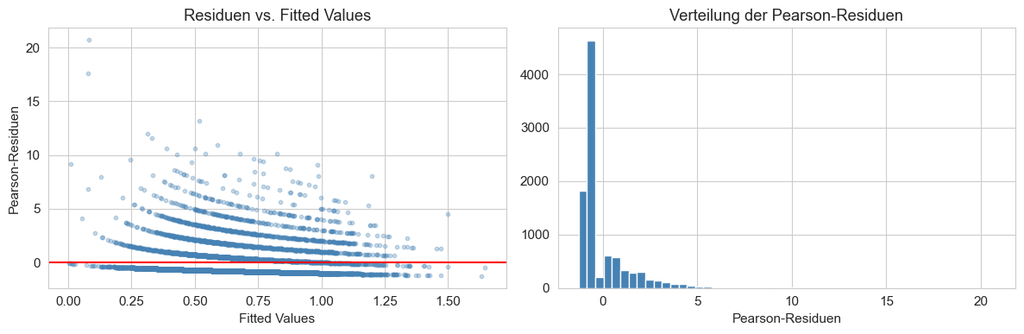

```python
# Residualanalyse
fitted = glm_result.fittedvalues
pearson_resid = glm_result.resid_pearson

fig, axes = plt.subplots(1, 2, figsize=(12, 4))

# Plot 1: Pearson-Residuen vs. Fitted Values
axes[0].scatter(fitted, pearson_resid, alpha=0.3, s=10, color='steelblue')
axes[0].axhline(0, color='red', lw=1.5)
axes[0].set_xlabel('Fitted Values')
axes[0].set_ylabel('Pearson-Residuen')
axes[0].set_title('Residuen vs. Fitted Values')

# Plot 2: Histogramm der Pearson-Residuen
axes[1].hist(pearson_resid, bins=50, color='steelblue', edgecolor='white')
axes[1].set_xlabel('Pearson-Residuen')
axes[1].set_title('Verteilung der Pearson-Residuen')

plt.tight_layout()
plt.show()
```

**Residualanalyse:** Die Fächerstruktur im Residualplot und die rechtsschiefe Verteilung der Pearson-Residuen bestätigen die Overdispersion (Pearson-Chi²/df ≈ 2,23). Die diskreten Bänder im linken Plot sind methodisch erwartet — sie resultieren aus der Zählnatur der Zielvariable N_claims_year. Ausreißer mit Pearson-Residuen >10 entsprechen Policen mit ungewöhnlich vielen Schäden, die das Poisson-Modell systematisch unterschätzt.

```python
# Overdispersion
pearson_chi2 = glm_result.pearson_chi2
df_resid = glm_result.df_resid
dispersion_ratio = pearson_chi2 / df_resid
print(f'Pearson-Chi² / df_resid = {pearson_chi2:.1f} / {df_resid:.0f} = {dispersion_ratio:.3f}')

# Signifikante vs. nicht-signifikante Features
summary_df = pd.DataFrame({
    'Feature'  : ['const'] + feat_cols,
    'Koeffizient': glm_result.params,
    'p-Wert'   : glm_result.pvalues
})
print('\nSignifikante Features (p < 0.05):')
print(summary_df[summary_df['p-Wert'] < 0.05].to_string(index=False))
print('\nNicht-signifikante Features (p >= 0.05):')
print(summary_df[summary_df['p-Wert'] >= 0.05].to_string(index=False))

# Stärkste Einflussfaktoren (nach absolutem Koeffizient)
summary_df['|Koeffizient|'] = summary_df['Koeffizient'].abs()
print('\nTop 5 Einflussfaktoren (nach |Koeffizient|):')
print(summary_df[summary_df['Feature'] != 'const']
      .sort_values('|Koeffizient|', ascending=False)
      .head(5).to_string(index=False))
```

```
Pearson-Chi² / df_resid = 21224.4 / 9506 = 2.233

Signifikante Features (p < 0.05):
        Feature  Koeffizient        p-Wert
          const    -0.488437 8.919431e-282
      Seniority    -0.181314  2.834546e-25
          Power     0.113255  9.623188e-05
        DrivAge     0.108240  3.740628e-05
 DrivLicenceAge    -0.129829  8.596218e-07
      N_doors_3    -0.090453  1.050210e-02
      N_doors_4    -0.080880  9.091816e-03
      N_doors_5    -0.107171  1.035605e-02
      Payment_1     0.200127  3.391953e-56
         Area_1     0.041500  1.190598e-03
Second_driver_1     0.032785  8.815626e-03
    Type_fuel_1    -0.099102  7.884570e-09

Nicht-signifikante Features (p >= 0.05):
               Feature  Koeffizient   p-Wert
     Cylinder_capacity    -0.031161 0.218260
         Value_vehicle    -0.049093 0.090814
                Weight     0.045422 0.058646
                VehAge     0.012897 0.438607
Distribution_channel_1     0.011520 0.393155

Top 5 Einflussfaktoren (nach |Koeffizient|):
       Feature  Koeffizient       p-Wert  |Koeffizient|
     Payment_1     0.200127 3.391953e-56       0.200127
     Seniority    -0.181314 2.834546e-25       0.181314
DrivLicenceAge    -0.129829 8.596218e-07       0.129829
         Power     0.113255 9.623188e-05       0.113255
       DrivAge     0.108240 3.740628e-05       0.108240
```

#### Modelldiagnostik GLM Poisson

**Overdispersion:** Das Verhältnis Pearson-Chi²/df ≈ 2,2 deutet auf Overdispersion hin — die Poisson-Annahme Var(Y) = µ ist verletzt. Als Konsequenz sind die Standardfehler der Koeffizienten zu klein geschätzt, was zu liberal-falschen Signifikanzaussagen führen kann. Die Punkt-Schätzungen der Frequenz bleiben aber unverzerrt — für die Tarifierung als solche ist Overdispersion damit unkritisch. Ein Quasi-Poisson- oder Negative-Binomial-Modell wäre nur für korrekte Konfidenzintervalle nötig.

**Stärkste Einflussfaktoren:**

Insgesamt dominieren Payment_1 (β = +0,200) und Seniority (β = -0,181) die Top-5-Liste.

- **Stärkstes kategoriales Feature:** Payment_1 — halbjährliche Zahler weisen eine deutlich höhere Schadenfrequenz auf als jährliche Zahler (vgl. Plausibilitätsprüfung unten).
- **Stärkstes numerisches Feature:** Seniority — längere Vertragsdauer reduziert die Schadenfrequenz, vermutlich getrieben durch Survivorship Bias (vgl. Diskussion in B1 a).

**Trade-off Komplexität/Modellgüte:** Das GLM reduziert die Validierungsdevianz gegenüber dem Intercept-Modell von 171,52 auf 163,75 — eine Verbesserung von ca. 4,5 % bei 16 zusätzlichen Parametern. Pro Parameter ist der Devianzgewinn gering, aber das Modell ist vollständig interpretierbar und regulatorisch akzeptiert. Die begrenzte Flexibilität durch die Linearitätsannahme wird in B2 durch Ensemble-Methoden adressiert.

**Plausibilitätsprüfung: Payment**

Da Payment den größten absoluten Koeffizient aufweist, prüfen wir ob dies ein echter Effekt oder ein Datenfehler ist. Dazu vergleichen wir die beobachtete Schadenfrequenz je Zahlungsweise direkt im Datensatz.

```python
# Schadenhäufigkeit nach Zahlungsweise
print(
    df.groupby('Payment').apply(
        lambda x: pd.Series({
            'Anzahl': len(x),
            'Schäden_sum': x['N_claims_year'].sum(),
            'Exposure_sum': x['Exposure'].sum(),
            'Schadenfrequenz': x['N_claims_year'].sum() / x['Exposure'].sum()
        })
    ).round(4)
)

# Korrelation mit anderen Features
print("\nPayment-Korrelationen:")
print(df[var_num + ['Payment']].corr()['Payment'].sort_values())
```

```
          Anzahl  Schäden_sum  Exposure_sum  Schadenfrequenz
Payment
0        10380.0       5504.0    10316.5339           0.5335
1         5493.0       4637.0     5199.0116           0.8919

Payment-Korrelationen:
Seniority           -0.219362
DrivLicenceAge      -0.172807
DrivAge             -0.144787
VehAge              -0.014502
Value_vehicle        0.030532
Cylinder_capacity    0.042269
Power                0.048123
Weight               0.052691
Payment              1.000000
Name: Payment, dtype: float64
```

**Befund:** Der Effekt ist real — halbjährliche Zahler (Payment=1) haben mit 0,89 eine deutlich höhere Schadenfrequenz als jährliche Zahler (Payment=0) mit 0,53 (~67% Unterschied). Die moderaten Korrelationen mit Seniority (-0,22), DrivLicenceAge (-0,17) und DrivAge (-0,14) deuten darauf hin, dass halbjährliche Zahler tendenziell jünger und unerfahrener sind — reichen aber nicht aus um Multikollinearität zu begründen. Zudem könnte Payment als Proxy für finanzielle Situation oder Risikobereitschaft der versicherten Person stehen.

**Entscheidung: Payment wird beibehalten.**

### B1 e) LASSO – Elastisches Netz mit Poisson-Likelihood

**Warum Standardisierung?** Bei LASSO-Regularisierung wird jeder Koeffizient mit demselben Strafterm $\alpha$ bestraft. Ohne Standardisierung würden Features mit großer Skala (z. B. `Value_vehicle` in Tausenden) stärker penalisiert als Features mit kleiner Skala. Die Koeffizienten wären nicht vergleichbar.

**Grid-Search über:**

- **alpha** — Regularisierungsstärke: Je größer, desto mehr Koeffizienten werden gegen null gedrückt. Die Suche erfolgt auf einer **logarithmischen Skala** {0,0001, 0,001, 0,01, 0,1, 1,0, 10,0}, da Regularisierungsparameter typischerweise über mehrere Größenordnungen variieren und eine lineare Skala kleine Werte unterrepräsentieren würde (Pedregosa et al., 2011 — scikit-learn: Machine Learning in Python, JMLR 12).
- **L1_wt** — Gewichtung zwischen LASSO (L1_wt=1,0) und Ridge (L2, L1_wt=0,0). Werte dazwischen entsprechen Elastic Net. Range: [0,0, 1,0] inklusive Randwerte, damit reines LASSO und reines Ridge als Vergleichsanker im Grid enthalten sind.

**Hinweis zur Methodik:** Wegen der Aufgabenstellugn wurde bewusst eine klassische Grid-Search gewählt. Auf ein Gradient-Verfahren oder auf die Bibliothek Optuna wurde verzichtet, da die Aufgabe explizit Grid-Search vorgibt. Die besten Hyperparameter werden anhand der Poisson-Devianz auf dem Validierungsdatensatz bestimmt.

```python
# Standardisierung (nur auf numerische + OHE-Features, keine Konstante)
scaler = StandardScaler()
X_lasso_train = scaler.fit_transform(X_train)
X_lasso_val   = scaler.transform(X_val)
X_lasso_test  = scaler.transform(X_test)

X_lasso_train_c = sm.add_constant(X_lasso_train)
X_lasso_val_c   = sm.add_constant(X_lasso_val)
X_lasso_test_c  = sm.add_constant(X_lasso_test)

# Grid für die Suche
alphas = [0.0001, 0.001, 0.01, 0.1, 1.0, 10.0]  # logarithmische Skala
l1_wts = [0.0, 0.25, 0.5, 0.75, 1.0]

grid_rows = []
print('Grid-Search läuft...')
t0_grid = time.time()

for alpha, l1 in iproduct(alphas, l1_wts):
    try:
        m = sm.GLM(y_train, X_lasso_train_c,
                   family=sm.families.Poisson(link=sm.families.links.Log()),
                   offset=np.log(exp_train))
        r = m.fit_regularized(method='elastic_net', alpha=alpha, L1_wt=l1,
                               maxiter=200)
        mu_v = r.predict(X_lasso_val_c, offset=np.log(exp_val))
        dev_v = poisson_deviance(y_val, mu_v, ex=exp_val)
    except Exception:
        dev_v = np.inf
    grid_rows.append({'alpha': alpha, 'L1_wt': l1, 'val_devianz': round(dev_v, 6)})

elapsed_lasso_tuning = time.time() - t0_grid
print(f'Grid-Search abgeschlossen in {elapsed_lasso_tuning:.1f} s\n')

grid_df = pd.DataFrame(grid_rows).sort_values('val_devianz')
print('Top 10 Kombinationen (sortiert nach Val-Devianz):')
print(grid_df.head(10).to_string(index=False))
```

```
Grid-Search läuft...
Grid-Search abgeschlossen in 30.8 s

Top 10 Kombinationen (sortiert nach Val-Devianz):
 alpha  L1_wt  val_devianz
0.0100   0.25   163.493565
0.0100   0.50   163.544626
0.0010   1.00   163.586836
0.0100   0.00   163.633797
0.0010   0.75   163.635491
0.0010   0.50   163.666838
0.0100   0.75   163.679485
0.0010   0.25   163.699446
0.0010   0.00   163.733478
0.0001   1.00   163.733552
```

```python
best = grid_df.iloc[0]
best_alpha = best['alpha']
best_l1    = best['L1_wt']
print(f'Optimale Parameter: alpha={best_alpha}, L1_wt={best_l1}  '
      f'→ Val Deviance={best["val_devianz"]:.6f}')

# Finales LASSO-Modell
t0 = time.time()
lasso_base = sm.GLM(y_train, X_lasso_train_c,
                    family=sm.families.Poisson(link=sm.families.links.Log()),
                    offset=np.log(exp_train))
lasso_res = lasso_base.fit_regularized(method='elastic_net',
                                        alpha=best_alpha, L1_wt=best_l1,
                                        maxiter=300)
elapsed_lasso = time.time() - t0

mu_train_lasso = lasso_res.predict(X_lasso_train_c, offset=np.log(exp_train))
mu_val_lasso   = lasso_res.predict(X_lasso_val_c,   offset=np.log(exp_val))
mu_test_lasso  = lasso_res.predict(X_lasso_test_c,  offset=np.log(exp_test))

d_train_lasso = poisson_deviance(y_train, mu_train_lasso, ex=exp_train)
d_val_lasso   = poisson_deviance(y_val,   mu_val_lasso, ex=exp_val)
print(f'Poisson-Devianz  Train: {d_train_lasso:.6f}   Val: {d_val_lasso:.6f}')
add_result('LASSO (Poisson, EN)', d_train_lasso, d_val_lasso,
           elapsed=elapsed_lasso, tuning_time=elapsed_lasso_tuning)

# Koeffizienten + Sparsity
params = pd.Series(lasso_res.params,
                   index=['const'] + feat_cols)
zero_feats  = params[np.abs(params) < 1e-8]
nonzero_feats = params[np.abs(params) >= 1e-8]
print(f'\nNicht-null Koeffizienten: {len(nonzero_feats)} / {len(params)}')
print(f'Auf Null regularisiert:    {len(zero_feats)}')
print('\nFeatures mit Koeffizient = 0:')
print(list(zero_feats.index))

print('\nAlle Koeffizienten (sortiert nach absolutem Wert):')
print(params.reindex(params.abs().sort_values(ascending=False).index).to_string())
```

```
Optimale Parameter: alpha=0.01, L1_wt=0.25  → Val Deviance=163.493565
Poisson-Devianz  Train: 160.998115   Val: 163.493565

Nicht-null Koeffizienten: 14 / 17
Auf Null regularisiert:    3

Features mit Koeffizient = 0:
['Cylinder_capacity', 'Value_vehicle', 'N_doors_5']

Alle Koeffizienten (sortiert nach absolutem Wert):
const                    -0.472696
Payment_1                 0.197127
Seniority                -0.172866
DrivLicenceAge           -0.091943
Type_fuel_1              -0.075943
DrivAge                   0.068593
Power                     0.065608
Area_1                    0.037280
Second_driver_1           0.028431
Weight                    0.020955
Distribution_channel_1    0.011406
N_doors_3                -0.002827
N_doors_4                -0.002576
VehAge                    0.001993
Value_vehicle             0.000000
Cylinder_capacity         0.000000
N_doors_5                 0.000000
```

**Anmerkung zum Modelltyp:** Das beste Modell verwendet L1_wt=0,25 — überwiegend Ridge mit nur 25 % LASSO-Anteil. Streng genommen handelt es sich also um ein Elastic Net, nicht um reines LASSO. Der LASSO-Spezialfall (L1_wt=1,0) wird nur knapp geschlagen (Val-Devianz 163,587 vs. 163,494) — die finale Wahl zwischen beiden wäre praxisnah eine Frage des Stabilitäts-Trade-offs.

**Vergleich GLM vs. Elastic Net:** Das regularisierte Modell ist auf Train marginal schlechter (~0,1) und auf Val marginal besser (~0,2) — das erwartete Verhalten leichter Regularisierung: Geringfügig höherer Bias auf Trainingsdaten, leicht bessere Generalisierung.

**Sparsity-Interpretation:** Drei von 17 Features werden auf exakt null regularisiert:

- **Cylinder_capacity** — könnte vermutlich stark mit Power korrelieren was uns auch die Korrelationsanalyse in A1 d bestätigt. Das Elastic Net wählt das informativere Feature (Power) und verwirft Cylinder_capacity.
- **Value_vehicle** — bereits im GLM nicht signifikant (p = 0,09). Trägt nach Kontrolle anderer Features kaum zusätzliche Information.
- **N_doors_5** — die häufigste Kategorie (5-Türer). 5-Türer unterscheiden sich nach Kontrolle der anderen Features statistisch nicht signifikant von der Referenzkategorie 2-Türer..

### B1 f) Künstliches Neuronales Netz (PyTorch)

**Framework: PyTorch.** Wegen flexibler imperativer Modelldefinition, einfacher Loss-Anpassung (Custom Poisson NLL inkl. Exposure) und ausgereiftem Autograd.

**Architektur:** Input → Hidden Layer (10 Neuronen, ReLU, Dropout 20 %) → Output (1 Neuron, Softplus).

- **Anzahl/Größe Hidden Layers:** Ein einzelner schmaler Layer mit 10 Neuronen. Bei 16 Features und ~9.500 Trainingsbeobachtungen ist ein tiefes Netz nicht erforderlich. Ein einzelner Hidden Layer reicht für moderate nicht-lineare Zusammenhänge und reduziert das Overfitting-Risiko.
- **Aktivierungsfunktion (Hidden):** ReLU. Vermeidet Vanishing-Gradient-Probleme, schnell zu berechnen, etablierter Standard für flache und tiefe Netze.
- **Dropout 0,2:** Niedrig gewählt, da der Hidden Layer nur 10 Neuronen hat — ein höherer Wert würde zu viel Modellkapazität aushebeln.
- **Batch Normalization:** Bewusst nicht verwendet. Bei nur einem Hidden Layer mit 10 Neuronen sind interne Kovariatenverschiebungen vernachlässigbar; BN würde hier kaum Mehrwert bringen, aber zusätzliche Parameter und Trainingskomplexität verursachen.
- **Output-Aktivierung Softplus** (`log(1 + exp(x))`): Garantiert strikt positive Vorhersagen — Schadenfrequenzen müssen ≥ 0 sein. Vorteil gegenüber `exp()`: Sanftere Gradienten bei großen Eingabewerten und damit stabileres Training. Vorteil gegenüber ReLU: überall differenzierbar (kein Knick bei 0).

**Loss:** Poisson NLL = `mean(μ − y · log(μ))`, mit `μ = ŷ · Exposure`. Die Exposure wird also direkt als Multiplikator in den Loss integriert — das Netz schätzt die Schadenrate `λ̂`, nicht die absolute Schadenanzahl.

**Trainingsstrategie:**

- Optimizer: **Adam** (lr=0,001) — robust, erfordert wenig Tuning.
- LR-Scheduling: **ReduceLROnPlateau** (factor=0,5, patience=5) — halbiert die Lernrate, wenn die Validation-Loss 5 Epochen nicht besser wird; ermöglicht feinere Konvergenz in späten Epochen.
- Batch Size: **512** — bietet einen guten Kompromiss zwischen Gradient-Stabilität und Trainingsgeschwindigkeit.
- Maximale Epochen: **150**, mit **Early Stopping** (Patience 15) auf der Validation-Loss zur Vermeidung von Overfitting.

**Aufbereitung kategorialer Features für neuronale Netze:** Es gibt zwei etablierte Verfahren:

- **One-Hot-Encoding (OHE):** Jede Kategorie wird als binärer Indikator kodiert. Vorteil: Einfach, transparent, identisch zu GLM/LASSO. Nachteil: Bei vielen Kategorien explodiert die Eingabedimension; die Kodierung ist orthogonal — semantische Ähnlichkeiten zwischen Kategorien gehen verloren.
- **Entity Embeddings** (Guo & Berkhahn, 2016): Jede Kategorie wird auf einen niedrigdimensionalen, lernbaren Vektor abgebildet (analog zu Word Embeddings im NLP). Das Netz lernt während des Trainings semantische Nähe zwischen Kategorien (z. B. ähnliche Risikoprofile). Vorteil: Kompakter als OHE bei vielen Kategorien, kann Strukturen aufdecken. Nachteil: Zusätzliche Hyperparameter (Embedding-Dimension), schwerer interpretierbar.

**Wahl hier: OHE.** Die kategorialen Features besitzen maximal vier Ausprägungen — Embeddings würden hier weder die Dimension reduzieren noch nennenswerte semantische Strukturen aufdecken. OHE ist konsistent zur Vorverarbeitung in B1 d) und e)

```python
class FreqNet(nn.Module):
    def __init__(self, n_feat):
        super().__init__()
        self.net = nn.Sequential(
nn.Linear(n_feat, 10), nn.ReLU(), nn.Dropout(0.2),
nn.Linear(10, 1), nn.Softplus()
        )
    def forward(self, x):
        return self.net(x).squeeze(-1)

def poisson_nll_loss(y_pred, y_true, exposure):
    """Poisson NLL: mean(mu - y*log(mu)),  mu = y_pred * exposure"""
    mu  = y_pred * exposure
    nll = mu - y_true * torch.log(mu + 1e-10)
    return nll.mean()


def train_freq_net(X_tr, X_va, X_te, y_tr, y_va, exp_tr, exp_va, exp_te,
                   label='NN'):
    """
    Trainiert ein FreqNet und gibt Vorhersagen + Devianz zurück.
    label: Name für die Ergebnistabelle und den Plot
    """
    # Standardisierung
    scaler = StandardScaler()
    Xt = torch.FloatTensor(scaler.fit_transform(X_tr))
    Xv = torch.FloatTensor(scaler.transform(X_va))
    Xs = torch.FloatTensor(scaler.transform(X_te))

    yt = torch.FloatTensor(y_tr)
    yv = torch.FloatTensor(y_va)
    et = torch.FloatTensor(exp_tr)
    ev = torch.FloatTensor(exp_va)

    # Modell
    n_feat = X_tr.shape[1]
    model  = FreqNet(n_feat)
    optimizer = torch.optim.Adam(model.parameters(), lr=0.001)
    scheduler = torch.optim.lr_scheduler.ReduceLROnPlateau(
                    optimizer, patience=5, factor=0.5)

    # DataLoader
    dl = DataLoader(TensorDataset(Xt, yt, et), batch_size=512, shuffle=True)

    # Training
    best_val_loss = np.inf
    best_state    = None
    patience_cnt  = 0
    PATIENCE      = 15
    history       = {'train': [], 'val': []}
    t0            = time.time()

    model.train()
    for epoch in range(1, 151):
        epoch_loss = 0.0
        for xb, yb, eb in dl:
            optimizer.zero_grad()
            loss = poisson_nll_loss(model(xb), yb, eb)
            loss.backward()
            optimizer.step()
            epoch_loss += loss.item() * len(yb)
        epoch_loss /= len(yt)

        model.eval()
        with torch.no_grad():
            val_loss = poisson_nll_loss(model(Xv), yv, ev).item()
        model.train()

        history['train'].append(epoch_loss)
        history['val'].append(val_loss)
        scheduler.step(val_loss)

        if val_loss < best_val_loss:
            best_val_loss = val_loss
            best_state    = {k: v.clone() for k, v in model.state_dict().items()}
            patience_cnt  = 0
        else:
            patience_cnt += 1
            if patience_cnt >= PATIENCE:
                print(f'{label}: Early Stopping in Epoche {epoch}')
                break

        if epoch % 10 == 0:
            print(f'{label} Epoch {epoch:3d} | Train: {epoch_loss:.6f} '
                  f'| Val: {val_loss:.6f}')

    elapsed = time.time() - t0
    model.load_state_dict(best_state)

    # Loss-Kurven
    fig, ax = plt.subplots(figsize=(9, 4))
    ax.plot(history['train'], label='Train NLL')
    ax.plot(history['val'],   label='Validation NLL')
    ax.set_xlabel('Epoche')
    ax.set_ylabel('Poisson NLL')
    ax.set_title(f'Trainingsverlauf – {label}')
    ax.legend()
    plt.tight_layout()
    plt.show()

    # Devianz
    model.eval()
    with torch.no_grad():
        mu_tr = (model(Xt) * et).numpy()
        mu_va = (model(Xv) * ev).numpy()
        mu_te = (model(Xs) * torch.FloatTensor(exp_te)).numpy()

    d_tr = poisson_deviance(y_tr, mu_tr, ex=exp_tr)
    d_va = poisson_deviance(y_va, mu_va, ex=exp_va)
    print(f'{label} | Train: {d_tr:.6f} | Val: {d_va:.6f} | Zeit: {elapsed:.1f}s')
    add_result(label, d_tr, d_va, elapsed=elapsed)
    return model, scaler, mu_tr, mu_va, mu_te
```

```
NN (alle Features) Epoch  10 | Train: 0.900618 | Val: 0.901095
NN (alle Features) Epoch  20 | Train: 0.894101 | Val: 0.896661
NN (alle Features) Epoch  30 | Train: 0.889222 | Val: 0.895471
NN (alle Features) Epoch  40 | Train: 0.884904 | Val: 0.896067
NN (alle Features): Early Stopping in Epoche 48
```

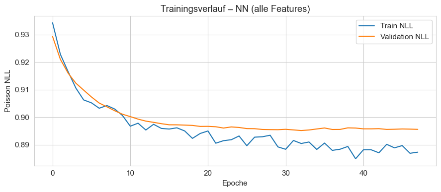

```
NN (alle Features) | Train: 160.582954 | Val: 163.674494 | Zeit: 3.5s
```

```python
# Volles Feature-Set
model_nn_full, scaler_nn_full, mu_tr_full, mu_va_full, mu_te_full = train_freq_net(
    X_train, X_val, X_test,
    y_train, y_val,
    exp_train, exp_val, exp_test,
    label='NN (alle Features)'
)
```

**Hinweis:** Der ausgewiesene NLL-Loss beim Training (~0,89) liegt auf einer anderen Skala als die Poisson-Devianz (~163). Unsere Funktion `poisson_deviance()` arbeitet auf NumPy-Arrays und liefert keinen Gradienten — sie ist daher für die Trainingsschleife nicht direkt nutzbar. Beide Loss-Funktionen besitzen aber dasselbe Optimum, das Trainings-Verhalten ist äquivalent.

```python
class NNWrapper(BaseEstimator, RegressorMixin):
    def __init__(self, model, scaler, exposure):
        self.model    = model
        self.scaler   = scaler
        self.exposure = exposure

    def fit(self, X, y): return self

    def predict(self, X):
        self.model.eval()
        with torch.no_grad():
            X_t = torch.FloatTensor(self.scaler.transform(X))
            return (self.model(X_t) * torch.FloatTensor(self.exposure)).numpy()
```

```python
# Volles Modell — Permutation Importance
result_full = permutation_importance(
    NNWrapper(model_nn_full, scaler_nn_full, exp_val),
    X_val, y_val, n_repeats=10, random_state=SEED,
    scoring='neg_mean_squared_error'
)

# Sortierung absteigend (wichtigstes Feature zuerst).
# Werte nahe null oder negativ → Rauschen / irrelevant.
imp = pd.Series(result_full.importances_mean,
                index=feat_cols).sort_values(ascending=False)
print('Permutation Importance (volles Modell):')
print(imp.to_string())

# Schwellwert für reduziertes Modell: Nur Features mit klar positivem
# Importance-Beitrag werden übernommen.
THRESHOLD = 0.0015
feat_cols_nn_red = imp[imp > THRESHOLD].index.tolist()
print(f'\nFeatures über Schwellwert {THRESHOLD}: {len(feat_cols_nn_red)}')
print(feat_cols_nn_red)
```

```
Permutation Importance (volles Modell):
Payment_1                 0.038022
DrivLicenceAge            0.014135
Seniority                 0.013005
N_doors_3                 0.003252
Type_fuel_1               0.002555
Cylinder_capacity         0.001962
Area_1                    0.001907
Distribution_channel_1    0.001261
VehAge                    0.001160
Weight                    0.000724
Second_driver_1           0.000538
N_doors_4                 0.000260
N_doors_5                -0.000814
DrivAge                  -0.001317
Value_vehicle            -0.001649
Power                    -0.001745

Features über Schwellwert 0.0015: 7
['Payment_1', 'DrivLicenceAge', 'Seniority', 'N_doors_3', 'Type_fuel_1', 'Cylinder_capacity', 'Area_1']
```

```
NN (reduziert) Epoch  10 | Train: 0.900861 | Val: 0.905793
NN (reduziert) Epoch  20 | Train: 0.894226 | Val: 0.900175
NN (reduziert) Epoch  30 | Train: 0.893631 | Val: 0.898403
NN (reduziert) Epoch  40 | Train: 0.893397 | Val: 0.897233
NN (reduziert) Epoch  50 | Train: 0.890752 | Val: 0.896541
NN (reduziert) Epoch  60 | Train: 0.891549 | Val: 0.895373
NN (reduziert) Epoch  70 | Train: 0.889553 | Val: 0.895457
NN (reduziert): Early Stopping in Epoche 75
```

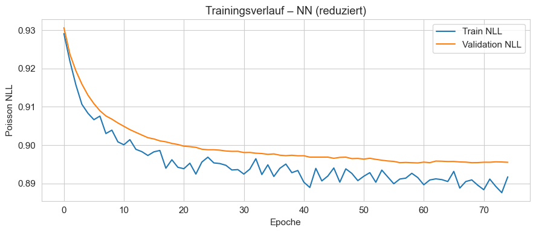

```
NN (reduziert) | Train: 160.843724 | Val: 163.702728 | Zeit: 5.4s
```

```python
# Reduziertes Feature-Set
model_nn_red, scaler_nn_red, mu_tr_red, mu_va_red, mu_te_red = train_freq_net(
    X_train[feat_cols_nn_red], X_val[feat_cols_nn_red], X_test[feat_cols_nn_red],
    y_train, y_val,
    exp_train, exp_val, exp_test,
    label='NN (reduziert)'
)
```

#### Interpretation Trainingsverlauf:

Das reduzierte NN erzielt eine geringfügig kleinere Train/Val-Lücke, aber auch eine leicht schlechtere Train-Devianz. Die validation-Devianz unterscheidet sich praktisch nicht. Die längere Trainingszeit ist zufallsbedingt (Early Stopping greift bei beiden früh).

Für die weiteren Auswertungen wird das reduzierte Modell verwendet — weniger Features bedeuten weniger operativen Aufwand bei vergleichbarer Vorhersagegüte.

```python
# Reduziertes Modell
result_red = permutation_importance(
    NNWrapper(model_nn_red, scaler_nn_red, exp_val),
    X_val[feat_cols_nn_red], y_val, n_repeats=10, random_state=SEED,
    scoring='neg_mean_squared_error'
)

imp = pd.Series(result_red.importances_mean, index=feat_cols_nn_red).sort_values(ascending=False)
print(imp.to_string())
```

```
Payment_1            0.038820
Seniority            0.021145
Cylinder_capacity    0.005972
DrivLicenceAge       0.004757
Area_1               0.002040
Type_fuel_1          0.000157
N_doors_3           -0.001485
```

**Weitere Optimierungsmöglichkeiten:** Für das reduzierte NN könnten neue Hyperparameter sinnvoll sein z. B. ein tieferes aber dafür schmaleres Netz, oder eine weitere Reduktion auf 5 Features durch Entfernen von `N_doors_3` (negative Importance) und `Type_fuel_1` (nahe null). Das wird hier aus Zeitgründen nicht weiter untersucht.

## Aufgabe B2: Ensemble-Modelle für die Schadenhäufigkeit

### B 2a) Bagging und Random Forest

**Bagging (Bootstrap Aggregation):** Trainiert $B$ Entscheidungsbäume auf Bootstrap-Stichproben und mittelt die Vorhersagen. Bei jedem Split stehen *alle* Features zur Verfügung.

**Random Forest:** Wie Bagging, aber zusätzlich wird bei jedem Split nur eine zufällige Teilmenge der Features ($\approx\sqrt{p}$) betrachtet. Dadurch werden die Bäume weniger korreliert → Varianzreduktion.

**Gemeinsamkeiten:** Beide kombinieren viele schwache Lerner; Overfitting-Robustheit durch Mittelung.

**Unterschied:** Random Forest erzeugt durch Feature-Subsampling diversere Bäume.

**Vorteil bei hochdimensionalen Daten:** Durch Mittelung wird die Varianz reduziert, ohne den Bias wesentlich zu erhöhen.

Wir verwenden `criterion='poisson'` (scikit-learn ≥ 0,24) und modellieren die Häufigkeit direkt ($y/E$ als Ziel, Exposure als Gewicht).

```python
# Häufigkeit als Ziel (y / Exposure) mit Exposure als Gewicht
freq_train = y_train / np.maximum(exp_train, 1e-10)
freq_val   = y_val   / np.maximum(exp_val,   1e-10)

# Bagging (alle Features)
t0 = time.time()
bagging = BaggingRegressor(
    estimator=DecisionTreeRegressor(
        criterion='poisson',   # Poisson-Devianz als Split-Kriterium → konsistent mit Zählnatur
        max_depth=5,           # Maximale Baumtiefe → begrenzt Komplexität, reduziert Overfitting
        min_samples_leaf=80   # Mindestanzahl Beobachtungen pro Blatt → stabile Tarifzellen
    ),
    n_estimators=400,          # Anzahl Bäume → stabilisiert die Varianz
    random_state=SEED,           # Reproduzierbarkeit
    n_jobs=-1                  # alle CPU-Kerne nutzen
)
bagging.fit(X_train, freq_train, sample_weight=exp_train)
elapsed_bag = time.time() - t0

mu_train_bag = bagging.predict(X_train) * exp_train
mu_val_bag   = bagging.predict(X_val)   * exp_val
mu_test_bag  = bagging.predict(X_test)  * exp_test

d_train_bag = poisson_deviance(y_train, mu_train_bag, ex=exp_train)
d_val_bag   = poisson_deviance(y_val,   mu_val_bag, ex=exp_val)
print(f'Bagging  Train: {d_train_bag:.6f}  Val: {d_val_bag:.6f}  Zeit: {elapsed_bag:.1f} s')
add_result('Bagging', d_train_bag, d_val_bag, elapsed=elapsed_bag)
```

```
Bagging  Train: 155.669876  Val: 164.175834  Zeit: 2.6 s
```

```python
# Random Forest (alle Features)
t0 = time.time()
rf = RandomForestRegressor(
    n_estimators=200,          # Mehr Diversität durch Feature-Subsampling
    criterion='poisson',       # Poisson-Devianz als Split-Kriterium
    max_features='sqrt',       # √p Features je Split → dekorrelierte Bäume
    max_depth=8,               # Maximale Baumtiefe
    min_samples_leaf=50,      # Mindestanzahl Beobachtungen pro Blatt
    random_state=SEED,
    n_jobs=-1
)
rf.fit(X_train, freq_train, sample_weight=exp_train)
elapsed_rf = time.time() - t0

mu_train_rf = rf.predict(X_train) * exp_train
mu_val_rf   = rf.predict(X_val)   * exp_val
mu_test_rf  = rf.predict(X_test)  * exp_test

d_train_rf = poisson_deviance(y_train, mu_train_rf, ex=exp_train)
d_val_rf   = poisson_deviance(y_val,   mu_val_rf, ex=exp_val)
print(f'Random Forest  Train: {d_train_rf:.6f}  Val: {d_val_rf:.6f}  Zeit: {elapsed_rf:.1f} s')
add_result('Random Forest', d_train_rf, d_val_rf, elapsed=elapsed_rf)
```

```
Random Forest  Train: 151.951967  Val: 163.832789  Zeit: 0.2 s
```

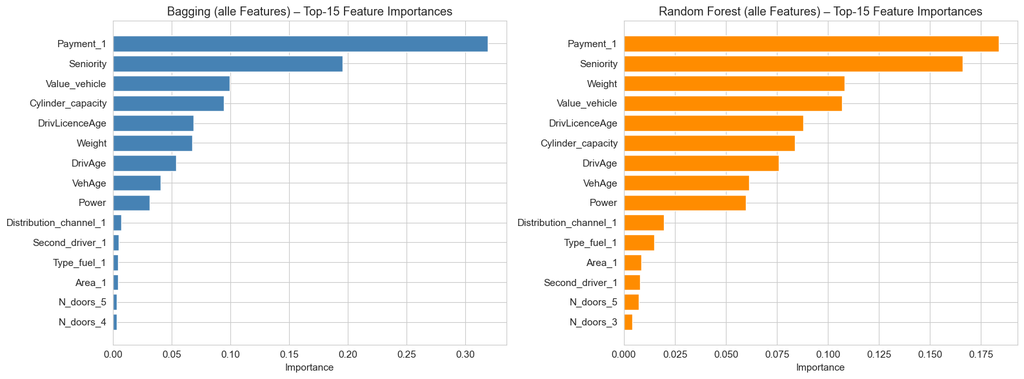

```python
# Feature Importance → wird für reduziertes Modell benötigt

imp_bag = np.mean([e.feature_importances_ for e in bagging.estimators_], axis=0) # Bagging
imp_rf = rf.feature_importances_ # Random Forest

fig, axes = plt.subplots(1, 2, figsize=(16, 6))

for ax, imp, cols, name, color in [
    (axes[0], imp_bag, feat_cols, 'Bagging (alle Features)',        'steelblue'),
    (axes[1], imp_rf,  feat_cols, 'Random Forest (alle Features)',  'darkorange')
]:
    imp_s = pd.Series(imp, index=cols).sort_values(ascending=False)
    top   = min(15, len(imp_s))
    ax.barh(imp_s.index[:top][::-1], imp_s.values[:top][::-1], color=color)
    ax.set_title(f'{name} – Top-{top} Feature Importances')
    ax.set_xlabel('Importance')

plt.tight_layout()
plt.show()
```

**Befund:** Beide Modelle setzen Payment_1 und Seniority an die Spitze — konsistent zu GLM und LASSO. Eine kleine Abweichung: Random Forest gewichtet Weight höher als Bagging (Rang 3 vs. Rang 6), während Bagging Cylinder_capacity stärker betont. Die drei Features Power / Weight / Cylinder_capacity sind physikalisch korreliert; Bagging ohne Feature-Subsampling tendiert dazu, immer dasselbe dieser korrelierten Features zu wählen, während RF durch das Subsampling jedem abwechselnd die Chance gibt — wodurch sich die Wichtigkeit gleichmäßiger verteilt.

#### Neubetrachtung mit reduzierten Featureanzahl

```python
#Zu reduzierende Spalten ermitteln und entfernen

imp_rf_series = pd.Series(imp_rf, index=feat_cols).sort_values(ascending=False)
imp_bag_series = pd.Series(imp_bag, index=feat_cols).sort_values(ascending=False)

feat_cols_bag_red = [f for f in feat_cols
                     if imp_bag_series[f] > 0.02
                     and not f.startswith('N_doors')]
feat_cols_rf_red = [f for f in feat_cols
                    if imp_rf_series[f] > 0.02
                    and not f.startswith('N_doors')]
print(f'Reduzierte Features Bagging ({len(feat_cols_bag_red)}): {feat_cols_bag_red}')
print(f'Reduzierte Features RF ({len(feat_cols_rf_red)}): {feat_cols_rf_red}')
```

```
Reduzierte Features Bagging (9): ['Seniority', 'Power', 'Cylinder_capacity', 'Value_vehicle', 'Weight', 'DrivAge', 'DrivLicenceAge', 'VehAge', 'Payment_1']
Reduzierte Features RF (9): ['Seniority', 'Power', 'Cylinder_capacity', 'Value_vehicle', 'Weight', 'DrivAge', 'DrivLicenceAge', 'VehAge', 'Payment_1']
```

```python
# Bagging (reduziert) - angepasste Hyperparameter
t0 = time.time()
bagging_red = BaggingRegressor(
    estimator=DecisionTreeRegressor(
        criterion='poisson',
        max_depth=5,
        min_samples_leaf=40   # Etwas kleiner → mehr Flexibilität
    ),
    n_estimators=300,
    random_state=SEED,
    n_jobs=-1
)
bagging_red.fit(X_train[feat_cols_bag_red], freq_train, sample_weight=exp_train)
elapsed_bag_red = time.time() - t0

mu_train_bag_red = bagging_red.predict(X_train[feat_cols_bag_red]) * exp_train
mu_val_bag_red   = bagging_red.predict(X_val[feat_cols_bag_red])   * exp_val
mu_test_bag_red  = bagging_red.predict(X_test[feat_cols_bag_red])  * exp_test

d_train_bag_red = poisson_deviance(y_train, mu_train_bag_red, ex=exp_train)
d_val_bag_red   = poisson_deviance(y_val,   mu_val_bag_red, ex=exp_val)
print(f'Bagging (reduziert)  Train: {d_train_bag_red:.6f}  Val: {d_val_bag_red:.6f}  '
      f'Zeit: {elapsed_bag_red:.1f} s')
add_result('Bagging (reduziert)', d_train_bag_red, d_val_bag_red, elapsed=elapsed_bag_red)


# Random Forest (reduziert) - angepasste Hyperparameter
t0 = time.time()
rf_red = RandomForestRegressor(
    n_estimators=200,
    criterion='poisson',
    max_features='sqrt',
    max_depth=10,              # Tiefer als volles Modell
    min_samples_leaf=125,
    random_state=SEED,
    n_jobs=-1
)
rf_red.fit(X_train[feat_cols_rf_red], freq_train, sample_weight=exp_train)
elapsed_rf_red = time.time() - t0

mu_train_rf_red = rf_red.predict(X_train[feat_cols_rf_red]) * exp_train
mu_val_rf_red   = rf_red.predict(X_val[feat_cols_rf_red])   * exp_val
mu_test_rf_red  = rf_red.predict(X_test[feat_cols_rf_red])  * exp_test

d_train_rf_red = poisson_deviance(y_train, mu_train_rf_red)
d_val_rf_red   = poisson_deviance(y_val,   mu_val_rf_red)
print(f'Random Forest (reduziert)  Train: {d_train_rf_red:.6f}  Val: {d_val_rf_red:.6f}  '
      f'Zeit: {elapsed_rf_red:.1f} s')
add_result('Random Forest (reduziert)', d_train_rf_red, d_val_rf_red, elapsed=elapsed_rf_red)
```

```
Bagging (reduziert)  Train: 155.018566  Val: 164.360215  Zeit: 0.3 s
Random Forest (reduziert)  Train: 155.546028  Val: 162.908408  Zeit: 0.2 s
```

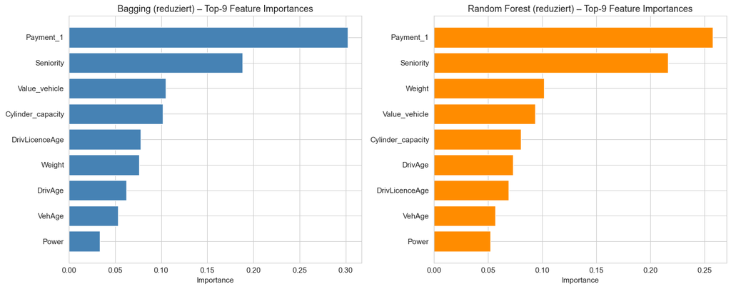

```python
fig, axes = plt.subplots(1, 2, figsize=(15, 6))

imp_bag_red = np.mean([e.feature_importances_ for e in bagging_red.estimators_], axis=0)
imp_rf_red  = rf_red.feature_importances_

for ax, imp, cols, name, color in [
    (axes[0], imp_bag_red, feat_cols_bag_red, 'Bagging (reduziert)',       'steelblue'),
    (axes[1], imp_rf_red,  feat_cols_rf_red,  'Random Forest (reduziert)', 'darkorange')
]:
    imp_s = pd.Series(imp, index=cols).sort_values(ascending=False)
    top   = min(15, len(imp_s))
    ax.barh(imp_s.index[:top][::-1], imp_s.values[:top][::-1], color=color)
    ax.set_title(f'{name} – Top-{top} Feature Importances')
    ax.set_xlabel('Importance')

plt.tight_layout()
plt.show()
```

```python
print_results()
```

```
                   Modell  Train Devianz  Val Devianz  Test Devianz  Train-Test-Gap  A/E Ratio  Zeit (s) Tuning Zeit (s)
  Basismodell (Intercept)     168.629990   171.520235           NaN             NaN        NaN      0.00               -
              GLM Poisson     160.846694   163.749578           NaN             NaN        NaN      0.04               -
      LASSO (Poisson, EN)     160.998115   163.493565           NaN             NaN        NaN      0.97            30.8
       NN (alle Features)     160.582954   163.674494           NaN             NaN        NaN      3.52               -
           NN (reduziert)     160.843724   163.702728           NaN             NaN        NaN      5.38               -
                  Bagging     155.669876   164.175834           NaN             NaN        NaN      2.56               -
            Random Forest     151.951967   163.832789           NaN             NaN        NaN      0.19               -
      Bagging (reduziert)     155.018566   164.360215           NaN             NaN        NaN      0.31               -
Random Forest (reduziert)     155.546028   162.908408           NaN             NaN        NaN      0.18               -
```

#### Hyperparameter-Wahl:

Bagging:

| Hyperparameter | Wert | Begründung |
| --- | --- | --- |
| n_estimators | 400 | Stabilisiert die Varianz; ab ~300 Bäumen Plateau. |
| criterion | 'poisson' | Konsistent zur Zählnatur der Zielvariable. |
| max_depth | 5 | Begrenzt Komplexität, reduziert Overfitting. |
| min_samples_leaf | 80 | Stabile Tarifzellen — keine extremen Einzelblätter. |

Random Forest:

| Hyperparameter | Wert | Begründung |
| --- | --- | --- |
| n_estimators | 200 | Feature-Subsampling erzeugt bereits ausreichend Diversität. |
| criterion | 'poisson' | Konsistent zur Zählnatur der Zielvariable. |
| max_features | 'sqrt' | √16 ≈ 4 Features je Split → dekorrelierte Bäume. |
| max_depth | 8 | Tiefer als Bagging möglich, da Subsampling implizit regularisiert. |
| min_samples_leaf | 50 | Stabile Tarifzellen. |

**Anmerkung zu Ensemble-Methoden bei diesem Datensatz:**

Bagging und Random Forest reduzieren die Varianz einzelner Entscheidungsbäume durch Mittelung über viele Bootstrap-Stichproben. Bei nur 16 Features sind die Bäume im einfachen Bagging jedoch stark korreliert, weil bei jedem Split dieselben dominanten Merkmale (Payment_1, Seniority) gewählt werden — die Varianzreduktion durch Mittelung bleibt entsprechend begrenzt. Random Forest löst dies durch Feature-Subsampling (`max_features='sqrt'`): Bewusst dekorrelierte Bäume erhöhen die Diversität und damit die Wirkung der Mittelung. Das erklärt, warum Random Forest hier eine niedrigere Val-Devianz erreicht als Bagging, obwohl beide Verfahren methodisch eng verwandt sind.

### B 2b) Gradient Boosting – LightGBM und XGBoost

**Random Forest vs. Gradient Boosting:**

- RF: Paralleles Bagging unabhängiger Bäume; Varianzreduktion steht im Vordergrund.
- GB: Sequenzielles Lernen – jeder Baum korrigiert die Residuen des Vorgängers; Bias-Reduktion.

**Bias-Variance:** RF hat niedrige Varianz, GB kann auch Bias reduzieren → oft bessere Performance, aber höheres Overfitting-Risiko.

**LightGBM vs. XGBoost:** LightGBM nutzt *Leaf-wise Growth* und Histogram-basierte Splits → schneller. XGBoost nutzt *Level-wise Growth* mit tieferer Regularisierung.

Hyperparameter-Tuning via **Optuna (TPE-Sampler)** mit der Poisson-Devianz auf dem Validierungsdatensatz als Optimierungskriterium.

```python
# LightGBM
def lgb_objective(trial):
    params = dict(
        objective         = 'poisson',                                              # Verlustfunktion: Poisson Log-Likelihood
        learning_rate     = trial.suggest_float('learning_rate', 0.01, 0.2, log=True),    # Schrittgröße je Baum – klein = stabiler, aber mehr Bäume nötig
        num_leaves        = trial.suggest_int('num_leaves', 20, 80),                # Max. Blätter pro Baum – steuert Modellkomplexität
        max_depth         = trial.suggest_int('max_depth', 2, 5),                   # Max. Baumtiefe
        n_estimators      = trial.suggest_int('n_estimators', 200, 600),            # Anzahl Bäume – wird durch Early Stopping ggf. früher gestoppt
        min_child_samples = trial.suggest_int('min_child_samples', 20, 70),         # Mindestanzahl Beobachtungen pro Blatt
        subsample         = trial.suggest_float('subsample', 0.5, 0.8),             # Anteil der Trainingszeilen je Baum
        colsample_bytree  = trial.suggest_float('colsample_bytree', 0.5, 0.8),      # Anteil der Features je Baum (Column Subsampling)
        reg_alpha         = trial.suggest_float('reg_alpha',  0.001, 1.0, log=True),# L1-Regularisierung auf Blattgewichte – fördert Sparsity
        reg_lambda        = trial.suggest_float('reg_lambda', 0.001, 1.0, log=True),# L2-Regularisierung auf Blattgewichte – glättet Koeffizienten
        random_state=SEED, verbose=-1, n_jobs=-1
    )
    m = lgb.LGBMRegressor(**params)
    m.fit(X_train, freq_train, sample_weight=exp_train,
          eval_set=[(X_val, freq_val)],
          callbacks=[lgb.early_stopping(30, verbose=False),
                     lgb.log_evaluation(-1)])
    return poisson_deviance(y_val, m.predict(X_val) * exp_val, ex=exp_val)


t0 = time.time()
study_lgb = optuna.create_study(direction='minimize',
                                sampler=optuna.samplers.TPESampler(seed=SEED))
study_lgb.optimize(lgb_objective, n_trials=150, show_progress_bar=False)
elapsed_lgb_opt = time.time() - t0

print(f'LightGBM Optimierung: {len(study_lgb.trials)} Trials, {elapsed_lgb_opt:.1f} s')
```

```
LightGBM Optimierung: 150 Trials, 9.5 s
```

```python
# Finales LightGBM-Modell
t0 = time.time()
lgb_best_params = {**study_lgb.best_params,
                   'objective': 'poisson', 'random_state': SEED,
                   'verbose': -1, 'n_jobs': -1}

lgb_model = lgb.LGBMRegressor(**lgb_best_params)
lgb_model.fit(X_train, freq_train, sample_weight=exp_train)
elapsed_lgb = time.time() - t0

mu_train_lgb = lgb_model.predict(X_train) * exp_train
mu_val_lgb   = lgb_model.predict(X_val)   * exp_val
mu_test_lgb  = lgb_model.predict(X_test)  * exp_test

d_tr = poisson_deviance(y_train, mu_train_lgb, ex=exp_train)
d_va = poisson_deviance(y_val,   mu_val_lgb,   ex=exp_val)
add_result('LightGBM', d_tr, d_va, elapsed=elapsed_lgb,
           tuning_time=elapsed_lgb_opt)
```

```python
# XGBoost
def xgb_objective(trial):
    params = dict(
        objective        = 'count:poisson',                                         # Verlustfunktion: Poisson Log-Likelihood
        learning_rate    = trial.suggest_float('learning_rate', 0.01, 0.2, log=True),     # Schrittgröße je Baum
        max_depth        = trial.suggest_int('max_depth', 2, 5),                    # Max. Baumtiefe
        n_estimators    = trial.suggest_int('n_estimators', 100, 500),              # Anzahl Bäume – wird durch Early Stopping ggf. früher gestoppt
        subsample        = trial.suggest_float('subsample', 0.5, 0.8),              # Anteil der Trainingszeilen je Baum
        colsample_bytree = trial.suggest_float('colsample_bytree', 0.6, 0.9),       # Anteil der Features je Baum (Column Subsampling)
        reg_alpha        = trial.suggest_float('reg_alpha',  0.001, 1.0, log=True), # L1-Regularisierung
        reg_lambda       = trial.suggest_float('reg_lambda', 0.001, 1.0, log=True), # L2-Regularisierung
        min_child_weight = trial.suggest_int('min_child_weight', 10, 90),           # Mindestgewicht (Summe der Hessians) pro Blatt
        gamma            = trial.suggest_float('gamma', 0.0, 4.0),                  # Mindest-Informationsgewinn für einen Split
        random_state=SEED, eval_metric='poisson-nloglik',
        early_stopping_rounds=30, verbosity=0
    )
    m = xgb.XGBRegressor(**params)
    m.fit(X_train, freq_train, sample_weight=exp_train,
          eval_set=[(X_val, freq_val)], verbose=False)
    return poisson_deviance(y_val, m.predict(X_val) * exp_val)


t0 = time.time()
study_xgb = optuna.create_study(direction='minimize',
                                sampler=optuna.samplers.TPESampler(seed=SEED))
study_xgb.optimize(xgb_objective, n_trials=150, show_progress_bar=False)
elapsed_xgb_opt = time.time() - t0

print(f'XGBoost Optimierung: {len(study_xgb.trials)} Trials, {elapsed_xgb_opt:.1f} s')
```

```
XGBoost Optimierung: 150 Trials, 18.2 s
```

```python
# Finales XGBoost-Modell
t0 = time.time()
xgb_best_params = {**study_xgb.best_params,
                   'objective': 'count:poisson',
                   'random_state': SEED, 'verbosity': 0}

xgb_model = xgb.XGBRegressor(**xgb_best_params)
xgb_model.fit(X_train, freq_train, sample_weight=exp_train)
elapsed_xgb = time.time() - t0

mu_train_xgb = xgb_model.predict(X_train) * exp_train
mu_val_xgb   = xgb_model.predict(X_val)   * exp_val
mu_test_xgb  = xgb_model.predict(X_test)  * exp_test

d_tr = poisson_deviance(y_train, mu_train_xgb, ex=exp_train)
d_va = poisson_deviance(y_val,   mu_val_xgb,   ex=exp_val)
print(f'XGBoost Train: {d_tr:.6f}  Val: {d_va:.6f}  Zeit: {elapsed_xgb:.2f} s')
add_result('XGBoost', d_tr, d_va, elapsed=elapsed_xgb,
           tuning_time=elapsed_xgb_opt)
print_results()
```

```
XGBoost Train: 153.933366  Val: 162.945874  Zeit: 0.08 s
                   Modell  Train Devianz  Val Devianz  Test Devianz  Train-Test-Gap  A/E Ratio  Zeit (s) Tuning Zeit (s)
  Basismodell (Intercept)     168.629990   171.520235           NaN             NaN        NaN      0.00               -
              GLM Poisson     160.846694   163.749578           NaN             NaN        NaN      0.04               -
      LASSO (Poisson, EN)     160.998115   163.493565           NaN             NaN        NaN      0.97            30.8
       NN (alle Features)     160.582954   163.674494           NaN             NaN        NaN      3.52               -
           NN (reduziert)     160.843724   163.702728           NaN             NaN        NaN      5.38               -
                  Bagging     155.669876   164.175834           NaN             NaN        NaN      2.56               -
            Random Forest     151.951967   163.832789           NaN             NaN        NaN      0.19               -
      Bagging (reduziert)     155.018566   164.360215           NaN             NaN        NaN      0.31               -
Random Forest (reduziert)     155.546028   162.908408           NaN             NaN        NaN      0.18               -
                 LightGBM     154.649106   162.960683           NaN             NaN        NaN      0.05             9.5
                  XGBoost     153.933366   162.945874           NaN             NaN        NaN      0.08            18.2
```

```python
# Beste Hyperparameter-Kombination tabellarisch
hp_compare = pd.DataFrame({
    'LightGBM': pd.Series(study_lgb.best_params),
    'XGBoost' : pd.Series(study_xgb.best_params)
}).round(4)

print('Gewählte optimale Hyperparameter nach Optuna-Optimierung:')
print(hp_compare.to_string())
```

```
Gewählte optimale Hyperparameter nach Optuna-Optimierung:
                   LightGBM   XGBoost
colsample_bytree     0.6786    0.7695
gamma                   NaN    0.0973
learning_rate        0.0791    0.1137
max_depth            2.0000    2.0000
min_child_samples   24.0000       NaN
min_child_weight        NaN   13.0000
n_estimators       382.0000  260.0000
num_leaves          30.0000       NaN
reg_alpha            0.0342    0.0447
reg_lambda           0.1834    0.0153
subsample            0.6930    0.7417
```

**Befunde:**

- **`max_depth = 2`** in beiden Modellen — sehr flache Bäume genügen für diesen Datensatz. Konsistent mit der Beobachtung aus B1, dass die Schadenfrequenz überwiegend linear erklärbar ist.
- **L1/L2-Regularisierung** moderat in beiden Modellen (`reg_alpha` ≈ 0,03–0,04, `reg_lambda` ≈ 0,02–0,18) — kein Hinweis auf starkes Overfitting, das aggressive Schrumpfung erfordern würde.

**Hinweis zum Suchraum:** Die Parameterbereiche wurden nach einem initialen Durchlauf anhand der beobachteten Train/Val-Lücke manuell nachjustiert, um Overfitting zu reduzieren und die Generalisierung zu verbessern.

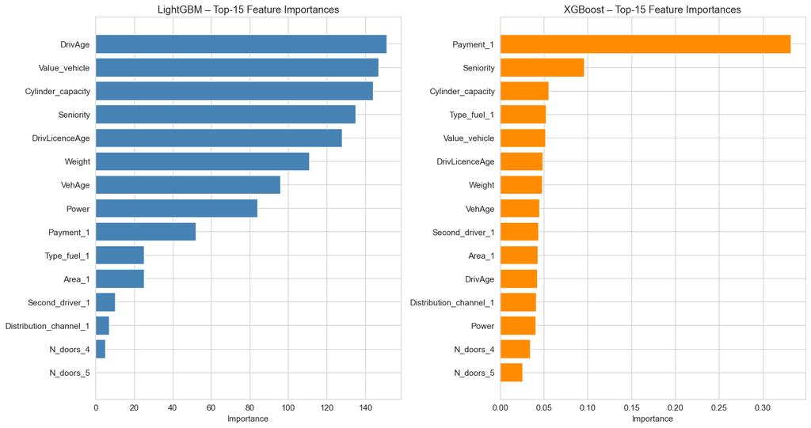

```python
# Feature-Importance-Plots (LightGBM vs XGBoost, nebeneinander)
fig, axes = plt.subplots(1, 2, figsize=(15, 8))
for ax, model, name, color in [
        (axes[0], lgb_model, 'LightGBM', 'steelblue'),
        (axes[1], xgb_model, 'XGBoost',  'darkorange')]:
    imp = model.feature_importances_
    top = np.argsort(imp)[-15:]
    ax.barh([feat_cols[i] for i in top], imp[top], color=color)
    ax.set_title(f'{name} – Top-15 Feature Importances')
    ax.set_xlabel('Importance')
plt.tight_layout(); plt.show()
```

```python
print(f'feat_cols_bag_red: {feat_cols_bag_red}')
print(f'feat_cols_rf_red:  {feat_cols_rf_red}')
```

```
feat_cols_bag_red: ['Seniority', 'Power', 'Cylinder_capacity', 'Value_vehicle', 'Weight', 'DrivAge', 'DrivLicenceAge', 'VehAge', 'Payment_1']
feat_cols_rf_red:  ['Seniority', 'Power', 'Cylinder_capacity', 'Value_vehicle', 'Weight', 'DrivAge', 'DrivLicenceAge', 'VehAge', 'Payment_1']
```

**Interpretation Feature-Importance:**

LightGBM und XGBoost zeigen deutlich unterschiedliche Rangfolgen sowie unterschiedliche Verteilungsmuster der Importance-Werte.

Bei LightGBM sind die ersten sechs Features (`Value_vehicle`, `DrivAge`, `Cylinder_capacity`, `Seniority`, `DrivLicenceAge`, `Weight`) nahezu gleichwertig — danach fällt die Importance steil ab. Dies deutet darauf hin, dass LightGBM die Vorhersagekraft gleichmäßig auf mehrere Features verteilt. Bei XGBoost hingegen dominiert `Payment_1` mit großem Abstand, danach fällt die Kurve bereits nach dem zweiten Feature stark ab — ein Zeichen für eine konzentriertere Nutzung weniger Features.

Auffällig ist, dass LightGBM `Payment_1` relativ gering gewichtet — obwohl es von den meisten bisherigen Modellen als eines der wichtigsten Features eingestuft wird. Die Ursache hierfür ist unklar und könnte auf die spezifischen von Optuna gefundenen Hyperparameter zurückzuführen sein.

Übereinstimmungen: `Seniority`, `Cylinder_capacity`, `DrivLicenceAge` und `Weight` erscheinen in beiden Modellen unter den Top-8 — konsistent mit den GLM-Koeffizienten. `N_doors_4` und `N_doors_5` rangieren in beiden Modellen am Ende, was die geringe Bedeutung der Türanzahl bestätigt.

### B2 c) Gradient Boosting mit Monotoniebeschränkungen

**Relevanz in der Versicherungstarifierung:** In der Tarifierung müssen Modellergebnisse nicht nur statistisch korrekt, sondern auch fachlich plausibel und kommunizierbar sein. Monotoniebeschränkungen sichern dies aus mehreren Gründen:

- **Erklärbarkeit und regulatorische Akzeptanz.** Tarifstrukturen müssen gegenüber Kunden, Vermittlern und Aufsicht (BaFin, EIOPA) plausibel sein. Ein höherer Beitrag bei einem 18-jährigen Fahranfänger als bei einem erfahrenen Fahrer lässt sich begründen.
- **Schutz vor Overfitting in dünn besetzten Bereichen.** An den Rändern des Wertebereichs (z. B. sehr alte Fahrer, sehr lange Vertragsdauer) neigen Black-Box-Modelle zu instabilen Schätzungen, weil dort wenige Beobachtungen vorliegen. Monotoniebeschränkungen wirken wie eine fachliche Glättung über datenarme Bereiche.
- **Schutz vor Antiselektion.** Nicht-monotone Tarife würden einzelnen Risikogruppen unbegründet günstigere Beiträge gewähren — diese Gruppen wechseln den Versicherer nicht, schlechtere bleiben, das Portfolio wird unauskömmlich.

**Trade-off Modellgüte vs. Plausibilität:** Monotoniebeschränkungen können die statistische Anpassungsgüte (Devianz) verschlechtern, weil das Modell nicht mehr jede empirische Schwankung abbilden darf. In der Praxis ist dieser Verlust meist gering, während der Gewinn an Interpretierbarkeit und Stabilität erheblich ist.

**Umsetzung in LightGBM und XGBoost:** Beide Bibliotheken prüfen bei jedem potenziellen Split, ob die Monotoniebedingung verletzt würde. Spezifiziert wird das über den Parameter `monotone_constraints` mit Werten {-1, 0, +1} pro Feature: -1 für fallend, +1 für steigend, 0 für unbeschränkt.

#### Empirische Prüfung der Monotoniebeschränkungen

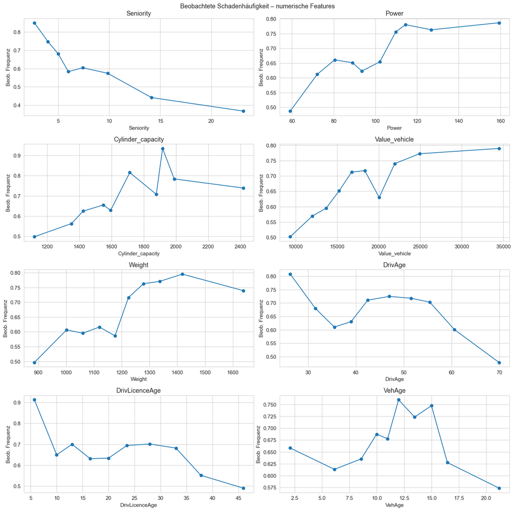

```python
# Binned Average Plot – beobachtete Frequenz je Feature
fig, axes = plt.subplots(4, 2, figsize=(15, 15))
freq_all = y_all / np.maximum(exp_all, 1e-10)

for ax, feat in zip(axes.flat, var_num):
    vals = df_ohe[feat].values
    bins = pd.qcut(vals, q=10, duplicates='drop')
    df_plot = pd.DataFrame({'bin': bins, 'freq': freq_all, 'val': vals})
    agg = df_plot.groupby('bin').agg(freq=('freq', 'mean'), val=('val', 'mean'))
    ax.plot(agg['val'].values, agg['freq'].values, 'o-')
    ax.set_title(feat)
    ax.set_xlabel(feat)
    ax.set_ylabel('Beob. Frequenz')
plt.suptitle('Beobachtete Schadenhäufigkeit – numerische Features', fontsize=13)
plt.tight_layout()
plt.show()
```

**Befund: Empirische Prüfung der Monotoniebeschränkungen**

Anhand der beobachteten Schadenhäufigkeit je Dezil wurden die numerischen Features auf monotone Verläufe untersucht:

**Seniority** — Zeigt einen klaren, konsistenten Rückgang der Schadenhäufigkeit mit zunehmender Vertragsdauer. Fachlich plausibel durch Survivorship Bias: Langzeitkunden sind selektiv risikoärmer. Stärkster Kandidat für eine fallende Monotoniebeschränkung.

**Power** — Überwiegend steigender Verlauf. Höhere Motorleistung könnte tendenziell mit risikoreicherem Fahrverhalten einher gehen. Plausibel als steigend beschränktes Feature.

**Cylinder_capacity** — Unruhiger, nicht-monotoner Verlauf ohne klare Richtung. Zudem stark mit Power korreliert, weshalb Power als der informativere und konsistentere Kandidat bevorzugt wird.

**Value_vehicle** — Überwiegend steigend, jedoch mit einem deutlichen lokalen Einbruch. Eine Monotoniebeschränkung wäre hier weniger für die Schadenhäufigkeit als für den Schadendurchschnitt (Severity) zu erwarten — teurere Fahrzeuge verursachen höhere Reparaturkosten, sind aber nicht zwingend häufiger in Unfälle verwickelt.

**Weight** — Steigender Trend, jedoch ohne überzeugenden kausalen Zusammenhang zur Schadenfrequenz. Kein geeigneter Kandidat.

**DrivAge** — Zeigt einen wellenartigen, nicht-monotonen Verlauf: Die Schadenhäufigkeit fällt zunächst bei jungen Fahrern ab, steigt im mittleren Altersbereich wieder an und fällt dann bei älteren Fahrern deutlich ab. Der starke Rückgang bei sehr hohem Fahreralter könnte darauf zurückzuführen sein, dass ältere Fahrer zwar vermutlich gefährdeter sind, aber seltener fahren und somit weniger Schadenereignisse produzieren. Aufgrund des nicht-monotonen Verlaufs ist eine Monotoniebeschränkung nicht sinnvoll.

**VehAge** — Unruhiger Verlauf ohne erkennbare Monotonie. Kein geeigneter Kandidat.

**Fazit:** Für das finale Modell werden Monotoniebeschränkungen für `Seniority` (fallend), `Power` (steigend) und `DrivLicenceAge` (fallend) verwendet.

##### Modellierung mit Monotoniebeschränkung

```python
# Indizes der Features mit Monotoniebeschränkung
idx_seniority    = feat_cols.index('Seniority')
idx_power        = feat_cols.index('Power')
idx_drivlicence  = feat_cols.index('DrivLicenceAge')

# Monotonieliste: 0 = keine, -1 = fallend, +1 = steigend
mc_list = [0] * len(feat_cols)
mc_list[idx_seniority]   = -1  # fallend: längere Vertragsdauer → weniger Schäden
mc_list[idx_power]       = +1  # steigend: höhere Motorleistung → mehr Schäden
mc_list[idx_drivlicence] = -1  # fallend: mehr Fahrerfahrung → weniger Schäden


# LightGBM mit Monotoniebeschränkungen
t0 = time.time()
lgb_mono = lgb.LGBMRegressor(**{**lgb_best_params,
                                 'monotone_constraints': mc_list})
lgb_mono.fit(X_train, freq_train, sample_weight=exp_train)
elapsed_lgb_mono = time.time() - t0

mu_train_lgb_mono = lgb_mono.predict(X_train) * exp_train
mu_val_lgb_mono   = lgb_mono.predict(X_val)   * exp_val
mu_test_lgb_mono  = lgb_mono.predict(X_test)  * exp_test

d_tr_lm = poisson_deviance(y_train, mu_train_lgb_mono, ex=exp_train)
d_va_lm = poisson_deviance(y_val,   mu_val_lgb_mono, ex=exp_val)
print(f'LightGBM+Mono  Train: {d_tr_lm:.6f}   Val: {d_va_lm:.6f}   Zeit: {elapsed_lgb_mono:.2f} s')
add_result('LightGBM+Monotonie', d_tr_lm, d_va_lm, elapsed=elapsed_lgb_mono)


# XGBoost mit Monotoniebeschränkungen
t0 = time.time()
mc_tuple = tuple(mc_list)

xgb_mono = xgb.XGBRegressor(
    **xgb_best_params,
    monotone_constraints=mc_tuple
)
xgb_mono.fit(X_train, freq_train, sample_weight=exp_train)
elapsed_xgb_mono = time.time() - t0

mu_train_xgb_mono = xgb_mono.predict(X_train) * exp_train
mu_val_xgb_mono   = xgb_mono.predict(X_val)   * exp_val
mu_test_xgb_mono  = xgb_mono.predict(X_test)  * exp_test

d_tr_xm = poisson_deviance(y_train, mu_train_xgb_mono, ex=exp_train)
d_va_xm = poisson_deviance(y_val,   mu_val_xgb_mono,   ex=exp_val)
print(f'XGBoost+Mono Train: {d_tr_xm:.6f}  Val: {d_va_xm:.6f}  Zeit: {elapsed_xgb_mono:.2f} s')
add_result('XGBoost+Monotonie', d_tr_xm, d_va_xm, elapsed=elapsed_xgb_mono)

print_results()
```

```
LightGBM+Mono  Train: 155.000604   Val: 163.207538   Zeit: 0.06 s
XGBoost+Mono Train: 154.280793  Val: 163.327605  Zeit: 0.07 s
                   Modell  Train Devianz  Val Devianz  Test Devianz  Train-Test-Gap  A/E Ratio  Zeit (s) Tuning Zeit (s)
  Basismodell (Intercept)     168.629990   171.520235           NaN             NaN        NaN      0.00               -
              GLM Poisson     160.846694   163.749578           NaN             NaN        NaN      0.04               -
      LASSO (Poisson, EN)     160.998115   163.493565           NaN             NaN        NaN      0.97            30.8
       NN (alle Features)     160.582954   163.674494           NaN             NaN        NaN      3.52               -
           NN (reduziert)     160.843724   163.702728           NaN             NaN        NaN      5.38               -
                  Bagging     155.669876   164.175834           NaN             NaN        NaN      2.56               -
            Random Forest     151.951967   163.832789           NaN             NaN        NaN      0.19               -
      Bagging (reduziert)     155.018566   164.360215           NaN             NaN        NaN      0.31               -
Random Forest (reduziert)     155.546028   162.908408           NaN             NaN        NaN      0.18               -
                 LightGBM     154.649106   162.960683           NaN             NaN        NaN      0.05             9.5
                  XGBoost     153.933366   162.945874           NaN             NaN        NaN      0.08            18.2
       LightGBM+Monotonie     155.000604   163.207538           NaN             NaN        NaN      0.06               -
        XGBoost+Monotonie     154.280793   163.327605           NaN             NaN        NaN      0.07               -
```

**Performance-Verlust durch Monotoniebeschränkungen:** Der Devianz-Anstieg auf der Validierungsmenge fällt mit +0,25 (LGBM) bzw. +0,38 (XGB) gering aus. Beide beschränkten Modelle bleiben besser als das GLM (163,75) — die fachliche Plausibilität wird also nahezu kostenlos gewonnen.

#### Interpretation mit PDPs

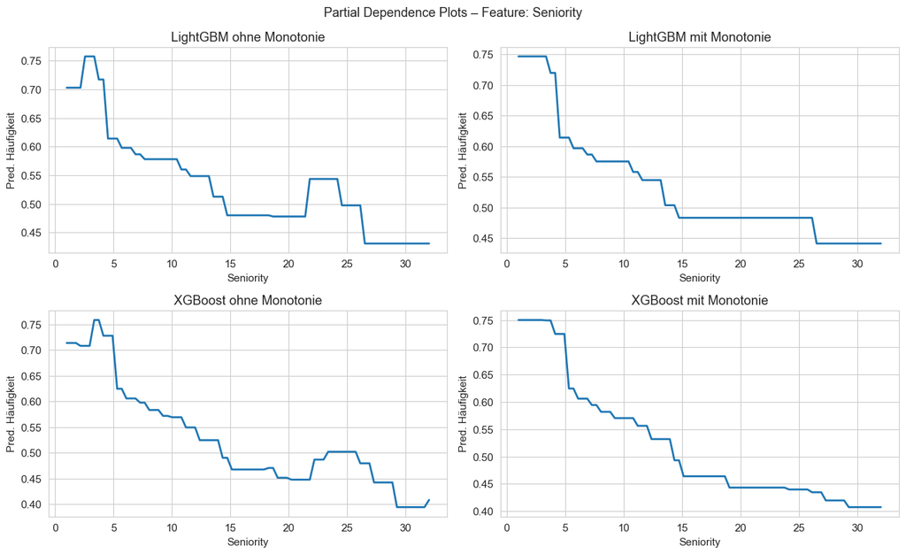

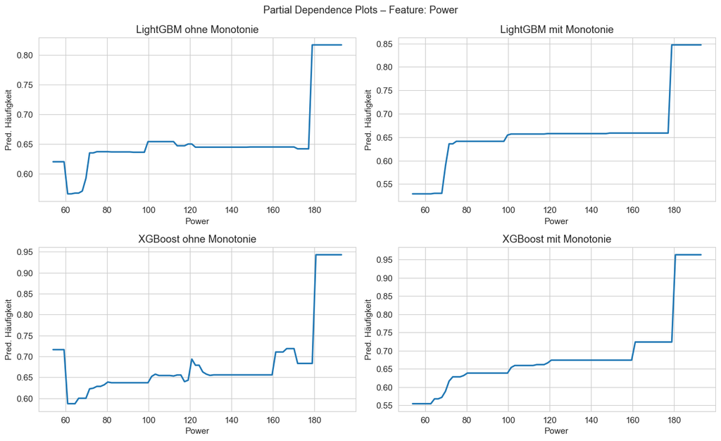

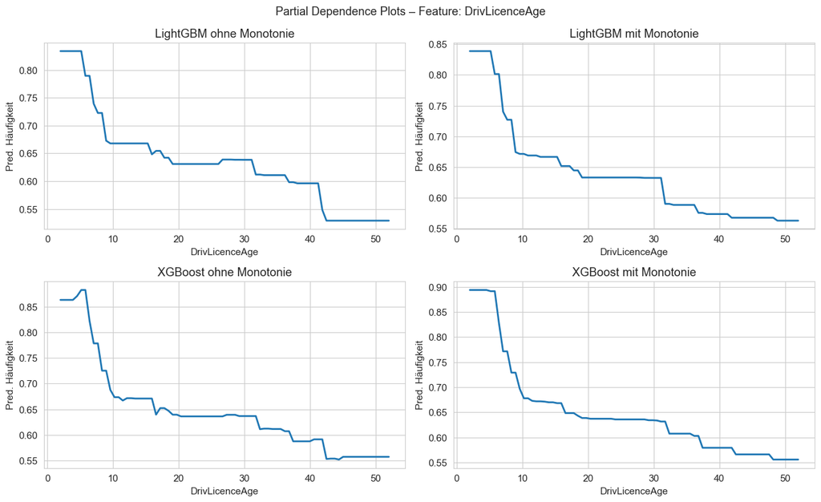

```python
# PDP-Funktion
def manual_pdp(model, X, feat_name, grid_vals, exposure_mean=1.0):
    X_copy = X.copy()
    pdp_vals = []
    for v in grid_vals:
        X_copy[feat_name] = v
        pdp_vals.append(model.predict(X_copy).mean() * exposure_mean)
    return np.array(pdp_vals)

exp_mean = exp_val.mean()

# 2×2 PDP-Grid je Feature
for pdp_feature in ['Seniority', 'Power', 'DrivLicenceAge']:
    grid_vals = np.linspace(
        np.quantile(X_val[pdp_feature], 0.01),
        np.quantile(X_val[pdp_feature], 0.99), 80
    )

    pdp_lgb      = manual_pdp(lgb_model, X_val, pdp_feature, grid_vals, exp_mean)
    pdp_lgb_mono = manual_pdp(lgb_mono,  X_val, pdp_feature, grid_vals, exp_mean)
    pdp_xgb      = manual_pdp(xgb_model, X_val, pdp_feature, grid_vals, exp_mean)
    pdp_xgb_mono = manual_pdp(xgb_mono,  X_val, pdp_feature, grid_vals, exp_mean)

    fig, axes = plt.subplots(2, 2, figsize=(13, 8), sharey=False)
    titles = ['LightGBM ohne Monotonie', 'LightGBM mit Monotonie',
              'XGBoost ohne Monotonie',  'XGBoost mit Monotonie']
    pdps   = [pdp_lgb, pdp_lgb_mono, pdp_xgb, pdp_xgb_mono]

    for ax, title, pdp in zip(axes.flat, titles, pdps):
        ax.plot(grid_vals, pdp, lw=2)
        ax.set_title(title)
        ax.set_xlabel(pdp_feature)
        ax.set_ylabel('Pred. Häufigkeit')

    plt.suptitle(f'Partial Dependence Plots – Feature: {pdp_feature}', fontsize=13)
    plt.tight_layout()
    plt.show()
```

**Interpretation Partial Dependence Plots**

Bei allen drei Features ist die Monotoniebeschränkung in den PDPs visuell klar erfüllt — die beschränkten Modelle zeigen den jeweils geforderten monotonen Verlauf ohne sichtbare Verletzungen.

**DrivLicenceAge** fügt sich am natürlichsten in die Beschränkung ein: Beide Modelle fallen bereits ohne Beschränkung weitgehend monoton, sodass die Korrektur minimal ausfällt und die Gesamtstruktur nahezu unverändert bleibt.

Bei **Seniority** zeigen beide unbeschränkten Modelle im Bereich hoher Vertragsdauer lokale Schwankungen, die vermutlich auf die abnehmende Beobachtungsanzahl in diesem Bereich zurückzuführen sind — das Modell stützt sich dort auf wenige Datenpunkte und reagiert entsprechend instabil. Auch zu Beginn ist eine leichte nicht-monotone Schwankung erkennbar, die jedoch als vernachlässigbar einzustufen ist. Die Monotoniebeschränkung bewirkt in beiden Fällen eine sinnvolle Glättung dieser datengetriebenen Ausreißer.

### B2 d) Auswertung und Interpretation am Testset

Alle Modelle werden auf dem **Testdatensatz** evaluiert. Kalibrierungscheck: Global (Actual/Expected-Ratio) und nach Dezilen (beobachtete vs. vorhergesagte Häufigkeit).

```python
# Test-Devianz für alle Modelle
test_predictions = {
    'Basismodell (Intercept)':     mu_test_base,
    'GLM Poisson':                 mu_test_glm,
    'LASSO (Poisson, EN)':         lasso_res.predict(X_lasso_test_c, offset=np.log(exp_test)),
    'NN (alle Features)':          mu_te_full,
    'NN (reduziert)':              mu_te_red,
    'Bagging':                     mu_test_bag,
    'Bagging (reduziert)':         mu_test_bag_red,
    'Random Forest':               mu_test_rf,
    'Random Forest (reduziert)':   mu_test_rf_red,
    'LightGBM':                    mu_test_lgb,
    'XGBoost':                     mu_test_xgb,
    'LightGBM+Monotonie':          mu_test_lgb_mono,
    'XGBoost+Monotonie':           mu_test_xgb_mono,
}

for name, mu_t in test_predictions.items():
    d_test = poisson_deviance(y_test, mu_t, ex=exp_test)
    ae     = y_test.sum() / np.maximum(mu_t.sum(), 1e-10)
    for r in results:
        if r['Modell'] == name:
            r['Test Devianz']  = round(d_test, 6)
            r['Train-Test-Gap']= round(d_test- r['Train Devianz'], 6)
            r['A/E Ratio']     = round(ae, 4)
            break

print("\nSortiert nach Test-Devianz:")
print_results(sorted(results, key=lambda x: x['Test Devianz']))
```

```
Sortiert nach Test-Devianz:
                   Modell  Train Devianz  Val Devianz  Test Devianz  Train-Test-Gap  A/E Ratio  Zeit (s) Tuning Zeit (s)
                  XGBoost     153.933366   162.945874    160.290493        6.357127     0.9975      0.08            18.2
                 LightGBM     154.649106   162.960683    160.403824        5.754718     0.9973      0.05             9.5
       LightGBM+Monotonie     155.000604   163.207538    160.500761        5.500157     0.9973      0.06               -
            Random Forest     151.951967   163.832789    160.523813        8.571846     0.9977      0.19               -
              GLM Poisson     160.846694   163.749578    160.697899       -0.148795     0.9991      0.04               -
Random Forest (reduziert)     155.546028   162.908408    160.711593        5.165565     0.9993      0.18               -
      LASSO (Poisson, EN)     160.998115   163.493565    160.778169       -0.219946     0.9886      0.97            30.8
        XGBoost+Monotonie     154.280793   163.327605    160.785664        6.504871     0.9968      0.07               -
      Bagging (reduziert)     155.018566   164.360215    161.130680        6.112114     0.9979      0.31               -
                  Bagging     155.669876   164.175834    161.251872        5.581996     0.9974      2.56               -
       NN (alle Features)     160.582954   163.674494    161.259590        0.676636     1.0011      3.52               -
           NN (reduziert)     160.843724   163.702728    161.319120        0.475396     0.9937      5.38               -
  Basismodell (Intercept)     168.629990   171.520235    169.116800        0.486810     0.9913      0.00               -
```

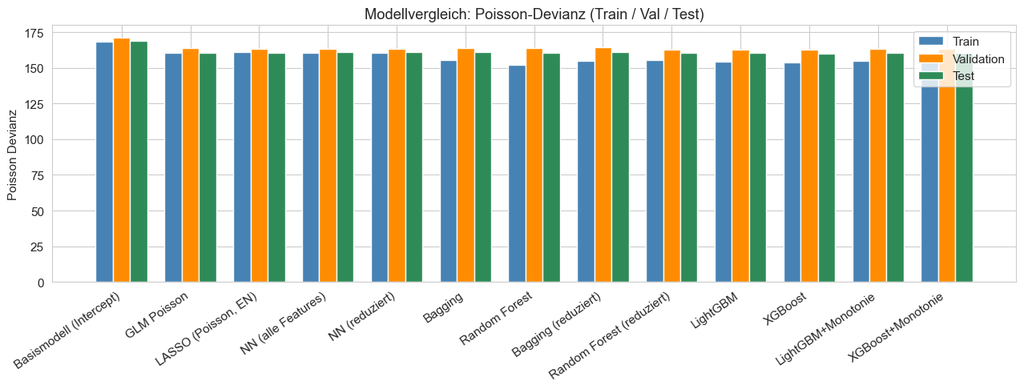

```python
# Vergleichsplot: Train / Val / Test Devianz – alle Modelle
df_res = pd.DataFrame(results)

fig, ax = plt.subplots(figsize=(13, 5))
x = np.arange(len(df_res))
w = 0.25
ax.bar(x - w, df_res['Train Devianz'], w, label='Train',      color='steelblue')
ax.bar(x,     df_res['Val Devianz'],   w, label='Validation', color='darkorange')
ax.bar(x + w, df_res['Test Devianz'],  w, label='Test',       color='seagreen')
ax.set_xticks(x)
ax.set_xticklabels(df_res['Modell'], rotation=35, ha='right')
ax.set_ylabel('Poisson Devianz')
ax.legend()
ax.set_title('Modellvergleich: Poisson-Devianz (Train / Val / Test)')
plt.tight_layout()
plt.show()
```

```python
# Bestes Modell nach Test-Devianz
best_model  = df_res.sort_values('Test Devianz').iloc[0]
baseline    = df_res[df_res['Modell'] == 'Basismodell (Intercept)'].iloc[0]

abs_improvement = baseline['Test Devianz'] - best_model['Test Devianz']
rel_improvement = abs_improvement / baseline['Test Devianz'] * 100
best_model_name = best_model['Modell']

print(f"Bestes Modell:         {best_model_name}")
print(f"Test-Devianz:          {best_model['Test Devianz']:.6f}")
print(f"Baseline-Devianz:      {baseline['Test Devianz']:.6f}")
print(f"Absolute Verbesserung: {abs_improvement:.6f}")
print(f"Relative Verbesserung: {rel_improvement:.2f} %")
```

```
Bestes Modell:         XGBoost
Test-Devianz:          160.290493
Baseline-Devianz:      169.116800
Absolute Verbesserung: 8.826307
Relative Verbesserung: 5.22 %
```

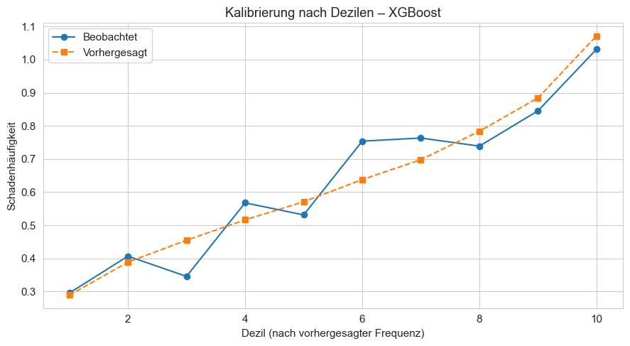

```python
# Kalibrierung nach Dezilen – bestes Modell
mu_best = test_predictions[best_model_name]
deciles = pd.qcut(mu_best / exp_test, q=10, labels=False, duplicates='drop')

dec_df  = pd.DataFrame({'decile': deciles, 'actual': y_test, 'predicted': mu_best})
dec_agg = dec_df.groupby('decile').agg(
    actual=('actual', 'sum'), predicted=('predicted', 'sum'),
    n=('actual', 'count')
).assign(actual_freq=lambda d: d['actual']    / d['n'],
         pred_freq  =lambda d: d['predicted'] / d['n'])

fig, ax = plt.subplots(figsize=(9, 5))
ax.plot(dec_agg.index + 1, dec_agg['actual_freq'], 'o-',  label='Beobachtet')
ax.plot(dec_agg.index + 1, dec_agg['pred_freq'],   's--', label='Vorhergesagt')
ax.set_xlabel('Dezil (nach vorhergesagter Frequenz)')
ax.set_ylabel('Schadenhäufigkeit')
ax.legend()
ax.set_title(f'Kalibrierung nach Dezilen – {best_model_name}')
plt.tight_layout()
plt.show()
```

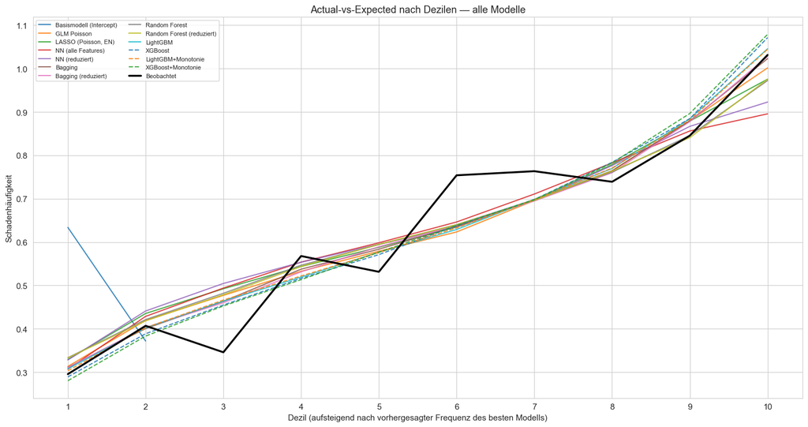

```python
# Actual-vs-Expected nach Dezilen — alle Modelle
fig, ax = plt.subplots(figsize=(15, 8))

colors = plt.cm.tab10.colors
linestyles = ['-', '--']
style_cycle = itertools.cycle(itertools.product(linestyles, colors))

for name, mu_t in test_predictions.items():
    ls, color = next(style_cycle)

    pred_freq = mu_t / np.maximum(exp_test, 1e-10)
    try:
        deciles = pd.qcut(pred_freq, q=10, labels=False, duplicates='drop')
    except Exception:
        continue

    dec_agg = (pd.DataFrame({'decile': deciles, 'predicted': mu_t, 'n': 1})
               .groupby('decile')
               .agg(predicted=('predicted', 'sum'), n=('n', 'sum'))
               .assign(pred_freq=lambda d: d['predicted'] / d['n']))

    ax.plot(dec_agg.index + 1, dec_agg['pred_freq'],
            linestyle=ls, lw=1.5,
            color=color, label=name, alpha=0.85)

# Beobachtete Frequenz nach Dezilen des besten Modells
pred_freq_best = test_predictions[best_model_name] / np.maximum(exp_test, 1e-10)
deciles_best   = pd.qcut(pred_freq_best, q=10, labels=False, duplicates='drop')
actual_by_decile = (pd.DataFrame({'decile': deciles_best, 'actual': y_test})
                    .groupby('decile')
                    .agg(actual_freq=('actual', 'mean')))

ax.plot(actual_by_decile.index + 1, actual_by_decile['actual_freq'],
        linestyle='-', lw=2.5, color='black',
        label='Beobachtet', zorder=10)

ax.set_xlabel('Dezil (aufsteigend nach vorhergesagter Frequenz des besten Modells)')
ax.set_ylabel('Schadenhäufigkeit')
ax.set_title('Actual-vs-Expected nach Dezilen — alle Modelle')
ax.legend(fontsize=8, loc='upper left', ncol=2)
ax.set_xticks(range(1, 11))
plt.tight_layout()
plt.show()
```

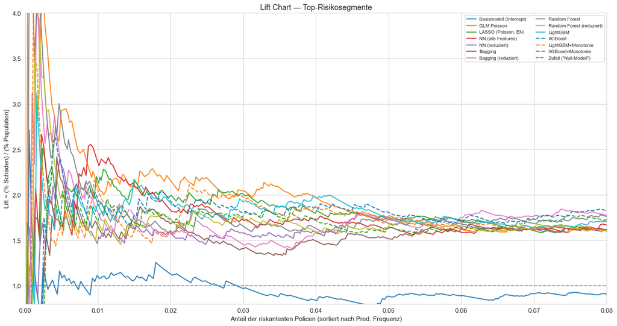

```python
# === Lift Chart ===
fig, ax = plt.subplots(figsize=(15, 8))

colors = plt.cm.tab10.colors
linestyles  = ['-', '--']
style_cycle = itertools.cycle(itertools.product(linestyles, colors))

for name, mu_t in test_predictions.items():
    ls, color = next(style_cycle)

    pred_freq = mu_t / np.maximum(exp_test, 1e-10)
    order     = np.argsort(-pred_freq)

    cum_exp    = np.cumsum(exp_test[order]) / exp_test.sum()
    cum_claims = np.cumsum(y_test[order])   / y_test.sum()
    lift       = cum_claims / np.maximum(cum_exp, 1e-10)

    ax.plot(cum_exp, lift, lw=1.8, color=color, linestyle=ls,
            label=name, alpha=0.9)

ax.axhline(1.0, color='gray', linestyle='--', lw=1.5, label='Zufall ("Null-Modell")')
ax.set_xlabel('Anteil der riskantesten Policen (sortiert nach Pred. Frequenz)')
ax.set_ylabel('Lift = (% Schäden) / (% Population)')
ax.set_title('Lift Chart — Top-Risikosegmente')
ax.legend(fontsize=8, loc='upper right', ncol=2)
ax.set_xlim(0, 0.08)
ax.set_ylim(0.8, 4)
plt.tight_layout()
plt.show()
```

#### Interpretation

**Globale Kalibrierung (A/E-Ratio):**  
Die meisten Modelle liegen zwischen 0,993 und 1,001 — ausgezeichnete globale Kalibrierung. LASSO ist mit 0,989 etwas schwächer, das Basismodell mit 0,991 ebenso. Kein Modell unterschätzt oder überschätzt den Gesamtschaden systematisch um mehr als 1,2 %.

**Risikodifferenzierung (Lift-Chart):**  
Im Lift-Chart der Top-8 % Risikosegmente zeigt sich ein interessantes Muster: In den extremsten Risiko-Spitzen (bis ca. 4 %) erreicht überraschend das GLM Poisson die höchsten Lift-Werte und identifiziert dort die Hochrisiko-Policen am besten. Erst ab ca. 4–5 % der Population übernehmen LightGBM und XGBoost die Führung, mit konsistent höherem Lift bis zum Plotende. Das Basismodell verläuft erwartungsgemäß auf der Random-Baseline (Lift = 1,0).

Die Ergebnisse legen nahe: Für die Identifikation extremer Hochrisiko-Policen ist das GLM dem komplexeren Boosting nicht unterlegen — erst im breiteren Risikosegment differenzieren die Boosting-Modelle stärker.

**Gesamtfazit:**  
XGBoost gewinnt knapp bei der Test-Devianz (160,29 vs. GLM 160,70), aber das GLM ist bei der Auskömmlichkeit (A/E 0,9991) und in der Identifikation der extremen Hochrisiko-Policen (Top-4 %) sogar das stärkere Modell. Bei einer Devianz-Einbuße von nur 0,4 Punkten bietet das GLM zusätzlich vollständige Interpretierbarkeit und regulatorische Akzeptanz. Für die operative Tarifierung wäre das GLM Poisson eine ebenso vertretbare — wenn nicht sogar vorzuziehende — Wahl gegenüber den Boosting-Modellen.

## Aufgabe B3: Modellierung des Schadendurchschnitts

Modellierung von $\text{AvgClaimAmount} = \text{Cost\_claims\_year} / N\_\text{claims\_year}$ für Policen mit $N > 0$.

### B3 a) Datenvorbereitung und Verteilungsannahme

**Warum nur N_claims_year > 0?**

Die Zielvariable `AvgClaimAmount = Cost_claims_year / N_claims_year` ist für Policen ohne Schaden (N = 0) mathematisch undefiniert. Darüber hinaus modelliert das Severity-Modell den *bedingten* Erwartungswert $\mathbb{E}[S \mid N > 0]$ — also die erwartete Schadenhöhe *gegeben dass ein Schaden eingetreten ist*. Diese Trennung ist methodisch notwendig: Im Frequency-Modell (B2) wird bereits die Wahrscheinlichkeit eines Schadens geschätzt; das Severity-Modell ergänzt die bedingte Höhe.

```python
# Filter:Nur Schäden > 0
mask_sev = y_all > 0
df_sev   = df_ohe[mask_sev].copy()
# Zielvariable
avg_claim = (df['Cost_claims_year'].values[mask_sev] /
             df['N_claims_year'].values[mask_sev])

# Gleiche Split-Indizes (innerhalb der gefilterten Menge)
global_idx_sev = np.where(mask_sev)[0]  # absolute Indizes im Original
# Auf Train/Val/Test aufteilen basierend auf den globalen Indizes
in_train = np.isin(global_idx_sev, idx_train)
in_val   = np.isin(global_idx_sev, idx_val)
in_test  = np.isin(global_idx_sev, idx_test)

X_sev_train = df_ohe[feat_cols].values[mask_sev][in_train]
X_sev_val   = df_ohe[feat_cols].values[mask_sev][in_val]
X_sev_test  = df_ohe[feat_cols].values[mask_sev][in_test]

y_sev_train = avg_claim[in_train]
y_sev_val   = avg_claim[in_val]
y_sev_test  = avg_claim[in_test]

# Gewichte = N_claims_year (informativere Policen stärker gewichten)
w_sev_train = df['N_claims_year'].values[mask_sev][in_train].astype(float)
w_sev_val   = df['N_claims_year'].values[mask_sev][in_val].astype(float)
w_sev_test  = df['N_claims_year'].values[mask_sev][in_test].astype(float)

print(f'Severity Train: {len(y_sev_train)}, Val: {len(y_sev_val)}, Test: {len(y_sev_test)}')
print(f'AvgClaimAmount  Min: {y_sev_train.min():.2f}  Max: {y_sev_train.max():.2f}  '
      f'Mean: {y_sev_train.mean():.2f}  Median: {np.median(y_sev_train):.2f}')
```

```
Severity Train: 3049, Val: 1067, Test: 1002
AvgClaimAmount  Min: 6.53  Max: 86951.08  Mean: 530.26  Median: 167.69
```

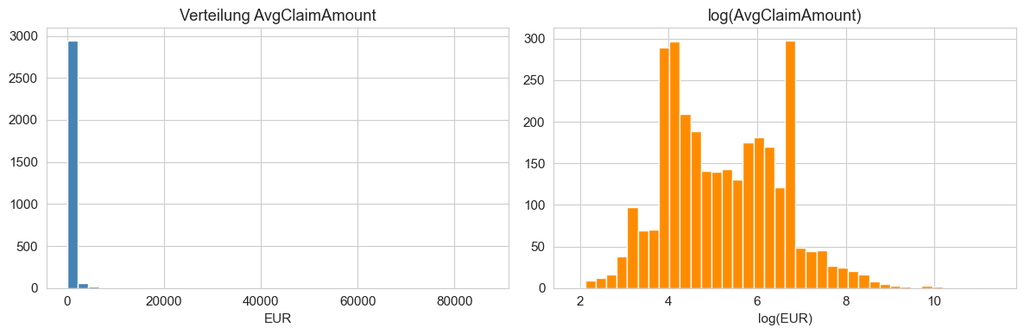

```python
# Visualisierung der Verteilungsannahme
fig, axes = plt.subplots(1, 2, figsize=(12, 4))
axes[0].hist(y_sev_train, bins=40, color='steelblue', edgecolor='white')
axes[0].set_title('Verteilung AvgClaimAmount'); axes[0].set_xlabel('EUR')
axes[1].hist(np.log(y_sev_train), bins=40, color='darkorange', edgecolor='white')
axes[1].set_title('log(AvgClaimAmount)'); axes[1].set_xlabel('log(EUR)')
plt.tight_layout(); plt.show()
```

**Verteilungsannahme:**

| Verteilung | Varianzfunktion | Typische Anwendung |
| --- | --- | --- |
| Gamma | V(μ) = μ² | Standard für Schadenhöhen mit moderatem Schweif |
| Inverse Gauß | V(μ) = μ³ | Alternative bei schwereren Schweifen |
| Log-Normal | V(μ) = μ²·σ² | Klassische Alternative, jedoch nicht unter Summation abgeschlossen |

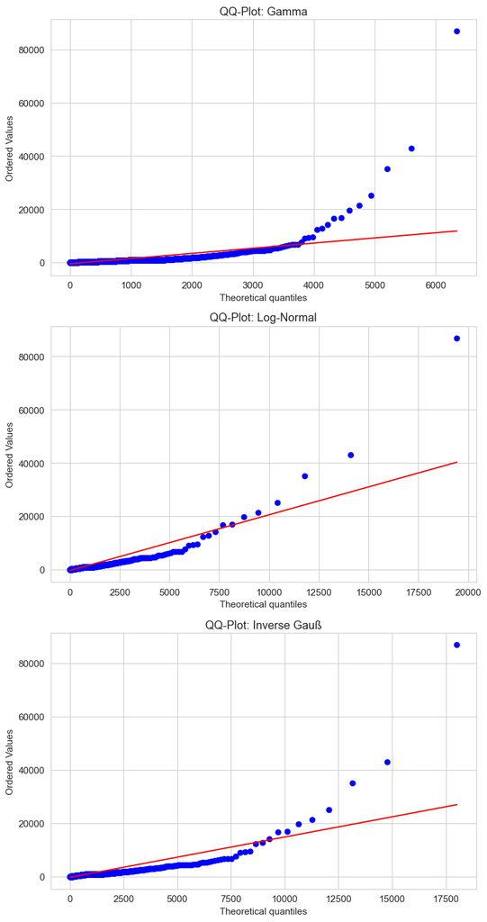

```
Log-Likelihood Gamma         (Tweedie p=2):    -21841.90
Log-Likelihood Log-Normal:                     -21147.30
Log-Likelihood Inverse Gauß  (Tweedie p=3):    -21097.62
```

```python
fig, axes = plt.subplots(3, 1, figsize=(8, 15))

# Gamma
params_gamma = stats.gamma.fit(y_sev_train, floc=0)
stats.probplot(y_sev_train, dist='gamma', sparams=params_gamma, plot=axes[0])
axes[0].set_title('QQ-Plot: Gamma')

# Log-Normal
params_lognorm = stats.lognorm.fit(y_sev_train, floc=0)
stats.probplot(y_sev_train, dist='lognorm', sparams=params_lognorm, plot=axes[1])
axes[1].set_title('QQ-Plot: Log-Normal')

# Inverse Gauß
params_invgauss = stats.invgauss.fit(y_sev_train, floc=0)
stats.probplot(y_sev_train, dist='invgauss', sparams=params_invgauss, plot=axes[2])
axes[2].set_title('QQ-Plot: Inverse Gauß')

plt.tight_layout()
plt.show()

# Log-Likelihoods
ll_gamma    = stats.gamma.logpdf(y_sev_train,    *params_gamma).sum()
ll_lognorm  = stats.lognorm.logpdf(y_sev_train,  *params_lognorm).sum()
ll_invgauss = stats.invgauss.logpdf(y_sev_train, *params_invgauss).sum()

print(f'Log-Likelihood Gamma         (Tweedie p=2): {ll_gamma:>12.2f}')
print(f'Log-Likelihood Log-Normal:                  {ll_lognorm:>12.2f}')
print(f'Log-Likelihood Inverse Gauß  (Tweedie p=3): {ll_invgauss:>12.2f}')

params_gamma    = stats.gamma.fit(y_sev_train, floc=0)
params_invgauss = stats.invgauss.fit(y_sev_train, floc=0)
params_lognorm  = stats.lognorm.fit(y_sev_train, floc=0)
```

**Befund zum Tail:** Bei allen drei Verteilungen liegen die obersten Datenpunkte über der theoretischen Diagonale — die seltenen Großschäden werden von Gamma, Log-Normal und Inverse Gauß systematisch unterschätzt. Das ist ein bekanntes Phänomen bei Schadenhöhen ("heavy tail") und wird in der aktuariellen Praxis durch eine Splitting-Strategie adressiert: Schäden unterhalb einer Schwelle werden mit Gamma modelliert, darüber mit einer schwergetailten Verteilung wie Pareto. Im Rahmen dieser Aufgabe wird auf die Trennung verzichtet — die Punkt-Schätzung des Erwartungswertes bleibt unter Gamma asymptotisch konsistent, lediglich das Großschadenrisiko wird im Modell systematisch unterschätzt.

**Wahl der Gamma-Verteilung:**

Trotz der schlechteren Anpassungsgüte (Log-Likelihood Gamma -21842 vs. Log-Normal -21147 vs. Inverse Gauß -21098) wird Gamma als Verteilungsannahme gewählt.

Gamma und Inverse Gauß sind beide EDF-Mitglieder und in Wüthrich/Merz (Kap. 5.3.7 / 5.3.8) als Standardansätze für Schadenhöhen-GLMs beschrieben. Log-Normal scheidet aus: Sie gehört nicht zur EDF und ist nicht geschlossen unter Summation (Wüthrich/Merz, 5.3.9).

Inverse Gauß bildet schwerere Tails besser ab, die Varianzfunktion V(μ) = μ² der Gamma-Verteilung ist für den hier beobachteten moderaten Tail jedoch ausreichend. Zusätzlich entspricht Gamma dem Tweedie-Spezialfall p = 2, was den Anschluss an die Pure-Premium-Modellierung in B4 vereinfacht.

### B3 b) Wahl und Implementierung der Evaluierungsfunktion

Für die Bewertung der Severity-Modelle werden zwei sich ergänzende Metriken verwendet:

**1. Gamma-Devianz** als primäre Metrik:

$$D_\Gamma = 2 \sum_i w_i \left[ \frac{y_i - \hat{\mu}_i}{\hat{\mu}_i} - \ln \frac{y_i}{\hat{\mu}_i} \right]$$

Die Gamma-Devianz ist die natürliche Verlustfunktion der Gamma-Verteilung und entspricht (bis auf Konstanten) der negativen Log-Likelihood. GLM- und GAM-Schätzer minimieren via IRLS genau diese Devianz — die Metrik ist damit konsistent zum Schätzverfahren. Sie penalisiert relative Abweichungen, was im Severity-Kontext sachgerecht ist: Eine Vorhersage von 1.000 EUR statt 500 EUR ist relativ gleich falsch wie 10.000 EUR statt 5.000 EUR.

**2. MAE (Mean Absolute Error)** als ergänzende Metrik:

$$\text{MAE} = \frac{\sum_i w_i \cdot |y_i - \hat{\mu}_i|}{\sum_i w_i}$$

Die MAE liefert einen direkt interpretierbaren Fehler in EUR und ergänzt die dimensionslose Gamma-Devianz um eine praxisnahe Einordnung der absoluten Vorhersagequalität. MSE wurde nicht gewählt, da die wenigen Extremschäden die Metrik dominieren würden und das Modellranking verzerren.

```python
def gamma_devianz(y_true, y_pred, weights=None):
    """Gewichtete Gamma-Devianz: 2 * mean_w( (y-mu)/mu - log(y/mu) )"""
    y_true = np.asarray(y_true, dtype=float)
    y_pred = np.clip(np.asarray(y_pred, dtype=float), 1e-6, None)
    d = (y_true - y_pred) / y_pred - np.log(y_true / y_pred)
    if weights is not None:
        w = np.asarray(weights, dtype=float)
        return 2.0 * np.average(d, weights=w)
    return 2.0 * np.mean(d)

def mae(y_true, y_pred, weights=None):
    """Gewichteter Mean Absolute Error in EUR."""
    y_true = np.asarray(y_true, dtype=float)
    y_pred = np.asarray(y_pred, dtype=float)
    abs_err = np.abs(y_true - y_pred)
    if weights is not None:
        w = np.asarray(weights, dtype=float)
        return np.average(abs_err, weights=w)
    return np.mean(abs_err)

# Ergebnisliste für Severity-Modelle (analog zu B1 b))
results_sev = []

def add_sev_result(name, train_dev, val_dev, test_dev=None,
                   train_mae=None, val_mae=None, test_mae=None,
                   elapsed=None, tuning_time=None):
    global results_sev
    results_sev = [r for r in results_sev if r['Modell'] != name]
    test_dev_f = float(test_dev) if test_dev is not None else np.nan
    gap = round(float(train_dev) - test_dev_f, 6) \
          if test_dev is not None else np.nan
    results_sev.append({
        'Modell'          : name,
        'Train Gamma-Dev' : round(float(train_dev), 6),
        'Val Gamma-Dev'   : round(float(val_dev),   6),
        'Test Gamma-Dev'  : round(test_dev_f,        6),
        'Train-Test-Gap'  : gap,
        'Train MAE'       : round(float(train_mae), 2) if train_mae is not None
                            else np.nan,
        'Val MAE'         : round(float(val_mae),   2) if val_mae   is not None
                            else np.nan,
        'Test MAE'        : round(float(test_mae),  2) if test_mae  is not None
                            else np.nan,
        'Zeit (s)'        : round(float(elapsed), 2)   if elapsed   is not None
                            else np.nan,
        'Tuning Zeit (s)' : round(float(tuning_time), 1) if tuning_time is not None
                            else '-',
    })
```

**Gewichtungsstrategie:**

Beide Metriken werden mit `w = N_claims_year` gewichtet. Die Zielvariable `AvgClaimAmount` ist ein Durchschnitt über $N$ Einzelschäden — ihre Varianz sinkt proportional mit N:

$$\text{Var}(\bar{Z}_i) = \frac{\text{Var}(Z_{ij})}{N_i} \propto \frac{\mu_i^2}{N_i}$$

In `statsmodels` wird `var_weights=N_i` verwendet, das diese Varianzstruktur direkt modelliert. In `pygam` verhält sich `weights=N_i` gemäß Quellcode ebenfalls als Varianzgewicht. Beide Spezifikationen sind damit konsistent. `freq_weights` wurde bewusst nicht verwendet, da es die Stichprobengröße künstlich auf $\sum N_i$ aufbläht und zu verzerrten Standardfehlern führt.

### B3 c) GLM (Gamma-Regressor)

Die Modellierung erfolgt in drei Schritten:

1. **Feature-Selection** der acht wichtigsten Prädiktoren via Random Forest
2. **Schätzung** eines Gamma-GLMs mit Log-Link auf den selektierten Features
3. **Regularisierung** durch Elastic-Net-Tuning mit Optuna

**Wahl des Feature-Selection-Verfahrens:**

Random Forest Importance wird gewählt, da das Verfahren modellunabhängig ist (die Selection wird nicht vom später trainierten GLM beeinflusst), nicht-lineare Zusammenhänge erfasst (relevant für das spätere GAM in B3 d) und keine Skalierung der Features erfordert. Lineare Alternativen wie Pearson-Korrelation oder LASSO würden die nachfolgende Modellwahl vorwegnehmen.

**Eignung der Gamma-Verteilung — Vor- und Nachteile**

Die grundsätzliche Verteilungswahl wurde bereits in B3 a) begründet (EDF-Mitgliedschaft, Geschlossenheit unter Summation, Tweedie p = 2, Einordnung gegenüber Log-Normal und Inverse Gauß).

Spezifisch im GLM-Kontext kommt hinzu:

- Mit Log-Link ist die Gamma-Verteilung in `statsmodels` direkt via IRLS schätzbar. Der Log-Link ist allerdings nicht der kanonische Link (kanonisch wäre der reziproke Link), wodurch die Balance Property nicht automatisch erfüllt ist (Wüthrich/Merz, Kap. 5.3.7).
- Die Varianzstruktur Var(Y) = ϕ·μ² impliziert einen konstanten Variationskoeffizienten — eine Annahme, die in der Praxis nicht immer erfüllt ist und bei Bedarf über ein Double GLM behandelt werden könnte.

#### Feature-Selection mit Random Forest

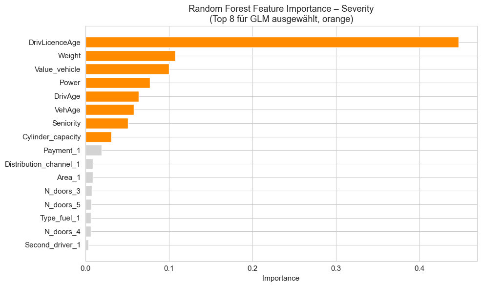

```
Ausgewählte Features (Top 8):
DrivLicenceAge       0.4465
Weight               0.1074
Value_vehicle        0.0999
Power                0.0773
DrivAge              0.0635
VehAge               0.0579
Seniority            0.0505
Cylinder_capacity    0.0306
```

```python
# Feature-Selection mit Random Forest
rf_sel = RandomForestRegressor(
    n_estimators=200,
    random_state=SEED,
    n_jobs=-1
)
rf_sel.fit(X_sev_train, y_sev_train, sample_weight=w_sev_train)

imp_sel  = pd.Series(rf_sel.feature_importances_,
                     index=feat_cols).sort_values(ascending=False)
selected_feats_sev = imp_sel.head(8).index.tolist()

# Visualisierung der Importance — Top 8 hervorgehoben
fig, ax = plt.subplots(figsize=(10, 6))
colors = ['darkorange' if f in selected_feats_sev else 'lightgrey'
          for f in imp_sel.index[::-1]]
ax.barh(imp_sel.index[::-1], imp_sel.values[::-1], color=colors)
ax.set_title('Random Forest Feature Importance – Severity\n'
             '(Top 8 für GLM ausgewählt, orange)')
ax.set_xlabel('Importance')
plt.tight_layout()
plt.show()

print('Ausgewählte Features (Top 8):')
print(imp_sel.head(8).round(4).to_string())
```

#### Schätzung

**Gamma-GLM (unreguliert):**

Das Modell wird mit Log-Link und der Gewichtung `w = N_claims_year` auf den acht selektierten Features geschätzt.

```python
# Standardisierung der selektierten Features
scaler_sev = StandardScaler().set_output(transform="pandas")

X_sev_train_df = pd.DataFrame(X_sev_train, columns=feat_cols)[selected_feats_sev]
X_sev_val_df   = pd.DataFrame(X_sev_val,   columns=feat_cols)[selected_feats_sev]
X_sev_test_df  = pd.DataFrame(X_sev_test,  columns=feat_cols)[selected_feats_sev]

X_sev_train_s = sm.add_constant(scaler_sev.fit_transform(X_sev_train_df))
X_sev_val_s   = sm.add_constant(scaler_sev.transform(X_sev_val_df))
X_sev_test_s  = sm.add_constant(scaler_sev.transform(X_sev_test_df))

# Unreguliertes Gamma-GLM
t0 = time.time()
gamma_glm = sm.GLM(
    y_sev_train, X_sev_train_s,
    family=sm.families.Gamma(link=sm.families.links.Log()),
    var_weights=w_sev_train # Varianzgewichte
)
gamma_glm_res = gamma_glm.fit(maxiter=300)
elapsed_gglm = time.time() - t0

print(gamma_glm_res.summary())
print(f'\nTrainingszeit: {elapsed_gglm:.2f} s')
```

```
                 Generalized Linear Model Regression Results
==============================================================================
Dep. Variable:                      y   No. Observations:                 3049
Model:                            GLM   Df Residuals:                     3040
Model Family:                   Gamma   Df Model:                            8
Link Function:                    Log   Scale:                          23.384
Method:                          IRLS   Log-Likelihood:                -25014.
Date:                Tue, 05 May 2026   Deviance:                       12494.
Time:                        16:53:42   Pearson chi2:                 7.11e+04
No. Iterations:                    25   Pseudo R-squ. (CS):            0.01191
Covariance Type:            nonrobust
=====================================================================================
                        coef    std err          z      P>|z|      [0.025      0.975]
-------------------------------------------------------------------------------------
const                 6.0870      0.062     97.652      0.000       5.965       6.209
DrivLicenceAge       -0.2077      0.127     -1.632      0.103      -0.457       0.042
Weight               -0.1098      0.123     -0.891      0.373      -0.351       0.132
Value_vehicle         0.1526      0.146      1.048      0.294      -0.133       0.438
Power                 0.1622      0.127      1.278      0.201      -0.087       0.411
DrivAge               0.0740      0.127      0.580      0.562      -0.176       0.324
VehAge               -0.1060      0.074     -1.429      0.153      -0.251       0.039
Seniority            -0.1007      0.069     -1.462      0.144      -0.236       0.034
Cylinder_capacity     0.0025      0.113      0.022      0.982      -0.220       0.225
=====================================================================================

Trainingszeit: 0.02 s
```

**Befund zur Signifikanz:** Keiner der acht Prädiktoren ist auf 5 %-Niveau signifikant (kleinster p-Wert: DrivLicenceAge 0,103), Pseudo R² (CS) = 0,012. Im Vergleich zum Frequency-GLM aus B1 d) (Pseudo R² = 0,074, 12 von 16 Features signifikant) erklären Tarifmerkmale die Schadenhöhe also deutlich schlechter als die Schadenhäufigkeit — die Höhe eines Einzelschadens ist offenbar stärker zufallsgetrieben.

```python
# Evaluierung auf Train/Val/Test
mu_sev_tr_glm = gamma_glm_res.predict(X_sev_train_s)
mu_sev_va_glm = gamma_glm_res.predict(X_sev_val_s)
mu_sev_te_glm = gamma_glm_res.predict(X_sev_test_s)

d_tr = gamma_devianz(y_sev_train, mu_sev_tr_glm, w_sev_train)
d_va = gamma_devianz(y_sev_val,   mu_sev_va_glm, w_sev_val)
d_te = gamma_devianz(y_sev_test,  mu_sev_te_glm, w_sev_test)

m_tr = mae(y_sev_train, mu_sev_tr_glm, w_sev_train)
m_va = mae(y_sev_val,   mu_sev_va_glm, w_sev_val)
m_te = mae(y_sev_test,  mu_sev_te_glm, w_sev_test)

add_sev_result('Gamma-GLM', d_tr, d_va, d_te,
               train_mae=m_tr, val_mae=m_va, test_mae=m_te,
               elapsed=elapsed_gglm)

print_results(results_sev)
```

```
   Modell  Train Gamma-Dev  Val Gamma-Dev  Test Gamma-Dev  Train-Test-Gap  Train MAE  Val MAE  Test MAE  Zeit (s) Tuning Zeit (s)
Gamma-GLM         2.070239       2.057845        2.304599        -0.23436      514.8   502.87    544.93      0.02               -
```

#### Regularisierung — Elastic-Net-Tuning mit Optuna:

Analog zu B2 b) wird Optuna mit dem TPE-Sampler verwendet, um simultan über `alpha` (Regularisierungsstärke) und `L1_wt` (Mischung L1/L2) zu optimieren. Damit wird empirisch entschieden, ob Ridge, LASSO oder Elastic Net am besten generalisiert — statt diese Wahl ex ante zu treffen.

```python
def fit_regularized_gamma(alpha, l1_wt, X, y, w):
    """Gamma-GLM mit Elastic-Net-Regularisierung."""
    return sm.GLM(
        y, X,
        family=sm.families.Gamma(link=sm.families.links.Log()),
        var_weights =w  # Varianzgewichte
    ).fit_regularized(alpha=alpha, L1_wt=l1_wt, maxiter=300)


def objective(trial):
    alpha = trial.suggest_float('alpha', 0.0001, 1.0, log=True)
    l1_wt = trial.suggest_float('L1_wt', 0.0, 1.0)
    try:
        res = fit_regularized_gamma(alpha, l1_wt,
                                    X_sev_train_s, y_sev_train, w_sev_train)
        mu_v  = res.predict(X_sev_val_s)
        dev_v = gamma_devianz(y_sev_val, mu_v, w_sev_val)
    except Exception:
        return float('inf')
    if dev_v is None or not np.isfinite(dev_v):
        return float('inf')
    return float(dev_v)


t0 = time.time()
study = optuna.create_study(
    direction='minimize',
    sampler=optuna.samplers.TPESampler(seed=SEED)
)
study.optimize(objective, n_trials=100, show_progress_bar=False)
elapsed_opt = time.time() - t0

print(f'Anzahl Trials: {len(study.trials)}')
print(f'Beste Val-Devianz: {study.best_value:.6f}')
print(f'Beste Parameter: {study.best_params}')
print(f'Optimierungszeit: {elapsed_opt:.1f} s')
```

```
Anzahl Trials: 100
Beste Val-Devianz: 2.056106
Beste Parameter: {'alpha': 0.013189398521683087, 'L1_wt': 0.0029141579857424604}
Optimierungszeit: 39.1 s
```

```python
# Finales reguliertes Modell
best_alpha = study.best_params['alpha']
best_l1    = study.best_params['L1_wt']

t0 = time.time()
gamma_glm_reg = fit_regularized_gamma(best_alpha, best_l1,
                                      X_sev_train_s, y_sev_train, w_sev_train)
elapsed_gglm_reg = time.time() - t0

mu_sev_tr_reg = gamma_glm_reg.predict(X_sev_train_s)
mu_sev_va_reg = gamma_glm_reg.predict(X_sev_val_s)
mu_sev_te_reg = gamma_glm_reg.predict(X_sev_test_s)

d_tr = gamma_devianz(y_sev_train, mu_sev_tr_reg, w_sev_train)
d_va = gamma_devianz(y_sev_val,   mu_sev_va_reg, w_sev_val)
d_te = gamma_devianz(y_sev_test,  mu_sev_te_reg, w_sev_test)

m_tr = mae(y_sev_train, mu_sev_tr_reg, w_sev_train)
m_va = mae(y_sev_val,   mu_sev_va_reg, w_sev_val)
m_te = mae(y_sev_test,  mu_sev_te_reg, w_sev_test)

add_sev_result(f'Gamma-GLM (Elastic Net, α={best_alpha:.4f}, L1={best_l1:.4f})',
               d_tr, d_va, d_te,
               train_mae=m_tr, val_mae=m_va, test_mae=m_te,
               elapsed=elapsed_gglm_reg,
               tuning_time=elapsed_opt)

print_results(results_sev)
```

```
                                      Modell  Train Gamma-Dev  Val Gamma-Dev  Test Gamma-Dev  Train-Test-Gap  Train MAE  Val MAE  Test MAE  Zeit (s) Tuning Zeit (s)
                                   Gamma-GLM         2.070239       2.057845        2.304599       -0.234360     514.80   502.87    544.93      0.02               -
Gamma-GLM (Elastic Net, α=0.0132, L1=0.0029)         2.071831       2.056106        2.314480       -0.242649     505.06   492.26    534.86      0.43            39.1
```

```python
# Koeffizientenvergleich: Unreguliert vs. reguliert
coef_compare = pd.DataFrame({
    'Unreguliert': gamma_glm_res.params,
    'Elastic Net': pd.Series(gamma_glm_reg.params, index=X_sev_train_s.columns)
}).round(4)

print("Koeffizientenvergleich:")
print(coef_compare.to_string())
```

```
Koeffizientenvergleich:
                   Unreguliert  Elastic Net
const                   6.0870       6.0476
DrivLicenceAge         -0.2077      -0.2009
Weight                 -0.1098      -0.1058
Value_vehicle           0.1526       0.1478
Power                   0.1622       0.1629
DrivAge                 0.0740       0.0673
VehAge                 -0.1060      -0.1058
Seniority              -0.1007      -0.1016
Cylinder_capacity       0.0025       0.0029
```

**Bedeutung der Regularisierung im GLM-Kontext**

Ein klassisches GLM minimiert die negative Log-Likelihood ohne Einschränkung der Koeffizientengröße. Regularisierung ergänzt einen Strafterm auf die Koeffizienten:

$$\mathcal{L}_{\text{reg}}(\beta) = -\ell(\beta) + \alpha \cdot P(\beta)$$

Drei Verfahren werden in der Praxis unterschieden:

- **Ridge (L2)** verwendet den Strafterm $\sum_j \beta_j^2$ und schrumpft Koeffizienten Richtung null, ohne sie exakt auf null zu setzen.
- **LASSO (L1)** mit Strafterm $\sum_j \lvert\beta_j\rvert$ erlaubt durch die Nicht-Differenzierbarkeit am Ursprung echte Variablenselektion: Unwichtige Features werden auf null regularisiert.
- **Elastic Net** kombiniert beide Strafterme zu $\lambda_1 \lVert\beta\rVert_1 + \lambda_2 \lVert\beta\rVert_2^2$ und vereint Schrumpfung und Variablenselektion.

**Wann Regularisierung sinnvoll ist:**

Regularisierung wirkt primär gegen Overfitting durch Stabilisierung instabiler Koeffizienten — relevant bei kleinen Stichproben, hoher Multikollinearität oder wenn glatte, regulatorisch akzeptierte Tarife gefordert sind.

**Empirischer Befund im Severity-Modell:**

Im obigen Modell wurde Elastic Net mit Optuna über `alpha` und `L1_wt` optimiert. Das beste regulierte Modell unterscheidet sich nur marginal vom unregulierten — Devianz und MAE liegen in der gleichen Größenordnung. Die Schrumpfung der Koeffizienten ist gering, was bestätigt, dass das unregulierte Modell bereits stabile Schätzungen liefert.

**Konsequenz:**

Die Regularisierung liefert hier keinen Nennenswerten Mehrwert. Die **Feature-Selection** wurde bereits über Random Forest durchgeführt — die verbleibenden acht Features sind gezielt ausgewählt. Eine zusätzliche Variablenselektion durch LASSO ist daher weniger relevant. Die **Train-Test-Devianz-Lücke des unregulierten Modells ist gering** — es gibt kein offensichtliches Overfitting, das stabilisiert werden müsste.

Das **unregulierte Modell** wird daher als Referenz für den Vergleich mit dem GAM in B3 d) verwendet.

#### Vergleich tatsächlicher vs. vorhergesagter Werte je Feature (Dezile)

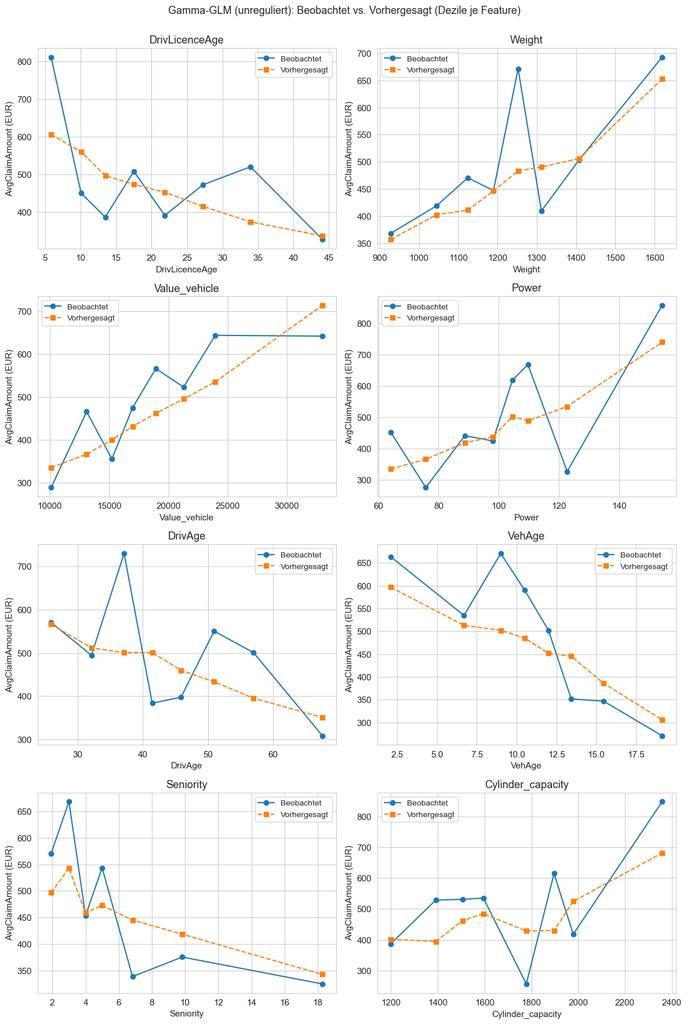

```python
# Vergleich tatsächlicher vs. vorhergesagter Werte je Feature (Dezile)
fig, axes = plt.subplots(4, 2, figsize=(12, 18))

for ax, feat in zip(axes.flat, selected_feats_sev):
    vals = X_sev_val_df[feat].values
    bins = pd.qcut(vals, q=8, duplicates='drop')
    df_plot = pd.DataFrame({'bin': bins,
                            'val': vals,
                            'actual': y_sev_val,
                            'pred': mu_sev_va_glm})
    agg = df_plot.groupby('bin').agg(actual=('actual', 'mean'),
                                      pred=('pred',   'mean'),
                                      val=('val',    'mean'))
    ax.plot(agg['val'].values, agg['actual'].values,
            'o-', label='Beobachtet')
    ax.plot(agg['val'].values, agg['pred'].values,
            's--', label='Vorhergesagt')
    ax.set_title(feat)
    ax.set_xlabel(feat)
    ax.set_ylabel('AvgClaimAmount (EUR)')
    ax.legend(fontsize=10)

plt.suptitle('Gamma-GLM (unreguliert): Beobachtet vs. Vorhergesagt (Dezile je Feature)',
             fontsize=13)
plt.tight_layout(rect=[0, 0, 1, 0.98])
plt.show()
```

**Befund:** Das GLM bildet die globalen Trends gut ab, weicht aber bei mehreren Features systematisch von den beobachteten Werten ab — insbesondere bei DrivAge, Power und Weight zeigen nicht-linearen Verläufe und sind ein Hinweis darauf, dass ein GAM mit flexiblen Splines bessere Anpassung leisten könnte.

### B3 d) GAM (Generalized Additive Model)

Während das GLM in B3 c) lineare Effekte auf der Log-Skala unterstellt, erlaubt das GAM nicht-lineare Verläufe durch Splines:

$$g(\mu_i) = \beta_0 + \sum_j f_j(x_{ij})$$

Die Funktionen $f_j$ sind glatte, datengetriebene penalisierte B-Splines. Der Glättungsparameter $\lambda$ steuert die Balance zwischen Anpassungsgüte und Glattheit — bei großem $\lambda$ degeneriert der Spline zur linearen Funktion, das GAM enthält das GLM also als Spezialfall.

**Modellaufbau:**

Wir verwenden dieselben acht Features wie im GLM. Da alle acht numerisch sind, werden sie einheitlich als Splines `s()` modelliert. Zwei Hyperparameter werden simultan mit Optuna (TPE-Sampler) direkt auf der Validation-Devianz optimiert:

- **`lam`** (Glättungsparameter): Suchraum $[10, 300]$ — Werte unter 10 führen empirisch zu Divergenz des PIRLS-Algorithmus bei diesem Datensatz.
- **`n_splines`** je Feature (Anzahl Basisfunktionen): Suchraum $[4, 10]$ — Untergrenze 4 erhält minimale Flexibilität, Obergrenze 10 verhindert Overfitting bei 3.049 Beobachtungen.

Die in `pygam` eingebaute `gridsearch()`-Methode wurde nicht verwendet, da sie intern den GCV-Score auf den Trainingsdaten optimiert — ein anderes Kriterium als unsere externe Validation-Devianz. Im direkten Vergleich zeigte sich, dass `gridsearch()` ein overfittetes $\lambda$ auswählt.

#### GAM-Modellierung

```python
# Simultane Optimierung: n_splines je Feature + lam
def objective_simultaneous(trial):
    lam = trial.suggest_float('lam', 10.0, 300.0, log=True)
    n_splines_list = [
        trial.suggest_int(f'n_splines_{i}', 4, 10)
        for i in range(len(selected_feats_sev))
    ]
    terms = s(0, n_splines=n_splines_list[0])
    for i in range(1, len(selected_feats_sev)):
        terms = terms + s(i, n_splines=n_splines_list[i])
    try:
        with warnings.catch_warnings():
            warnings.filterwarnings('error')
            model = GammaGAM(terms, lam=lam, max_iter=500)
            model.fit(X_sev_train_df.values, y_sev_train,
                      weights=w_sev_train)
        mu_v  = model.predict(X_sev_val_df.values)
        dev_v = gamma_devianz(y_sev_val, mu_v, w_sev_val)
    except Exception:
        return float('inf')
    if dev_v is None or not np.isfinite(dev_v):
        return float('inf')
    return float(dev_v)

t0 = time.time()
study_simultaneous = optuna.create_study(
    direction='minimize',
    sampler=optuna.samplers.TPESampler(seed=SEED)
)
study_simultaneous.optimize(objective_simultaneous, n_trials=250,
                            show_progress_bar=False)
elapsed_simultaneous = time.time() - t0

best_nsplines_sim = [
    study_simultaneous.best_params[f'n_splines_{i}']
    for i in range(len(selected_feats_sev))
]
best_lam_sim = study_simultaneous.best_params['lam']

print(f'Optimale n_splines je Feature:')
for feat, ns in zip(selected_feats_sev, best_nsplines_sim):
    print(f'  {feat:<20s}: {ns}')
print(f'Optimales lambda:       {best_lam_sim:.4f}')
print(f'Beste Val-Devianz:      {study_simultaneous.best_value:.6f}')
print(f'Erfolgreich konvergiert:{sum(1 for t in study_simultaneous.trials if np.isfinite(t.value))} / {len(study_simultaneous.trials)}')
print(f'Optimierungszeit:       {elapsed_simultaneous:.1f} s')
```

```
Optimale n_splines je Feature:
  DrivLicenceAge      : 6
  Weight              : 5
  Value_vehicle       : 4
  Power               : 5
  DrivAge             : 4
  VehAge              : 9
  Seniority           : 7
  Cylinder_capacity   : 6
Optimales lambda:       16.3810
Beste Val-Devianz:      2.027315
Erfolgreich konvergiert:250 / 250
Optimierungszeit:       24.6 s
```

```python
# Finales GAM mit optimalen Hyperparametern
best_terms = s(0, n_splines=best_nsplines_sim[0])
for i in range(1, len(selected_feats_sev)):
    best_terms = best_terms + s(i, n_splines=best_nsplines_sim[i])

t0 = time.time()
try:
    with warnings.catch_warnings():
        warnings.filterwarnings('error')
        gam_model = GammaGAM(best_terms, lam=best_lam_sim, max_iter=2000)
        gam_model.fit(X_sev_train_df.values, y_sev_train,
                      weights=w_sev_train)
    print('Finales Modell konvergiert.')
except Exception as e:
    print(f'Warnung beim finalen Fit: {e}')
elapsed_gam = time.time() - t0

mu_sev_tr_gam = gam_model.predict(X_sev_train_df.values)
mu_sev_va_gam = gam_model.predict(X_sev_val_df.values)
mu_sev_te_gam = gam_model.predict(X_sev_test_df.values)

d_tr = gamma_devianz(y_sev_train, mu_sev_tr_gam, w_sev_train)
d_va = gamma_devianz(y_sev_val,   mu_sev_va_gam, w_sev_val)
d_te = gamma_devianz(y_sev_test,  mu_sev_te_gam, w_sev_test)

m_tr = mae(y_sev_train, mu_sev_tr_gam, w_sev_train)
m_va = mae(y_sev_val,   mu_sev_va_gam, w_sev_val)
m_te = mae(y_sev_test,  mu_sev_te_gam, w_sev_test)

add_sev_result(f'Gamma-GAM (λ={best_lam_sim:.2f})',
               d_tr, d_va, d_te,
               train_mae=m_tr, val_mae=m_va, test_mae=m_te,
               elapsed=elapsed_gam,
               tuning_time=elapsed_simultaneous)

print_results(results_sev)
```

```
Finales Modell konvergiert.
                                      Modell  Train Gamma-Dev  Val Gamma-Dev  Test Gamma-Dev  Train-Test-Gap  Train MAE  Val MAE  Test MAE  Zeit (s) Tuning Zeit (s)
                                   Gamma-GLM         2.070239       2.057845        2.304599       -0.234360     514.80   502.87    544.93      0.02               -
Gamma-GLM (Elastic Net, α=0.0132, L1=0.0029)         2.071831       2.056106        2.314480       -0.242649     505.06   492.26    534.86      0.43            39.1
                         Gamma-GAM (λ=16.38)         2.042088       2.027315        2.303518       -0.261430     512.35   501.65    546.10      0.08            24.6
```

#### Partial Dependence / Splines der Features

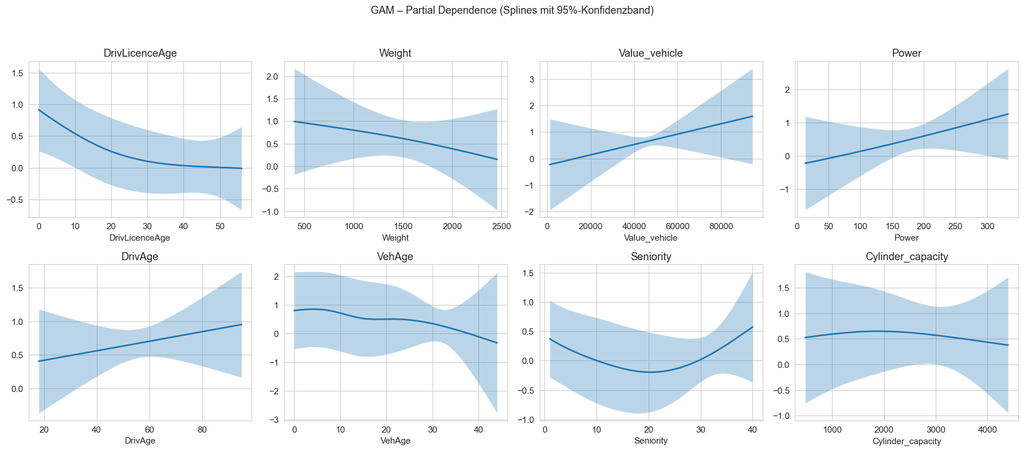

```python
# Partial Dependence / Splines der Features
fig, axes = plt.subplots(2, 4, figsize=(18, 8))
for i, (ax, fname) in enumerate(zip(axes.flat, selected_feats_sev)):
    XX = gam_model.generate_X_grid(term=i)
    pdp, confi = gam_model.partial_dependence(term=i, X=XX, width=0.95)
    ax.plot(XX[:, i], pdp, lw=2)
    ax.fill_between(XX[:, i], confi[:, 0], confi[:, 1], alpha=0.3)
    ax.set_title(fname)
    ax.set_xlabel(fname)
plt.suptitle('GAM – Partial Dependence (Splines mit 95%-Konfidenzband)',
             fontsize=13)
plt.tight_layout(rect=[0, 0, 1, 0.95])
plt.show()
```

**Interpretation nicht-linearer Verläufe**

**2. Seniority — Vertragsdauer:** Der Spline zeigt einen U-förmigen Verlauf mit einem Minimum bei ca. 20 Vertragsjahren. Eine fachliche Interpretation zwischen Vertragsdauer und Schadenhöhe pro Schaden ist schwer zu formulieren. Plausibler ist ein Proxy-Effekt: Seniority korreliert mit Bestandsstruktur und greift Effekte ab, die das additive Modell anderen Features nicht zuordnen kann. Ein GLM mit linearem Seniority-Term würde den anfänglichen Rückgang glätten und den hinteren Verlauf nicht erfassen.

**Einschränkung:** Die Konfidenzbänder sind bei allen Features breit — das starke Rauschen der Schadenhöhen begrenzt die statistische Präzision der Spline-Schätzungen, vorallem an den Rändern liegen meist weniger Beobachtungen, die Konfidenzbänder ausweiten.

#### Warum ist ein GAM einem linearen GLM überlegen?

1. **Nicht-lineare Effekte:** Das GAM schätzt je Feature eine glatte Funktion $f_j(x_j)$ statt eines einzigen Koeffizienten — Verläufe wie U-Formen oder Sättigungseffekte werden direkt abgebildet, ohne manuelle Feature-Transformation.
2. **Keine Vorannahmen über die Funktionsform:** Im GLM müssten Polynome oder Buckets vorab definiert werden. Das GAM lernt die Form datengetrieben.
3. **Interpretierbarkeit bleibt erhalten:** Jeder Spline ist einzeln über Partial-Dependence-Plots interpretierbar — im Gegensatz zu Black-Box-Modellen wie Gradient Boosting. Das verbindet Flexibilität mit regulatorischer Akzeptanz.
4. **GLM als Spezialfall:** Bei sehr großem $\lambda$ degeneriert jeder Spline zur linearen Funktion — das GAM ist damit streng allgemeiner als das GLM.

**Grenze:** Das GAM modelliert additive Effekte. Wechselwirkungen zwischen Features werden ohne expliziten Tensor-Term nicht erfasst.

#### Vergleich der Severity-Modelle

**Modellgüte (Gamma-Devianz):** Das GAM erzielt die beste Validation-Devianz und ist damit dem GLM überlegen — die Splines erfassen Strukturen, die das lineare GLM nicht abbilden kann. Auf dem Testset gleichen sich GLM und GAM jedoch nahezu. Das deutet darauf hin, dass die nicht-linearen Effekte im GAM auf dem Validierungsset leicht überoptimiert wurden.

**Kalibrierung (MAE):** Das regulierte GLM erzielt den besten Test-MAE — die Koeffizientenschrumpfung wirkt stabilisierend auf die absoluten Vorhersagen. Das GAM hat den schlechtesten Test-MAE , obwohl es die beste Devianz aufweist. Das ist konsistent mit dem Befund aus B3 c): Devianz und MAE messen unterschiedliche Aspekte der Vorhersagequalität.

**Empfehlung:** Für die operative Tarifierung empfiehlt sich das **unregulierte Gamma-GLM** als Basismodell — es liefert die beste Balance zwischen Devianz, MAE und Interpretierbarkeit. Das GAM ist wertvoll als diagnostisches Werkzeug, um nicht-lineare Feature-Effekte zu identifizieren, die dann manuell als Transformationen ins GLM einfließen können.

## B4 a) Produktmodell: Frequency × Severity

Das Produktmodell kombiniert das beste Frequency-Modell aus B2 mit dem besten Severity-Modell aus B3:

$$\widehat{PP}_i = \hat{\lambda}_i \times \hat{\mu}^{sev}_i$$

wobei $\hat{\lambda}_i = \hat{\mu}^{freq}_i / w_i$ die vorhergesagte Schadenfrequenz und $\hat{\mu}^{sev}_i$ der vorhergesagte mittlere Schadendurchschnitt ist.

**Frequency-Modell:** XGBoost (niedrigste Test-Devianz aus B2).

**Severity-Modell:** Gemäß Empfehlung in B3 d) wird das unregulierte Gamma-GLM als primäres Severity-Modell verwendet. Da das Gamma-GAM in B3 d) jedoch die beste Validation-Devianz erzielt hat, wird es zusätzlich als Sensitivitätscheck mitgeführt. Beide Produktvarianten werden parallel ausgewertet und verglichen.

**Evaluierungsmetrik:** Tweedie-Devianz mit $p = 1,5$ als vorläufiger Auswertungsmaßstab (Compound-Poisson-Gamma-Annahme, vgl. B4 b). Da die Produktmodelle kein eigenes $p$ schätzen, ist die Vergleichbarkeit mit den in B4 b)–d) optimierten Tweedie-Modellen auf dieser Skala eingeschränkt. Sobald in B4 b) der datengetriebene Power-Parameter feststeht, werden die Produktmodelle in der finalen Vergleichstabelle in B4 f) zusätzlich mit demselben $p$ re-evaluiert, um echte Vergleichbarkeit der Tweedie-Devianzen herzustellen.

```python
# Bestes Frequency-Modell
best_freq_name = df_res.sort_values('Test Devianz').iloc[0]['Modell']
print(f'Bestes Frequency-Modell : {best_freq_name}')
print(f'Test-Devianz (Poisson)  : {df_res.sort_values("Test Devianz").iloc[0]["Test Devianz"]:.6f}')
mu_freq_test = test_predictions[best_freq_name]

# Test-Features für Severity (8 selektierte Features aus B3 c)
X_test_sev_df = pd.DataFrame(X_test, columns=feat_cols)[selected_feats_sev]

# GLM: Benötigt Standardisierung (scaler_sev aus B3 c)) + Konstante
X_test_sev_s = sm.add_constant(scaler_sev.transform(X_test_sev_df))

# Severity-Vorhersagen für alle Test-Beobachtungen (inkl. schadenfreier Policen)
mu_sev_test_glm_all = gamma_glm_res.predict(X_test_sev_s)  # Gamma-GLM
mu_sev_test_gam_all = gam_model.predict(X_test_sev_df.values)  # Gamma-GAM

# Pure Premium = Frequenzrate × Severity
freq_rate_test   = mu_freq_test / np.maximum(exp_test, 1e-10)
pp_prod_glm      = freq_rate_test * mu_sev_test_glm_all
pp_prod_gam      = freq_rate_test * mu_sev_test_gam_all

# Zielvariable
pp_actual = df['Cost_claims_year'].values[idx_test] / np.maximum(exp_test, 1e-10)

# Plausibilitätsprüfung
print(f'\nTest-Beobachtungen      : {len(pp_actual):,}')
print(f'Anteil pp_actual = 0    : {(pp_actual == 0).mean():.1%}')
print(f'pp_actual  – Mean: {pp_actual.mean():.2f}  Max: {pp_actual.max():.2f}')
print(f'pp_prod_glm – Mean: {pp_prod_glm.mean():.2f}  Min: {pp_prod_glm.min():.4f}')
print(f'pp_prod_gam – Mean: {pp_prod_gam.mean():.2f}  Min: {pp_prod_gam.min():.4f}')
```

```
Bestes Frequency-Modell : XGBoost
Test-Devianz (Poisson)  : 160.290493

Test-Beobachtungen      : 3,175
Anteil pp_actual = 0    : 68.4%
pp_actual  – Mean: 588.71  Max: 907899.64
pp_prod_glm – Mean: 311.90  Min: 19.4993
pp_prod_gam – Mean: 309.75  Min: 23.0537
```

```python
# Ergebnisstruktur (wird in B4 b)–e) weitergeführt)
results_pp = []

def add_pp(name, pp_pred, power_used=None, elapsed=None, tuning_time=None,
           pp_pred_train=None, pp_pred_val=None):
    global results_pp
    results_pp = [r for r in results_pp if r['Modell'] != name]
    eval_power = power_used if power_used is not None else 1.5
    te  = mtd(pp_actual + 1e-6, np.maximum(pp_pred, 1e-6), power=eval_power)
    ae  = (pp_pred * exp_test).sum() / np.maximum(
              df['Cost_claims_year'].values[idx_test].sum(), 1e-10)
    tr  = mtd(pp_train + 1e-6, np.maximum(pp_pred_train, 1e-6), power=eval_power) \
          if pp_pred_train is not None else np.nan
    va  = mtd(pp_val + 1e-6, np.maximum(pp_pred_val, 1e-6), power=eval_power) \
          if pp_pred_val is not None else np.nan
    results_pp.append({
        'Modell'          : name,
        'Test power'      : eval_power,
        'Train Tw-Dev'    : round(tr, 3) if not np.isnan(tr) else np.nan,
        'Val Tw-Dev'      : round(va, 3) if not np.isnan(va) else np.nan,
        'Test Tw-Dev'     : round(te, 3),
        'A/E Ratio'       : round(ae, 3),
        'Zeit (s)'        : round(elapsed, 2) if elapsed is not None else np.nan,
        'Tuning Zeit (s)' : round(tuning_time, 1) if tuning_time is not None else '-',
    })

add_pp('Produkt (XGBoost × Gamma-GLM)', pp_prod_glm)
add_pp('Produkt (XGBoost × Gamma-GAM)', pp_prod_gam)
```

**Hinweis zur Evaluierungsmetrik:** Da die Produktmodelle kein eigenes $p$ schätzen, wird für die Tweedie-Devianz $p = 1,5$ als Auswertungsmaßstab verwendet. Die Spalte *Test power* gibt an, mit welchem $p$ die Tweedie-Devianz berechnet wurde — bei optimierten Modellen entspricht dies dem datengetrieben bestimmten $p$. Sobald das beste Tweedie-Modell in B4 b) identifiziert ist, sollte der Wert für die Produktmodelle durch das optimierte $p$ ersetzt werden, um Vergleichbarkeit herzustellen.

#### Ergebnisse und Interpretation

[output not shown]

#### Vor- und Nachteile des Produktmodells vs. direkter Modellierung

**Vorteile des Produktmodells:**

- **Modularität:** Frequency- und Severity-Komponente können unabhängig voneinander weiterentwickelt, validiert und interpretiert werden — in der Praxis ein erheblicher Vorteil für Pricing-Teams.
- **Aktuarielle Interpretierbarkeit:** Die Trennung erleichtert die fachliche Nachvollziehbarkeit der Modellkomponenten gegenüber Aufsicht und Management.
- **Flexibilität der Modellwahl:** Für jede Komponente kann das jeweils geeignete Modell gewählt werden — hier XGBoost für Frequency (zähldatenoptimiert) und Gamma-GLM für Severity (stetige positive Werte).
- **Null-Inflation wird explizit behandelt:** Da das Frequency-Modell Policen ohne Schaden direkt mit λ̂ → 0 gewichtet, entsteht kein Widerspruch zur diskreten Zählnatur.

**Nachteile des Produktmodells:**

- **Fehlerfortpflanzung:** Fehlspezifikationen in einem Teilmodell übertragen sich auf das Gesamtergebnis. Sind Frequency und Severity korreliert (z. B. Großschäden bei bestimmten Fahrzeugklassen), wird diese Struktur durch das Produktmodell nicht erfasst.
- **Unabhängigkeitsannahme:** Das Modell setzt implizit voraus, dass Frequency und Severity bedingt unabhängig sind — eine Annahme, die empirisch nicht immer erfüllt ist.
- **Kein gemeinsamer Optimierungsrahmen:** Die beiden Teilmodelle werden separat geschätzt; eine simultane Optimierung des Schadenbedarfs findet nicht statt. Die direkte Tweedie-Regression in B4 b) optimiert den Pure Premium unmittelbar.
- **Severity nur für N > 0 schätzbar:** Das Gamma-Modell wurde auf Policen mit mindestens einem Schaden trainiert. Die Extrapolation auf schadenfreie Policen (68,4 % des Testsets) erfolgt außerhalb des Trainingsbereichs des Severity-Modells.

### B4 b) Tweedie-Verteilung und GLM mit Tweedie-Verlustfunktion

**Tweedie-Verteilung als Exponentialfamilie**

Die Tweedie-Verteilung ist eine Klasse innerhalb der Exponentialfamilie, die durch den Power-Parameter $p$ parametrisiert wird. Die Varianzfunktion lautet:

$$\text{Var}(Y) = \phi \cdot \mu^p$$

wobei $\mu = \mathbb{E}[Y]$ der Erwartungswert und $\phi > 0$ der Dispersionsparameter ist. Für spezielle Werte von $p$ erhält man bekannte Verteilungen:

| p | Verteilung |
| --- | --- |
| 0 | Normalverteilung |
| 1 | Poisson-Verteilung |
| 2 | Gamma-Verteilung |
| 3 | Inverse Gauß-Verteilung |

**Zusammenhang µ, ϕ, p und Modellgüte**

Die Varianzfunktion $\text{Var}(Y) = \phi \cdot \mu^p$ verbindet alle drei Parameter direkt. $p$ bestimmt, wie die Varianz mit dem Erwartungswert skaliert — ein fehlspezifiziertes $p$ führt dazu, dass das Modell die Varianz bei hohen oder niedrigen $\mu$-Werten systematisch falsch einschätzt. $\phi$ skaliert die Gesamtstreuung relativ zur Modellerwartung: Ein großes $\hat{\phi}$ zeigt an, dass das Modell die beobachtete Streuung nicht vollständig erklärt — entweder weil $p$ fehlspezifiziert ist oder weil relevante Features fehlen. Der Dispersionsparameter wird nach dem Momentschätzer berechnet:

$$\hat{\phi} = \frac{1}{n} \sum_i \frac{(y_i - \hat{\mu}_i)^2}{\hat{\mu}_i^p}$$

```python
# Zielvariable Schadenbedarf
pp_all = np.nan_to_num(
    df['Cost_claims_year'].values / np.maximum(exp_all, 1e-10), nan=0.0
)

# Winsorisierung bei 99,9%-Perzentil: Einzelne Extremschäden destabilisieren
# den Tweedie-Solver (Gradientenexplosion bei sehr großen Zielwerten)
cap_999 = np.quantile(pp_all, 0.999)
pp_all  = np.clip(pp_all, 0, cap_999)

pp_train  = pp_all[idx_train]
pp_val    = pp_all[idx_val]
pp_test_v = pp_all[idx_test]

print(f'Pure Premium gekappt bei 99,9%-Perzentil : {cap_999:.2f} EUR')
print(f'Nullanteil Train                          : {(pp_train == 0).mean():.1%}')
print(f'Mittelwert Train                          : {pp_train.mean():.2f} EUR')
print(f'Standardabweichung Train                  : {pp_train.std():.2f} EUR')
```

```
Pure Premium gekappt bei 99,9%-Perzentil : 21399.73 EUR
Nullanteil Train                          : 68.0%
Mittelwert Train                          : 272.78 EUR
Standardabweichung Train                  : 1148.57 EUR
```

```python
# Standardisierung
# TweedieRegressor (sklearn) konvergiert ohne Standardisierung nicht
scaler_tw = StandardScaler()
X_train_s = scaler_tw.fit_transform(X_train)
X_val_s   = scaler_tw.transform(X_val)
X_test_s  = scaler_tw.transform(X_test)

# Grid Search: power × alpha
powers_tw = np.arange(1.0, 2.0, 0.01).round(2)
alphas_tw = np.logspace(-4, 1, 20).round(6)

print(f'Power-Grid  ({len(powers_tw)} Werte): {list(powers_tw)}')
print(f'Alpha-Grid  ({len(alphas_tw)} Werte): {list(alphas_tw)}')
print(f'Kombinationen gesamt: {len(powers_tw) * len(alphas_tw)}')
print('\nTweedie Grid-Search (mit Standardisierung)...')
t0_grid = time.time()

tw_grid = []
for alpha, power in iproduct(alphas_tw, powers_tw):
    try:
        m = TweedieRegressor(power=power, alpha=alpha, max_iter=300, link='log')
        m.fit(X_train_s, pp_train, sample_weight=exp_train)
        pred_v  = m.predict(X_val_s)
        dv_own  = mtd(pp_val + 1e-6, np.maximum(pred_v, 1e-6), power=power)
        tw_grid.append({
            'alpha'      : alpha,
            'power'      : power,
            'val_dev_own': round(dv_own, 6),
        })
    except Exception:
        tw_grid.append({
            'alpha': alpha, 'power': power, 'val_dev_own': np.inf
        })

elapsed_grid = time.time() - t0_grid
tw_grid_df   = pd.DataFrame(tw_grid)

print(f'Grid-Search abgeschlossen in {elapsed_grid:.1f} s\n')
print('Top 10 Kombinationen (sortiert nach val_dev_own):')
print(tw_grid_df.sort_values('val_dev_own').head(10).to_string(index=False))
```

```
Power-Grid  (100 Werte): [1.0, 1.01, 1.02, 1.03, 1.04, 1.05, 1.06, 1.07, 1.08, 1.09, 1.1, 1.11, 1.12, 1.13, 1.14, 1.15, 1.16, 1.17, 1.18, 1.19, 1.2, 1.21, 1.22, 1.23, 1.24, 1.25, 1.26, 1.27, 1.28, 1.29, 1.3, 1.31, 1.32, 1.33, 1.34, 1.35, 1.36, 1.37, 1.38, 1.39, 1.4, 1.41, 1.42, 1.43, 1.44, 1.45, 1.4…
Alpha-Grid  (20 Werte): [0.0001, 0.000183, 0.000336, 0.000616, 0.001129, 0.002069, 0.003793, 0.006952, 0.012743, 0.023357, 0.042813, 0.078476, 0.143845, 0.263665, 0.483293, 0.885867, 1.623777, 2.976351, 5.455595, 10.0]
Kombinationen gesamt: 2000

Tweedie Grid-Search (mit Standardisierung)...
Grid-Search abgeschlossen in 9.5 s

Top 10 Kombinationen (sortiert nach val_dev_own):
   alpha  power  val_dev_own
0.023357   1.89    21.495848
0.012743   1.89    21.495851
0.006952   1.89    21.495885
0.003793   1.89    21.495969
0.000183   1.89    21.495972
0.000100   1.89    21.495975
0.002069   1.89    21.495978
0.001129   1.89    21.495991
0.000616   1.89    21.496005
0.000336   1.89    21.496013
```

```python
# Bestes Modell
best_tw = tw_grid_df.sort_values('val_dev_own').iloc[0]
best_power = best_tw['power']
best_alpha = best_tw['alpha']
print(f'Optimales power : {best_power}')
print(f'Optimales alpha : {best_alpha}')
```

```
Optimales power : 1.89
Optimales alpha : 0.023357
```

```python
# Baseline-Modell (alpha=0, power=1,5 als Referenzpunkt)
t0 = time.time()
tw_base = TweedieRegressor(power=1.5, alpha=0.0, max_iter=300, link='log')
tw_base.fit(X_train_s, pp_train, sample_weight=exp_train)
elapsed_base = time.time() - t0

pp_base_test = tw_base.predict(X_test_s)
add_pp('Tweedie-GLM Baseline (α=0)',
       pp_base_test,
       power_used=1.5,
       elapsed=elapsed_base,
       pp_pred_train=tw_base.predict(X_train_s),
       pp_pred_val=tw_base.predict(X_val_s))

# Optimiertes Modell
t0 = time.time()
tw_opt = TweedieRegressor(power=best_power, alpha=best_alpha,
                          max_iter=300, link='log')
tw_opt.fit(X_train_s, pp_train, sample_weight=exp_train)
elapsed_opt = time.time() - t0

pp_tw_opt_test = tw_opt.predict(X_test_s)
add_pp(f'Tweedie-GLM Opt (α={best_alpha})',
       pp_tw_opt_test,
       power_used=best_power,
       elapsed=elapsed_opt,
       tuning_time=elapsed_grid,
       pp_pred_train=tw_opt.predict(X_train_s),
       pp_pred_val=tw_opt.predict(X_val_s))

# Dispersionsparameter
pp_tw_train_pred = tw_opt.predict(X_train_s)
phi_est = np.mean(
    (pp_train - pp_tw_train_pred)**2 /
    np.maximum(pp_tw_train_pred**best_power, 1e-10)
)
print(f'\nDispersionsparameter φ̂ (power={best_power}) : {phi_est:.4f}')
print(f'\nErgebnistabelle (kumuliert):')
print(pd.DataFrame(results_pp).to_string(index=False))
```

```
Dispersionsparameter φ̂ (power=1.89) : 32.1072

Ergebnistabelle (kumuliert):
                       Modell  Test power  Train Tw-Dev  Val Tw-Dev  Test Tw-Dev  A/E Ratio  Zeit (s) Tuning Zeit (s)
Produkt (XGBoost × Gamma-GLM)        1.50           NaN         NaN      113.087      0.972       NaN               -
Produkt (XGBoost × Gamma-GAM)        1.50           NaN         NaN      113.060      0.963       NaN               -
   Tweedie-GLM Baseline (α=0)        1.50        69.942      70.572      129.864      0.822       0.0               -
 Tweedie-GLM Opt (α=0.023357)        1.89        21.888      21.496       25.383      0.824       0.0             9.5
```

#### Ergebnisse und Interpretation

**Grid Search:** Das optimale Modell verwendet $p = 1,89$ und $\alpha = 0,023357$. Der Power-Parameter nahe 2,0 deutet darauf hin, dass die Varianz des Schadenbedarfs nahezu quadratisch mit dem Erwartungswert skaliert — ähnlich einer Gamma-Verteilung, jedoch mit expliziter Modellierung der Nullwerte.

**Modellgüte:** Da Baseline ($p=1,5$) und optimiertes Modell ($p=1,89$) auf unterschiedlichen Skalen gemessen werden, sind die Tweedie-Devianzen nicht direkt vergleichbar. Innerhalb des optimierten Modells ist der Train-Test-Gap mit $25,38 - 21,89 = 3,49$ gering — das Modell generalisiert gut. Beim Baseline-Modell ist der Gap mit $129,86 - 69,94 = 59,92$ deutlich größer, was auf eine Fehlspezifikation von $p$ hindeutet: $p=1,5$ beschreibt die Varianzstruktur dieses Datensatzes schlechter.

**Dispersionsparameter:** $\hat{\phi} = 32,11$ ist hoch. Das bedeutet, dass das Modell die beobachtete Streuung des Schadenbedarfs nicht vollständig erklärt — was bei einem Nullanteil von 68,4 % und einzelnen Extremschäden (gekappt bei 99,9%-Perzentil) erwartbar ist.

**Globale Kalibrierung (A/E-Ratio):** Beide Tweedie-GLM-Modelle unterschätzen den Gesamtschadenbedarf um ca. 18 % (A/E ≈ 0,82), während die Produktmodelle aus B4 a) mit A/E ≈ 0,96–0,97 deutlich besser kalibriert sind. Eine Rekalibrierung des Tweedie-GLM durch einen Intercept-Shift wäre für den praktischen Einsatz zu empfehlen.

### B4 c) LightGBM mit Tweedie-Objective

#### Warum können GBMs komplexere Interaktionen erfassen als GLMs?

Ein GLM modelliert den Erwartungswert als additive Funktion der Features auf der Link-Skala — Interaktionen zwischen Features müssen manuell als Kreuzterme spezifiziert werden. LightGBM hingegen baut sequenziell Entscheidungsbäume, die bei jedem Split eine Kombination mehrerer Features berücksichtigen. Dadurch werden Interaktionen beliebiger Ordnung automatisch und datengetrieben erfasst, ohne dass sie vorab bekannt sein müssen. Zusätzlich sind baumbasierte Modelle invariant gegenüber monotonen Feature-Transformationen und erfordern keine Standardisierung.

#### Overfitting-Risiken bei GBMs

GBMs haben durch ihre hohe Modellkapazität ein inhärent hohes Overfitting-Risiko. Jeder zusätzliche Baum reduziert den Trainingsfehler, kann aber den Generalisierungsfehler erhöhen. Besonders kritisch sind zu viele Bäume (`n_estimators`) in Kombination mit einer hohen Lernrate (`learning_rate`) und tiefen Bäumen (`num_leaves`). Im Versicherungskontext kommt hinzu, dass Overfitting zu nicht-monotonen oder aktuariell unplausiblen Tarifverläufen führen kann — weshalb Monotoniebeschränkungen wie in B2 c) sinnvoll sind.

```python
def lgb_tw_objective(trial):
    power = trial.suggest_float('power', 1.0, 1.99)
    params = dict(
        objective              = 'tweedie',
        tweedie_variance_power = power,
        learning_rate = trial.suggest_float('learning_rate', 0.01, 0.3, log=True),
        num_leaves    = trial.suggest_int('num_leaves', 20, 150),
        n_estimators  = trial.suggest_int('n_estimators', 100, 600),
        min_child_samples      = 100,
        random_state=SEED, verbose=-1, n_jobs=-1
    )
    m = lgb.LGBMRegressor(**params)
    m.fit(X_train, pp_train,
          sample_weight=exp_train,
          eval_set=[(X_val, pp_val)],
          callbacks=[lgb.early_stopping(50, verbose=False),
                     lgb.log_evaluation(-1)])
    pred_v = m.predict(X_val)
    return mtd(pp_val + 1e-6, np.maximum(pred_v, 1e-6), power=power)

t0_opt = time.time()
study_lgb_tw = optuna.create_study(
    direction='minimize',
    sampler=optuna.samplers.TPESampler(seed=SEED)
)
study_lgb_tw.optimize(lgb_tw_objective, n_trials=150, show_progress_bar=False)
elapsed_lgb_tw_opt = time.time() - t0_opt

print(f'LightGBM Tweedie Optimierung: {len(study_lgb_tw.trials)} Trials, '
      f'{elapsed_lgb_tw_opt:.1f} s')
print(f'Beste Val-Devianz : {study_lgb_tw.best_value:.6f}')
print(f'Beste Parameter   : {study_lgb_tw.best_params}')
```

```
LightGBM Tweedie Optimierung: 150 Trials, 12.1 s
Beste Val-Devianz : 21.701157
Beste Parameter   : {'power': 1.8982986707919627, 'learning_rate': 0.01208612668652018, 'num_leaves': 28, 'n_estimators': 192}
```

**Hinweis:** Die Aufgabenstellung schreibt das Hyperparameter-Tuning für `tweedie_variance_power`, `learning_rate`, `num_leaves` und `n_estimators` vor. Weitere Parameter wie `min_child_samples` wurden daher nicht optimiert, obwohl dieser im Versicherungskontext einen wesentlichen Einfluss auf die Modellgüte haben kann, da er die Mindestanzahl an Beobachtungen pro Blatt kontrolliert und damit stabile Tarifzellen gewährleistet.

```python
# Finales LightGBM Tweedie-Modell
bp = study_lgb_tw.best_params
best_lgb_tw_power = bp['power']

t0 = time.time()
lgb_tw = lgb.LGBMRegressor(
    objective              = 'tweedie',
    tweedie_variance_power = best_lgb_tw_power,
    learning_rate          = bp['learning_rate'],
    num_leaves             = bp['num_leaves'],
    n_estimators           = bp['n_estimators'],
    min_child_samples      = 100,          # manuell fix gegen Overfitting
    random_state=SEED, verbose=-1, n_jobs=-1
)
lgb_tw.fit(X_train, pp_train, sample_weight=exp_train)
elapsed_lgb_tw = time.time() - t0

pp_lgb_tw_train = lgb_tw.predict(X_train)
pp_lgb_tw_val   = lgb_tw.predict(X_val)
pp_lgb_tw_test  = lgb_tw.predict(X_test)

add_pp('LightGBM Tweedie',
       pp_lgb_tw_test,
       power_used    = round(best_lgb_tw_power, 4),
       elapsed       = elapsed_lgb_tw,
       tuning_time   = elapsed_lgb_tw_opt,
       pp_pred_train = pp_lgb_tw_train,
       pp_pred_val   = pp_lgb_tw_val)

print('\nErgebnistabelle:')
print(pd.DataFrame(results_pp).to_string(index=False))
```

```
Ergebnistabelle:
                       Modell  Test power  Train Tw-Dev  Val Tw-Dev  Test Tw-Dev  A/E Ratio  Zeit (s) Tuning Zeit (s)
Produkt (XGBoost × Gamma-GLM)      1.5000           NaN         NaN      113.087      0.972       NaN               -
Produkt (XGBoost × Gamma-GAM)      1.5000           NaN         NaN      113.060      0.963       NaN               -
   Tweedie-GLM Baseline (α=0)      1.5000        69.942      70.572      129.864      0.822      0.00               -
 Tweedie-GLM Opt (α=0.023357)      1.8900        21.888      21.496       25.383      0.824      0.00             9.5
             LightGBM Tweedie      1.8983        20.756      21.908       25.122      0.642      0.12            12.1
```

#### Ergebnisse und Interpretation

**Modellgüte:** LightGBM erreicht mit Test-Tw-Dev = 25,12 eine marginal bessere Vorhersagegüte als das optimierte Tweedie-GLM (25,38). Der Train-Test-Gap liegt bei beiden Modellen in vergleichbarer Größenordnung (LightGBM: 4,37, GLM: 3,50), was nach der manuellen Anpassung von `min_child_samples` auf eine ausreichend stabile Generalisierung hindeutet.

**Stabilität:** In Voranalysen ohne Mindestgröße pro Blatt wies LightGBM extremes Overfitting auf (Val-Devianz mehrere Größenordnungen über der Train-Devianz). Die manuelle Festsetzung von `min_child_samples = 100` war daher zwingend erforderlich, um aktuariell belastbare Tarifzellen zu erzeugen.

**Globale Kalibrierung (A/E-Ratio):** LightGBM unterschätzt den Gesamtschadenbedarf um ca. 36 % (A/E = 0,642) und ist damit deutlich schlechter kalibriert als die Tweedie-GLMs (≈ 0,82) und die Produktmodelle aus B4 a) (≈ 0,96). Dies ist ein bekannter Effekt baumbasierter Modelle mit Tweedie-Objective: Die Mittelwertstruktur wird auf der Log-Skala gut erfasst, aber die globale Summe systematisch unterschätzt. Vor dem operativen Einsatz wäre eine Rekalibrierung erforderlich, etwa durch einen multiplikativen Korrekturfaktor.

### B4 d) XGBoost mit Tweedie-Objective

Analog zu B4 c) wird XGBoost mit der Tweedie-Verlustfunktion trainiert. Im Unterschied zu LightGBM wird statt `num_leaves` der Parameter `max_depth` getuned — XGBoost wächst Bäume standardmäßig level-wise und steuert die Komplexität über die Tiefe.

```python
# XGBoost mit Tweedie-Objective
def xgb_tw_objective(trial):
    power = trial.suggest_float('power', 1.0, 1.99)
    params = dict(
        objective              = 'reg:tweedie',
        tweedie_variance_power = power,
        learning_rate          = trial.suggest_float('learning_rate', 0.01, 0.3, log=True),
        max_depth              = trial.suggest_int('max_depth', 2, 8),
        n_estimators           = trial.suggest_int('n_estimators', 100, 600),
        min_child_weight       = 100,
        random_state=SEED, verbosity=0, n_jobs=-1,
        eval_metric='tweedie-nloglik@' + str(power),
        early_stopping_rounds=30
    )
    m = xgb.XGBRegressor(**params)
    m.fit(X_train, pp_train,
          sample_weight=exp_train,
          eval_set=[(X_val, pp_val)],
          verbose=False)
    pred_v = m.predict(X_val)
    return mtd(pp_val + 1e-6, np.maximum(pred_v, 1e-6), power=power)

t0_opt = time.time()
study_xgb_tw = optuna.create_study(
    direction='minimize',
    sampler=optuna.samplers.TPESampler(seed=SEED)
)
study_xgb_tw.optimize(xgb_tw_objective, n_trials=150, show_progress_bar=False)
elapsed_xgb_tw_opt = time.time() - t0_opt

print(f'XGBoost Tweedie Optimierung: {len(study_xgb_tw.trials)} Trials, '
      f'{elapsed_xgb_tw_opt:.1f} s')
print(f'Beste Val-Devianz : {study_xgb_tw.best_value:.6f}')
print(f'Beste Parameter   : {study_xgb_tw.best_params}')
```

```
XGBoost Tweedie Optimierung: 150 Trials, 9.1 s
Beste Val-Devianz : 21.550709
Beste Parameter   : {'power': 1.8916355898070312, 'learning_rate': 0.08133210367731472, 'max_depth': 3, 'n_estimators': 497}
```

**Hinweis:** Die Aufgabenstellung schreibt das Hyperparameter-Tuning explizit für `tweedie_variance_power`, `learning_rate`, `max_depth` und `n_estimators` vor. Weitere Parameter wie `min_child_weight` (XGBoost-Pendant zu `min_child_samples`) wurden nicht optimiert, aber manuell auf 100 fixiert, um Overfitting durch zu kleine Tarifzellen zu verhindern — analog zur Konfiguration in B4 c).

```python
# Finales XGBoost Tweedie-Modell
bp = study_xgb_tw.best_params
best_xgb_tw_power = bp['power']

t0 = time.time()
xgb_tw = xgb.XGBRegressor(
    objective              = 'reg:tweedie',
    tweedie_variance_power = best_xgb_tw_power,
    learning_rate          = bp['learning_rate'],
    max_depth              = bp['max_depth'],
    n_estimators           = bp['n_estimators'],
    min_child_weight       = 100,
    random_state=SEED, verbosity=0, n_jobs=-1
)
xgb_tw.fit(X_train, pp_train, sample_weight=exp_train)
elapsed_xgb_tw = time.time() - t0

pp_xgb_tw_train = xgb_tw.predict(X_train)
pp_xgb_tw_val   = xgb_tw.predict(X_val)
pp_xgb_tw_test  = xgb_tw.predict(X_test)

add_pp('XGBoost Tweedie',
       pp_xgb_tw_test,
       power_used    = round(best_xgb_tw_power, 4),
       elapsed       = elapsed_xgb_tw,
       tuning_time   = elapsed_xgb_tw_opt,
       pp_pred_train = pp_xgb_tw_train,
       pp_pred_val   = pp_xgb_tw_val)

print('\nErgebnistabelle (kumuliert):')
print(pd.DataFrame(results_pp).to_string(index=False))
```

```
Ergebnistabelle (kumuliert):
                       Modell  Test power  Train Tw-Dev  Val Tw-Dev  Test Tw-Dev  A/E Ratio  Zeit (s) Tuning Zeit (s)
Produkt (XGBoost × Gamma-GLM)      1.5000           NaN         NaN      113.087      0.972       NaN               -
Produkt (XGBoost × Gamma-GAM)      1.5000           NaN         NaN      113.060      0.963       NaN               -
   Tweedie-GLM Baseline (α=0)      1.5000        69.942      70.572      129.864      0.822      0.00               -
 Tweedie-GLM Opt (α=0.023357)      1.8900        21.888      21.496       25.383      0.824      0.00             9.5
             LightGBM Tweedie      1.8983        20.756      21.908       25.122      0.642      0.12            12.1
              XGBoost Tweedie      1.8916        20.064      22.503       26.294      0.615      0.15             9.1
```

#### Ergebnisse und Interpretation

**Modellgüte:** XGBoost erreicht mit Test-Tw-Dev = 26,29 eine vergleichbare, leicht schlechtere Vorhersagegüte als LightGBM (25,12) und das optimierte Tweedie-GLM (25,38). Der optimale Power-Parameter liegt mit 1,89 in derselben Größenordnung wie bei den anderen optimierten Modellen, was die Konsistenz der Varianzstruktur bestätigt.

**Generalisierung:** Der Train-Test-Gap ist mit 6,23 etwas größer als bei LightGBM (4,37), das Modell zeigt damit eine leicht stärkere Anpassung an die Trainingsdaten. Die Festsetzung von `min_child_weight = 100` hält das Overfitting jedoch in einem aktuariell vertretbaren Rahmen.

**Globale Kalibrierung (A/E-Ratio):** Wie bei LightGBM zeigt sich auch hier eine deutliche Unterschätzung des Gesamtschadenbedarfs (A/E = 0,615, ca. 38 % zu niedrig). Das Phänomen ist konsistent zwischen beiden GBM-Implementierungen und bestätigt, dass es sich um ein strukturelles Problem der Tweedie-Optimierung in baumbasierten Modellen handelt, nicht um eine implementierungsspezifische Eigenheit. Eine Rekalibrierung wäre vor dem operativen Einsatz erforderlich.

### B4 e) Kalibrierung und Ranking-Qualität

#### Lorenz-Kurven und Gini-Index

Die Lorenz-Kurve zeigt den kumulierten Anteil der tatsächlichen Schäden (y-Achse) als Funktion des kumulierten Exposure-Anteils, sortiert aufsteigend nach vorhergesagtem Schadenbedarf (x-Achse). Ein perfektes Modell (Orakel) konzentriert die Schäden vollständig in den höchsten Risikodezilen — die Kurve liegt weit unterhalb der Diagonalen. Eine zufällige Sortierung entspricht der Diagonalen.

Der Gini-Index quantifiziert die Fläche zwischen Lorenz-Kurve und Diagonale: $G = 2 \cdot \int (F_{\text{Exp}} - F_{\text{Schaden}}) \, dF_{\text{Exp}}$. Werte nahe 0 zeigen keine Risikodifferenzierung, Werte nahe 1 stehen für perfektes Ranking.

Als bestes Tweedie-Modell wird das **Tweedie-GLM Opt** ausgewählt. Zwar erreicht LightGBM eine marginal niedrigere Test-Tweedie-Devianz, jedoch unterschätzt es den Gesamtschadenbedarf systematisch um 36 % (A/E = 0,642). Das Tweedie-GLM Opt ist mit A/E = 0,824 deutlich besser kalibriert und damit für den Modellvergleich aussagekräftiger.

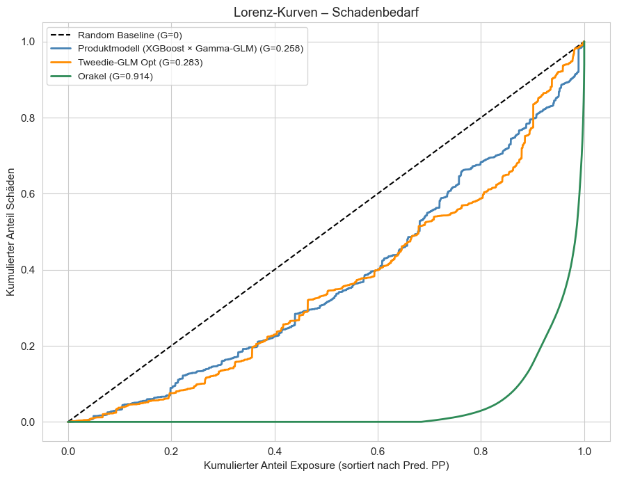

```python
# Lorenz-Kurve und Gini-Index
def lorenz_curve(y_true, y_pred, weights):
    """
    Lorenz-Kurve für den Schadenbedarf:
    - Sortierung aufsteigend nach vorhergesagtem Pure Premium
    - x-Achse: Kumulierter Exposure-Anteil
    - y-Achse: Kumulierter Schadenanteil
    """
    order = np.argsort(y_pred)
    cum_w = np.cumsum(weights[order]) / weights.sum()
    cum_y = np.cumsum(y_true[order]) / y_true.sum()
    return np.concatenate([[0], cum_w]), np.concatenate([[0], cum_y])

def gini_index(cum_w, cum_y):
    """
    Gini-Index als doppelte Fläche zwischen Lorenz-Kurve und Diagonale.
    Bei aufsteigender Sortierung liegt die Lorenz-Kurve unterhalb der Diagonalen
    → höhere Werte = bessere Risikodifferenzierung. Orakel liefert den Maximalwert.
    """
    return 2 * np.trapz(cum_w - cum_y, cum_w)

# Modellauswahl
cost_test  = df['Cost_claims_year'].values[idx_test]
exp_test_v = exp_test
pp_oracle  = cost_test / np.maximum(exp_test_v, 1e-10)

plot_models = {
    'Produktmodell (XGBoost × Gamma-GLM)': pp_prod_glm,
    'Tweedie-GLM Opt'                    : pp_tw_opt_test,
    'Orakel'                             : pp_oracle,
}

colors = {'Produktmodell (XGBoost × Gamma-GLM)': 'steelblue',
          'Tweedie-GLM Opt'                    : 'darkorange',
          'Orakel'                             : 'seagreen'}

# Plot
fig, ax = plt.subplots(figsize=(9, 7))
ax.plot([0, 1], [0, 1], 'k--', label='Random Baseline (G=0)')

ginis = {}
for name, pp in plot_models.items():
    cx, cy = lorenz_curve(cost_test, pp, exp_test_v)
    g      = gini_index(cx, cy)
    ginis[name] = g
    ax.plot(cx, cy, lw=2, color=colors[name], label=f'{name} (G={g:.3f})')

ax.set_xlabel('Kumulierter Anteil Exposure (sortiert nach Pred. PP)')
ax.set_ylabel('Kumulierter Anteil Schäden')
ax.set_title('Lorenz-Kurven – Schadenbedarf')
ax.legend(loc='upper left', fontsize=10)
plt.tight_layout()
plt.show()
```

```python
# Balance Property
print('Balance Property: Σ(Predicted PP × Exposure) / Σ(Actual Cost)')
print('-' * 72)
for name, pp in plot_models.items():
    balance = (pp * exp_test_v).sum() / np.maximum(cost_test.sum(), 1e-10)
    deviation = (balance - 1.0) * 100
    print(f'  {name:45s} {balance:.4f}  ({deviation:+.2f} %)')

print('\nGini-Index Übersicht:')
print('-' * 72)
for name, g in ginis.items():
    print(f'  {name:45s} G = {g:.4f}')
```

```
Balance Property: Σ(Predicted PP × Exposure) / Σ(Actual Cost)
------------------------------------------------------------------------
  Produktmodell (XGBoost × Gamma-GLM)           0.9717  (-2.83 %)
  Tweedie-GLM Opt                               0.8235  (-17.65 %)
  Orakel                                        1.0000  (+0.00 %)

Gini-Index Übersicht:
------------------------------------------------------------------------
  Produktmodell (XGBoost × Gamma-GLM)           G = 0.2577
  Tweedie-GLM Opt                               G = 0.2834
  Orakel                                        G = 0.9138
```

#### Ergebnisse und Interpretation

**Ranking-Qualität (Gini-Index):** Beide Modelle liegen mit Gini-Werten von 0,26 (Produktmodell) und 0,28 (Tweedie-GLM Opt) deutlich über der Random Baseline (G = 0), aber weit entfernt vom Orakel (G = 0,91). Das Tweedie-GLM Opt erreicht eine marginal bessere Risikodifferenzierung. Beide Lorenz-Kurven verlaufen nahezu parallel und zeigen die typische konvexe Form: Die untersten Risikodezile tragen kaum zum Gesamtschaden bei, während die obersten Dezile den größten Teil der Schäden konzentrieren.

**Vergleich der beiden Modelle:** Das Tweedie-GLM Opt hat zwar einen leicht höheren Gini-Index, liegt aber bei der Kalibrierung deutlich zurück. Das Produktmodell bietet die bessere Gesamtbalance: Nahezu identische Ranking-Qualität bei wesentlich besserer Auskömmlichkeit. Die Trennung von Frequency und Severity erlaubt es offenbar, den Gesamtschadenbedarf realistischer zu schätzen, während die direkte Tweedie-Optimierung systematisch zu niedrige Werte erzeugt.

#### Ranking-Qualität (Gini) vs. Kalibrierung — was ist wichtiger?

Beide Eigenschaften messen unterschiedliche Aspekte der Modellgüte und sind in der Versicherungstarifierung beide relevant. Welche Eigenschaft wichtiger ist, hängt vom Anwendungszweck ab.

Ein hoher Gini-Index zeigt, dass das Modell Hochrisiko- und Niedrigrisiko-Policen gut voneinander trennt. Das ist entscheidend für die individuelle Tarifgestaltung: Nur wenn die relative Risikoordnung korrekt ist, zahlen Hochrisiko-Kunden tatsächlich höhere Beiträge als Niedrigrisiko-Kunden. Eine schlechte Ranking-Qualität führt zu Antiselektion — gute Risiken wandern zur Konkurrenz ab, schlechte Risiken bleiben.

Eine gute Kalibrierung (A/E ≈ 1) ist hingegen entscheidend für die Auskömmlichkeit des Gesamtportfolios. Ein Modell mit perfektem Ranking, aber systematischer Unterschätzung um 30 %, würde zwar fair zwischen Kunden differenzieren, aber das Versicherungskollektiv wäre nicht ausreichend finanziert.

In der Praxis lässt sich Kalibrierung durch einen einfachen multiplikativen Korrekturfaktor nachträglich herstellen, ohne die Ranking-Qualität zu verändern. Ranking-Qualität hingegen ist eine strukturelle Modelleigenschaft, die sich nicht im Nachhinein verbessern lässt.

Generell wäre einem Modell mit besserer Ranking-Qualität daher der Vorzug zu geben. Im konkreten Modellvergleich dieses Datensatzes liegen die Gini-Werte allerdings sehr eng beieinander (0.26–0.28), während die Kalibrierungsunterschiede dramatisch sind (A/E 0.62–0.97). In dieser Situation überwiegt die praktische Bedeutung der Kalibrierung — was sich auch in der Empfehlung pro Produktmodell in B4 f) widerspiegelt.

### B4 f) Modellvergleich und Empfehlung

#### Re-Evaluierung der Produktmodelle und Modellvergleich

Wie in B4 a) angekündigt, werden die Produktmodelle hier zusätzlich mit dem datengetriebenen Power-Parameter $p \approx 1,89$ aus B4 b) re-evaluiert. Hintergrund: Die Tweedie-Devianz ist nur bei identischem $p$ direkt vergleichbar — die ursprüngliche Auswertung der Produktmodelle mit $p = 1,5$ liegt auf einer anderen Skala als die optimierten Tweedie-GLM/GBM-Modelle. Durch die zusätzliche Auswertung mit $p = 1,89$ entsteht eine direkte Vergleichsbasis. Die ursprünglichen $p = 1,5$-Einträge bleiben in der Tabelle erhalten, um den Bezug zur Compound-Poisson-Gamma-Standardannahme nicht zu verlieren.

```python
# Re-Evaluation der Produktmodelle mit p≈1,89
P_FINAL = round(best_power, 2)

for orig_name, pp in [('Produkt (XGBoost × Gamma-GLM)', pp_prod_glm),
                      ('Produkt (XGBoost × Gamma-GAM)', pp_prod_gam)]:
    new_name = f'{orig_name} [p={P_FINAL}]'
    te = mtd(pp_actual + 1e-6, np.maximum(pp + 1e-6, 1e-6), power=P_FINAL)
    ae = (pp * exp_test).sum() / np.maximum(
        df['Cost_claims_year'].values[idx_test].sum(), 1e-10)

    results_pp.append({
        'Modell'         : new_name,
        'Test power'     : P_FINAL,
        'Train Tw-Dev'   : np.nan,
        'Val Tw-Dev'     : np.nan,
        'Test Tw-Dev'    : round(te, 3),
        'A/E Ratio'      : round(ae, 3),
        'Zeit (s)'       : np.nan,
        'Tuning Zeit (s)': '-',
    })

# Vergleichstabelle aller Pure-Premium-Modelle
df_pp_res = pd.DataFrame(results_pp)
print('Pure-Premium-Modelle — Vergleich:')
print('-' * 100)
print(df_pp_res.sort_values('Test Tw-Dev').to_string(index=False))
```

```
Pure-Premium-Modelle — Vergleich:
----------------------------------------------------------------------------------------------------
                                Modell  Test power  Train Tw-Dev  Val Tw-Dev  Test Tw-Dev  A/E Ratio  Zeit (s) Tuning Zeit (s)
Produkt (XGBoost × Gamma-GLM) [p=1.89]      1.8900           NaN         NaN       24.089      0.972       NaN               -
Produkt (XGBoost × Gamma-GAM) [p=1.89]      1.8900           NaN         NaN       24.099      0.963       NaN               -
                      LightGBM Tweedie      1.8983        20.756      21.908       25.122      0.642      0.12            12.1
          Tweedie-GLM Opt (α=0.023357)      1.8900        21.888      21.496       25.383      0.824      0.00             9.5
                       XGBoost Tweedie      1.8916        20.064      22.503       26.294      0.615      0.15             9.1
         Produkt (XGBoost × Gamma-GAM)      1.5000           NaN         NaN      113.060      0.963       NaN               -
         Produkt (XGBoost × Gamma-GLM)      1.5000           NaN         NaN      113.087      0.972       NaN               -
            Tweedie-GLM Baseline (α=0)      1.5000        69.942      70.572      129.864      0.822      0.00               -
```

```python
# Gini-Index für alle Modelle ergänzen
all_pp_models = {
    'Produkt (XGBoost × Gamma-GLM)' : pp_prod_glm,
    'Produkt (XGBoost × Gamma-GAM)' : pp_prod_gam,
    'Tweedie-GLM Baseline'          : pp_base_test,
    'Tweedie-GLM Opt'               : pp_tw_opt_test,
    'LightGBM Tweedie'              : pp_lgb_tw_test,
    'XGBoost Tweedie'               : pp_xgb_tw_test,
}

print('Gini-Index aller Modelle:')
print('-' * 60)
for name, pp in all_pp_models.items():
    cx, cy = lorenz_curve(cost_test, pp, exp_test_v)
    g      = gini_index(cx, cy)
    print(f'  {name:40s} G = {g:.4f}')
```

```
Gini-Index aller Modelle:
------------------------------------------------------------
  Produkt (XGBoost × Gamma-GLM)            G = 0.2577
  Produkt (XGBoost × Gamma-GAM)            G = 0.2692
  Tweedie-GLM Baseline                     G = 0.2813
  Tweedie-GLM Opt                          G = 0.2834
  LightGBM Tweedie                         G = 0.2748
  XGBoost Tweedie                          G = 0.2592
```

#### Modellempfehlung für die Praxis

**Vorhersagegenauigkeit (Tweedie-Devianz auf gleicher Skala, $p = 1,89$):** Die beiden Produktvarianten führen das Ranking an (24,09 GLM, 24,10 GAM), gefolgt von LightGBM Tweedie (25,12, $p = 1,8983$). Direkt vergleichbar bei identischem $p = 1,89$ ist nur das Tweedie-GLM Opt — der Devianz-Vorsprung des Produkt-GLM beträgt hier rund 1,3 Punkte. Gegenüber den GBM-Modellen liegen marginale Skalenabweichungen vor ($p$ unterscheidet sich in der zweiten Nachkommastelle), das Ranking ist davon aber unberührt.

**Globale Kalibrierung (A/E):** Hier zeigen sich die deutlichsten Unterschiede. Die Produktmodelle sind mit A/E ≈ 0,96–0,97 nahezu perfekt kalibriert, das Tweedie-GLM Opt unterschätzt um ca. 18 %, die GBM-Modelle (LightGBM, XGBoost) sogar um 36–39 %. Die direkte Tweedie-Optimierung in baumbasierten Modellen führt strukturell zu einer Unterschätzung des Gesamtschadens — ein bekanntes Phänomen, das vor dem operativen Einsatz eine Rekalibrierung erfordern würde.

**Interpretierbarkeit:** Das Produktmodell hat den methodischen Vorteil, dass Frequency und Severity getrennt validierbar sind und die Komponenten einzeln gegen aktuarielle Plausibilität geprüft werden können. Tweedie-GLM-Modelle sind über ihre Koeffizienten direkt als multiplikative Tarifrelativitäten lesbar. Baumbasierte Tweedie-Modelle (LightGBM, XGBoost) erfordern Partial-Dependence-Plots oder SHAP-Werte zur Interpretation.

**Trainingszeit:** Auf diesem Datensatz spielt die Trainingszeit keine Rolle — alle Modelle trainieren in unter einer Sekunde, die Optuna-Suchen in 9–12 Sekunden.

**Versicherungstechnische Plausibilität:** Das Produktmodell entspricht der klassischen aktuariellen Zerlegung in Frequency und Severity, beide Komponenten können einzeln auf monotones Verhalten und plausible Effekte geprüft werden. Bei direkter Tweedie-Modellierung ist diese Trennung nicht möglich — die Modelldiagnose wird entsprechend aufwändiger.

**Empfehlung:** Für die operative Tarifierung wird das **Produktmodell (XGBoost × Gamma-GLM)** empfohlen. Es führt bei der Tweedie-Devianz auf gleicher Skala (24,09 vs. 25,38 für Tweedie-GLM Opt bei $p = 1,89$), erreicht die mit Abstand beste globale Kalibrierung (A/E = 0,972) und bietet vollständige aktuarielle Nachvollziehbarkeit durch die getrennte Validierung von Frequency und Severity. Der niedrigere Gini-Index gegenüber Tweedie-GLM Opt (0,258 vs. 0,283) ist der eigentliche Trade-off: Das Produkt-GLM differenziert die Risiken etwas weniger scharf, schätzt aber jede einzelne Police und das Gesamtportfolio präziser.